# FE model results

Frank Edwards

September 25, 2016

Below, I present results from within-state estimations of the relationship between incarceration and foster care caseloads and entries for Native Americans and African Americans. I use four strategies for handling measurement error in the ACS 2001-2007, 4 modeling strategies to identify relationships between incarceration and foster care, and 12 relationships between predictors and 4 outcomes (Black FC caseloads/entries, Native American FC caseloads/entries) (192 total models). The results from all models are included as tables below, but I construct a series of forest plots to allow for a relatively easy comparison of model results across specifications.

**Summary**

**Four measurement strategies for ACS population estimates:**

ACS 1 year observations (the only population data available for many variables of interest at the state-year level) for 2001-2007 are measured with substantial error for small groups, and time series appear unrealistic (frequent zeroes, unstable trends). I estimate all models using four strategies to handle measurement error induced by small populations and the limits of sample derived population parameters.

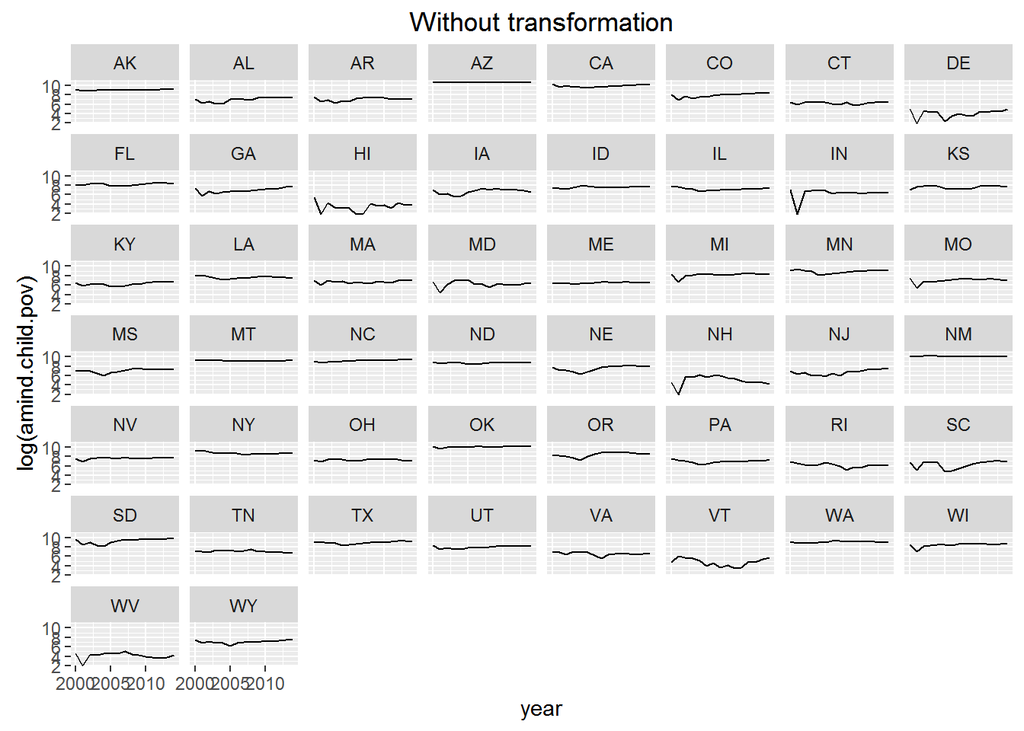

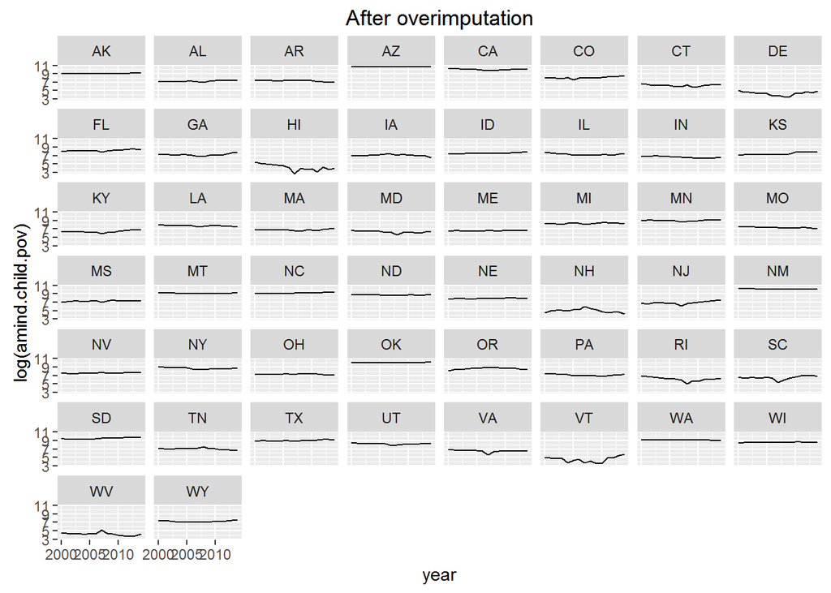

1. Multiple overimputation ((Blackwell et al 2015) for 2001-2006 ACS for states with fewer than 100,000 Black or Native American residents with prior expected value as weighted average of 1 year observation and variably weighted 2000 census and 2009 5-year ACS based on year of imputation.$w_{obs}=0.1$, $w_{2000}=0.75-0.12(year-2001)$, $w_{2009}=0.9-w_{2000}$. Prior variance is equal to the variance of all state observations 2000-2014 divided by the square root of the number of observations per state (15). N=750
2. Exclude observations prior to 2007, eliminating 1-year ACS data from the analysis, no imputation, reduced N=350
3. Drop all state-years with small Native American or African American populations (total population less than 10,000), N=517
4. Construct 3-year averages from 1-year ACS data for 2001-2006, drop 2001 observation. Multiple imputation with time-series priors for limited missingness, N=700

**12 relationships to test**

I examine 12 relationships between incarceration and foster care at the state-year level for each measurement strategy

1. Black foster care caseloads per capita ~ Black incarceration per capita (all)
2. Black foster care caseloads per capita ~ Black male incarceration per capita
3. Black foster care caseloads per capita ~ Black female incarceration per capita
4. Native American foster care caseloads per capita ~ Native American incarceration per capita (all)
5. Native American foster care caseloads per capita ~ Native American male incarceration per capita
6. Native American foster care caseloads per capita ~ Native American female incarceration per capita
7. Black foster care entries per capita ~ Black incarceration per capita (all)
8. Black foster care entries per capita ~ Black male incarceration per capita
9. Black foster care entries per capita ~ Black female incarceration per capita
10. Native American foster care entries per capita ~ Native American incarceration per capita (all)
11. Native American foster care entries per capita ~ Native American male incarceration per capita
12. Native American foster care entries per capita ~ Native American female incarceration per capita

All rates are modeled as either natural logs (if no zeroes are observed), or square roots if zeroes are observed.

*Four modeling strategies*

1. State fixed effects, Panel Corrected Standard Errors (Beck and Katz 1995)
2. State and year fixed effects, includes white incarceration, Panel Corrected Standard Errors (Beck and Katz 1995)
3. First difference
4. Lagged dependent variable (with 2 year lag DV), Panel Corrected Standard Errors (Beck and Katz 1995)

# Visualization of model results across error strategies and modeling strategies

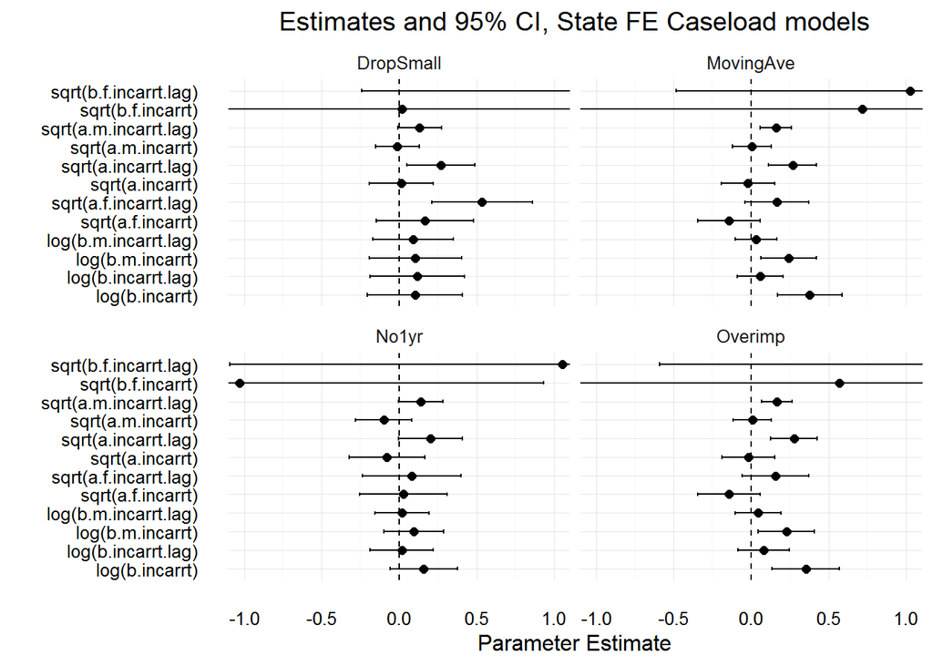

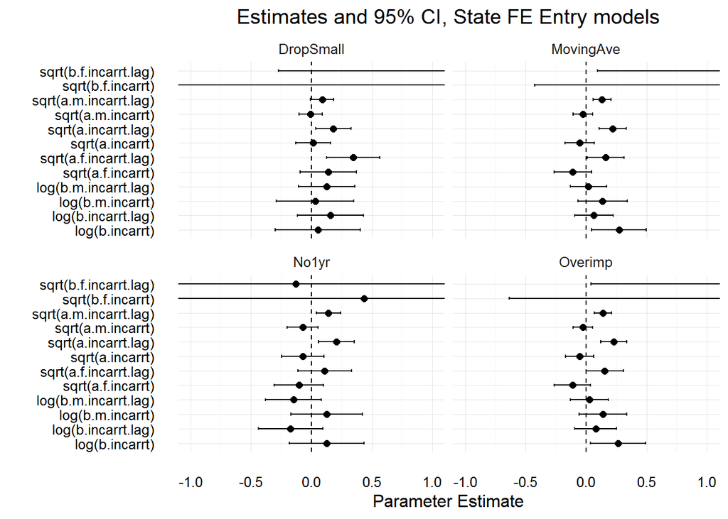

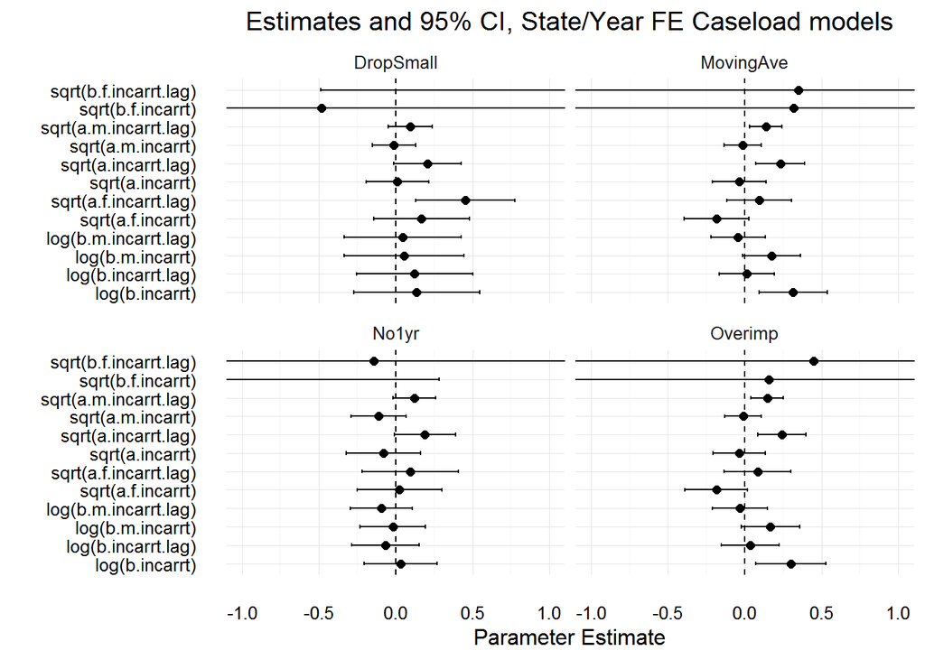

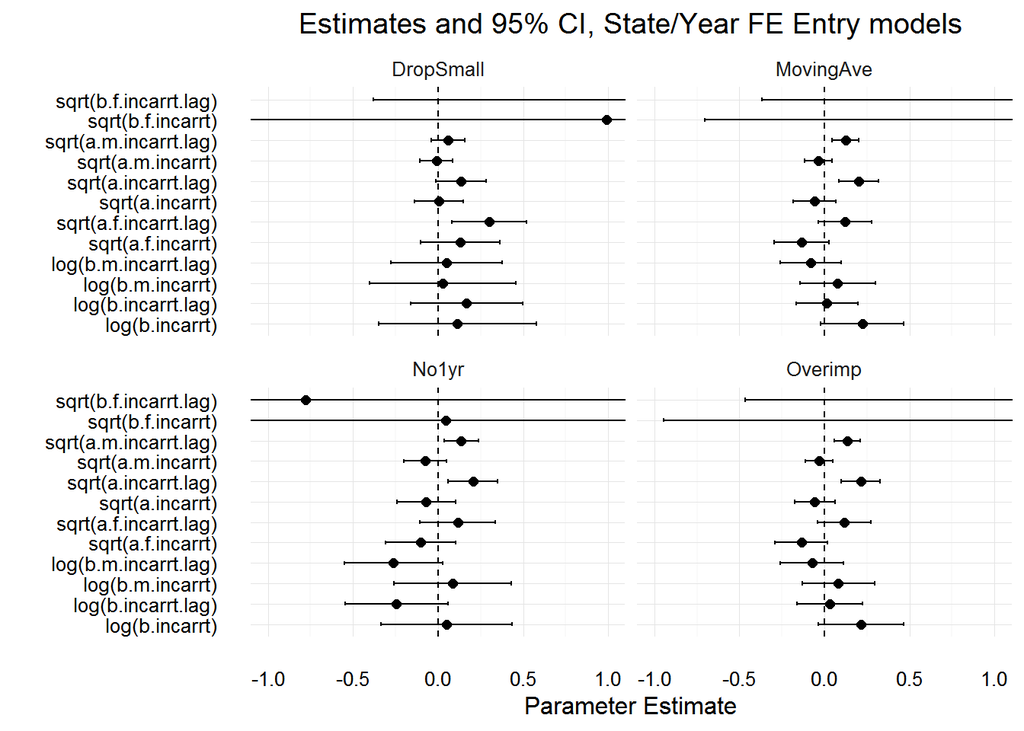

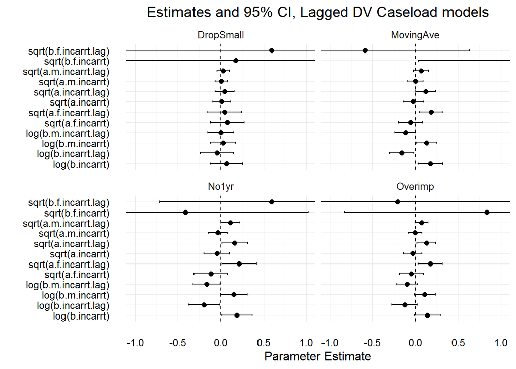

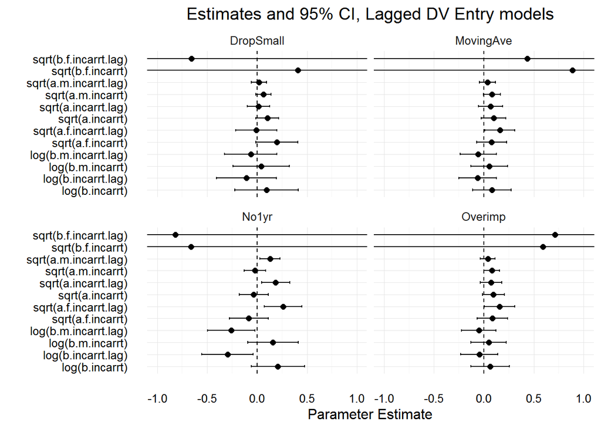

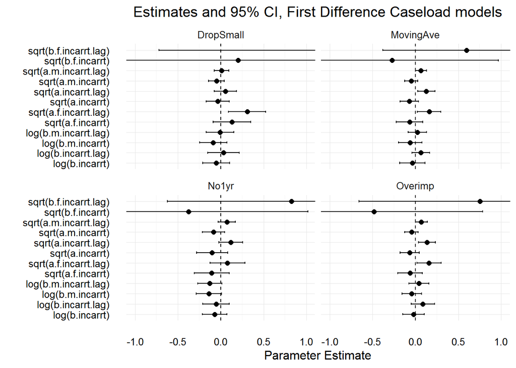

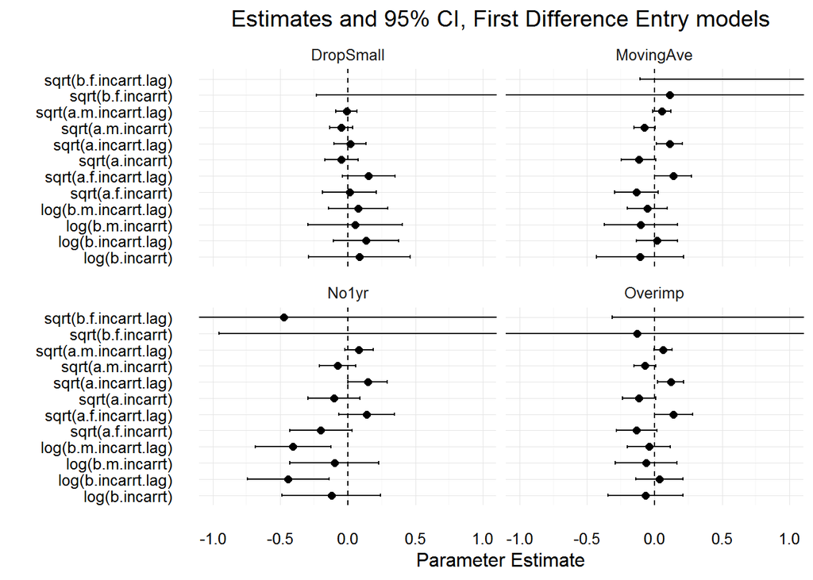

# Full model results, by error strategy

# Multiple Overimputation, 2000-2014

## Caseloads

Models of log(caseloads) by race for 2000 - 2014

### State Fixed Effects

Black FC Caseloads (logged), with State FE

|  | Beta | SE | z | p |
| --- | --- | --- | --- | --- |
| log(b.incarrt) | 0.35 | 0.11 | 3.18 | 0.00 |
| log(b.incarrt.lag) | 0.08 | 0.08 | 0.94 | 0.35 |
| log(b.unemp.rt) | -0.25 | 0.07 | -3.79 | 0.00 |
| log(b.singpar.rt) | 0.16 | 0.13 | 1.24 | 0.22 |
| log(blk.lessHS) | 0.00 | 0.08 | 0.01 | 0.99 |
| log(chpov.blk.pc) | 0.09 | 0.06 | 1.57 | 0.12 |
| log(pctblk) | -0.17 | 0.15 | -1.12 | 0.26 |
| inst6014_nom | -0.00 | 0.00 | -0.69 | 0.49 |
| log(v.crime.rt) | 0.21 | 0.12 | 1.76 | 0.08 |

Black FC Caseloads (logged), with State FE

|  | Beta | SE | z | p |
| --- | --- | --- | --- | --- |
| log(b.m.incarrt) | 0.23 | 0.09 | 2.46 | 0.01 |
| log(b.m.incarrt.lag) | 0.05 | 0.08 | 0.61 | 0.54 |
| log(b.unemp.rt) | -0.26 | 0.07 | -3.81 | 0.00 |
| log(b.singpar.rt) | 0.17 | 0.13 | 1.30 | 0.19 |
| log(blk.lessHS) | 0.00 | 0.08 | 0.02 | 0.98 |
| log(chpov.blk.pc) | 0.08 | 0.06 | 1.31 | 0.19 |
| log(pctblk) | -0.28 | 0.14 | -2.02 | 0.04 |
| inst6014_nom | -0.00 | 0.00 | -0.73 | 0.46 |
| log(v.crime.rt) | 0.25 | 0.12 | 2.11 | 0.04 |

Black FC Caseloads (logged), with State FE

|  | Beta | SE | z | p |
| --- | --- | --- | --- | --- |
| sqrt(b.f.incarrt) | 0.57 | 0.97 | 0.59 | 0.56 |
| sqrt(b.f.incarrt.lag) | 1.13 | 0.88 | 1.29 | 0.20 |
| log(b.unemp.rt) | -0.28 | 0.07 | -4.06 | 0.00 |
| log(b.singpar.rt) | 0.15 | 0.13 | 1.13 | 0.26 |
| log(blk.lessHS) | 0.04 | 0.08 | 0.56 | 0.57 |
| log(chpov.blk.pc) | 0.07 | 0.06 | 1.14 | 0.26 |
| log(pctblk) | -0.39 | 0.13 | -2.97 | 0.00 |
| inst6014_nom | -0.00 | 0.00 | -0.63 | 0.53 |
| log(v.crime.rt) | 0.31 | 0.12 | 2.59 | 0.01 |

Native American FC Caseloads (logged), with State FE

|  | Beta | SE | z | p |
| --- | --- | --- | --- | --- |
| sqrt(a.incarrt) | -0.02 | 0.09 | -0.21 | 0.83 |
| sqrt(a.incarrt.lag) | 0.28 | 0.08 | 3.60 | 0.00 |
| log(a.unemp.rt) | -0.01 | 0.01 | -1.33 | 0.18 |
| log(a.singpar.rt) | -0.01 | 0.01 | -0.80 | 0.42 |
| log(amind.lessHS) | -0.06 | 0.01 | -5.10 | 0.00 |
| sqrt(chpov.amind.pc) | -0.04 | 0.03 | -1.24 | 0.21 |
| log(pctami) | -0.02 | 0.01 | -1.93 | 0.05 |
| inst6014_nom | -0.00 | 0.00 | -1.10 | 0.27 |
| log(v.crime.rt) | -0.00 | 0.01 | -0.03 | 0.98 |

Native American Caseloads (logged), with State FE

|  | Beta | SE | z | p |
| --- | --- | --- | --- | --- |
| sqrt(a.m.incarrt) | 0.01 | 0.06 | 0.11 | 0.91 |
| sqrt(a.m.incarrt.lag) | 0.17 | 0.05 | 3.29 | 0.00 |
| log(a.unemp.rt) | -0.01 | 0.01 | -1.36 | 0.17 |
| log(a.singpar.rt) | -0.01 | 0.01 | -0.76 | 0.45 |
| log(amind.lessHS) | -0.06 | 0.01 | -5.25 | 0.00 |
| sqrt(chpov.amind.pc) | -0.04 | 0.03 | -1.21 | 0.23 |
| log(pctami) | -0.02 | 0.01 | -1.83 | 0.07 |
| inst6014_nom | -0.00 | 0.00 | -1.08 | 0.28 |
| log(v.crime.rt) | 0.00 | 0.01 | 0.03 | 0.98 |

Native American Caseloads (logged), with State FE

|  | Beta | SE | z | p |
| --- | --- | --- | --- | --- |
| sqrt(a.f.incarrt) | -0.14 | 0.10 | -1.40 | 0.16 |
| sqrt(a.f.incarrt.lag) | 0.16 | 0.11 | 1.42 | 0.15 |
| log(a.unemp.rt) | -0.01 | 0.01 | -1.35 | 0.18 |
| log(a.singpar.rt) | -0.01 | 0.01 | -0.74 | 0.46 |
| log(amind.lessHS) | -0.06 | 0.01 | -4.99 | 0.00 |
| sqrt(chpov.amind.pc) | -0.04 | 0.03 | -1.30 | 0.20 |
| log(pctami) | -0.03 | 0.01 | -2.43 | 0.01 |
| inst6014_nom | -0.00 | 0.00 | -0.98 | 0.33 |
| log(v.crime.rt) | -0.00 | 0.01 | -0.11 | 0.91 |

### State and year fixed effects

Black FC Caseloads (logged), with State & Year FE

|  | Beta | SE | z | p |
| --- | --- | --- | --- | --- |
| log(b.incarrt) | 0.30 | 0.12 | 2.56 | 0.01 |
| log(b.incarrt.lag) | 0.04 | 0.10 | 0.37 | 0.71 |
| log(w.incarrt) | -0.15 | 0.19 | -0.78 | 0.43 |
| log(b.unemp.rt) | -0.21 | 0.07 | -3.04 | 0.00 |
| log(b.singpar.rt) | 0.14 | 0.13 | 1.13 | 0.26 |
| log(blk.lessHS) | -0.01 | 0.07 | -0.18 | 0.85 |
| log(chpov.blk.pc) | 0.12 | 0.06 | 2.06 | 0.04 |
| log(pctblk) | -0.12 | 0.16 | -0.76 | 0.45 |
| inst6014_nom | -0.00 | 0.00 | -1.46 | 0.14 |
| log(v.crime.rt) | 0.16 | 0.12 | 1.37 | 0.17 |

Black FC Caseloads (logged), with State & Year FE

|  | Beta | SE | z | p |
| --- | --- | --- | --- | --- |
| log(b.m.incarrt) | 0.17 | 0.10 | 1.72 | 0.09 |
| log(b.m.incarrt.lag) | -0.03 | 0.09 | -0.33 | 0.74 |
| log(w.incarrt) | -0.07 | 0.19 | -0.37 | 0.71 |
| log(b.unemp.rt) | -0.21 | 0.07 | -2.95 | 0.00 |
| log(b.singpar.rt) | 0.14 | 0.12 | 1.12 | 0.26 |
| log(blk.lessHS) | -0.01 | 0.08 | -0.18 | 0.86 |
| log(chpov.blk.pc) | 0.11 | 0.06 | 1.92 | 0.06 |
| log(pctblk) | -0.21 | 0.15 | -1.45 | 0.15 |
| inst6014_nom | -0.00 | 0.00 | -1.55 | 0.12 |
| log(v.crime.rt) | 0.20 | 0.12 | 1.65 | 0.10 |

Black FC Caseloads (logged), with State & Year FE

|  | Beta | SE | z | p |
| --- | --- | --- | --- | --- |
| sqrt(b.f.incarrt) | 0.16 | 0.97 | 0.16 | 0.87 |
| sqrt(b.f.incarrt.lag) | 0.45 | 0.88 | 0.51 | 0.61 |
| log(w.incarrt) | -0.05 | 0.19 | -0.24 | 0.81 |
| log(b.unemp.rt) | -0.21 | 0.07 | -2.97 | 0.00 |
| log(b.singpar.rt) | 0.13 | 0.13 | 1.01 | 0.31 |
| log(blk.lessHS) | -0.00 | 0.08 | -0.01 | 0.99 |
| log(chpov.blk.pc) | 0.11 | 0.06 | 1.87 | 0.06 |
| log(pctblk) | -0.26 | 0.15 | -1.78 | 0.07 |
| inst6014_nom | -0.00 | 0.00 | -1.53 | 0.13 |
| log(v.crime.rt) | 0.22 | 0.12 | 1.80 | 0.07 |

Native American FC Caseloads (logged), with State & Year FE

|  | Beta | SE | z | p |
| --- | --- | --- | --- | --- |
| sqrt(a.incarrt) | -0.04 | 0.09 | -0.41 | 0.68 |
| sqrt(a.incarrt.lag) | 0.24 | 0.08 | 3.05 | 0.00 |
| log(w.incarrt) | -0.02 | 0.02 | -0.91 | 0.36 |
| log(a.unemp.rt) | 0.00 | 0.01 | 0.12 | 0.91 |
| log(a.singpar.rt) | -0.01 | 0.01 | -0.66 | 0.51 |
| log(amind.lessHS) | -0.06 | 0.01 | -4.68 | 0.00 |
| sqrt(chpov.amind.pc) | -0.02 | 0.03 | -0.77 | 0.44 |
| log(pctami) | -0.02 | 0.01 | -1.79 | 0.07 |
| inst6014_nom | -0.00 | 0.00 | -1.87 | 0.06 |
| log(v.crime.rt) | -0.00 | 0.01 | -0.37 | 0.71 |

Native American Caseloads (logged), with State & Year FE

|  | Beta | SE | z | p |
| --- | --- | --- | --- | --- |
| sqrt(a.m.incarrt) | -0.01 | 0.06 | -0.18 | 0.86 |
| sqrt(a.m.incarrt.lag) | 0.15 | 0.05 | 2.74 | 0.01 |
| log(w.incarrt) | -0.02 | 0.02 | -0.90 | 0.37 |
| log(a.unemp.rt) | 0.00 | 0.01 | 0.08 | 0.94 |
| log(a.singpar.rt) | -0.01 | 0.01 | -0.64 | 0.52 |
| log(amind.lessHS) | -0.07 | 0.01 | -4.73 | 0.00 |
| sqrt(chpov.amind.pc) | -0.02 | 0.03 | -0.74 | 0.46 |
| log(pctami) | -0.02 | 0.01 | -1.79 | 0.07 |
| inst6014_nom | -0.00 | 0.00 | -1.84 | 0.06 |
| log(v.crime.rt) | -0.00 | 0.01 | -0.31 | 0.75 |

Native American Caseloads (logged), with State & Year FE

|  | Beta | SE | z | p |
| --- | --- | --- | --- | --- |
| sqrt(a.f.incarrt) | -0.18 | 0.10 | -1.77 | 0.08 |
| sqrt(a.f.incarrt.lag) | 0.08 | 0.11 | 0.76 | 0.44 |
| log(w.incarrt) | -0.01 | 0.02 | -0.59 | 0.55 |
| log(a.unemp.rt) | 0.00 | 0.01 | 0.07 | 0.94 |
| log(a.singpar.rt) | -0.01 | 0.01 | -0.60 | 0.55 |
| log(amind.lessHS) | -0.06 | 0.01 | -4.53 | 0.00 |
| sqrt(chpov.amind.pc) | -0.02 | 0.03 | -0.74 | 0.46 |
| log(pctami) | -0.03 | 0.01 | -2.45 | 0.01 |
| inst6014_nom | -0.00 | 0.00 | -1.81 | 0.07 |
| log(v.crime.rt) | -0.00 | 0.01 | -0.38 | 0.70 |

### First difference

Black FC Caseloads (logged), first difference

|  | Beta | SE | z | p |
| --- | --- | --- | --- | --- |
| (intercept) | -0.01 | 0.01 | -1.39 | 0.16 |
| log(b.incarrt) | -0.02 | 0.06 | -0.32 | 0.75 |
| log(b.incarrt.lag) | 0.09 | 0.07 | 1.26 | 0.21 |
| log(b.unemp.rt) | -0.09 | 0.04 | -2.36 | 0.02 |
| log(b.singpar.rt) | 0.13 | 0.06 | 1.99 | 0.05 |
| log(blk.lessHS) | -0.07 | 0.04 | -1.49 | 0.14 |
| log(chpov.blk.pc) | 0.13 | 0.04 | 3.06 | 0.00 |
| log(pctblk) | -0.54 | 0.10 | -5.61 | 0.00 |
| inst6014_nom | 0.00 | 0.00 | 1.24 | 0.21 |
| log(v.crime.rt) | 0.12 | 0.07 | 1.72 | 0.09 |

Black FC Caseloads (logged), first difference

|  | Beta | SE | z | p |
| --- | --- | --- | --- | --- |
| (intercept) | -0.01 | 0.01 | -1.61 | 0.11 |
| log(b.m.incarrt) | -0.04 | 0.06 | -0.76 | 0.45 |
| log(b.m.incarrt.lag) | 0.04 | 0.06 | 0.65 | 0.52 |
| log(b.unemp.rt) | -0.10 | 0.04 | -2.55 | 0.01 |
| log(b.singpar.rt) | 0.14 | 0.07 | 2.05 | 0.04 |
| log(blk.lessHS) | -0.06 | 0.04 | -1.41 | 0.16 |
| log(chpov.blk.pc) | 0.13 | 0.04 | 3.07 | 0.00 |
| log(pctblk) | -0.53 | 0.10 | -5.46 | 0.00 |
| inst6014_nom | 0.00 | 0.00 | 1.22 | 0.22 |
| log(v.crime.rt) | 0.12 | 0.07 | 1.78 | 0.07 |

Black FC Caseloads (logged), first difference

|  | Beta | SE | z | p |
| --- | --- | --- | --- | --- |
| (intercept) | -0.01 | 0.01 | -1.53 | 0.13 |
| sqrt(b.f.incarrt) | -0.49 | 0.65 | -0.75 | 0.45 |
| sqrt(b.f.incarrt.lag) | 0.75 | 0.72 | 1.05 | 0.29 |
| log(b.unemp.rt) | -0.09 | 0.04 | -2.41 | 0.02 |
| log(b.singpar.rt) | 0.13 | 0.07 | 1.90 | 0.06 |
| log(blk.lessHS) | -0.07 | 0.04 | -1.60 | 0.11 |
| log(chpov.blk.pc) | 0.12 | 0.04 | 2.92 | 0.00 |
| log(pctblk) | -0.56 | 0.09 | -6.17 | 0.00 |
| inst6014_nom | 0.00 | 0.00 | 1.20 | 0.23 |
| log(v.crime.rt) | 0.12 | 0.07 | 1.78 | 0.07 |

Native American FC Caseloads (logged), first difference

|  | Beta | SE | z | p |
| --- | --- | --- | --- | --- |
| (intercept) | 0.00 | 0.00 | 1.76 | 0.08 |
| sqrt(a.incarrt) | -0.07 | 0.06 | -1.20 | 0.23 |
| sqrt(a.incarrt.lag) | 0.13 | 0.05 | 2.65 | 0.01 |
| log(a.unemp.rt) | -0.01 | 0.00 | -1.97 | 0.05 |
| log(a.singpar.rt) | -0.00 | 0.01 | -0.10 | 0.92 |
| log(amind.lessHS) | -0.01 | 0.01 | -0.73 | 0.47 |
| sqrt(chpov.amind.pc) | 0.07 | 0.02 | 3.05 | 0.00 |
| log(pctami) | -0.03 | 0.01 | -3.89 | 0.00 |
| inst6014_nom | -0.00 | 0.00 | -1.13 | 0.26 |
| log(v.crime.rt) | 0.01 | 0.01 | 1.34 | 0.18 |

Native American Caseloads (logged), first difference

|  | Beta | SE | z | p |
| --- | --- | --- | --- | --- |
| (intercept) | 0.00 | 0.00 | 1.77 | 0.08 |
| sqrt(a.m.incarrt) | -0.05 | 0.04 | -1.15 | 0.25 |
| sqrt(a.m.incarrt.lag) | 0.07 | 0.03 | 1.99 | 0.05 |
| log(a.unemp.rt) | -0.01 | 0.00 | -2.01 | 0.04 |
| log(a.singpar.rt) | -0.00 | 0.01 | -0.08 | 0.94 |
| log(amind.lessHS) | -0.01 | 0.01 | -0.76 | 0.45 |
| sqrt(chpov.amind.pc) | 0.07 | 0.02 | 3.01 | 0.00 |
| log(pctami) | -0.03 | 0.01 | -3.95 | 0.00 |
| inst6014_nom | -0.00 | 0.00 | -1.05 | 0.29 |
| log(v.crime.rt) | 0.01 | 0.01 | 1.33 | 0.18 |

Native American Caseloads (logged), first difference

|  | Beta | SE | z | p |
| --- | --- | --- | --- | --- |
| (intercept) | 0.00 | 0.00 | 1.58 | 0.11 |
| sqrt(a.f.incarrt) | -0.06 | 0.07 | -0.85 | 0.40 |
| sqrt(a.f.incarrt.lag) | 0.16 | 0.07 | 2.23 | 0.03 |
| log(a.unemp.rt) | -0.01 | 0.00 | -2.02 | 0.04 |
| log(a.singpar.rt) | -0.00 | 0.01 | -0.21 | 0.84 |
| log(amind.lessHS) | -0.01 | 0.01 | -0.78 | 0.43 |
| sqrt(chpov.amind.pc) | 0.07 | 0.02 | 3.24 | 0.00 |
| log(pctami) | -0.03 | 0.01 | -3.18 | 0.00 |
| inst6014_nom | -0.00 | 0.00 | -1.12 | 0.26 |
| log(v.crime.rt) | 0.01 | 0.01 | 1.18 | 0.24 |

### Lagged DV

Black FC Caseloads (logged), lagged DV

|  | Beta | SE | z | p |
| --- | --- | --- | --- | --- |
| (Intercept) | -0.64 | 0.13 | -4.93 | 0.00 |
| log(b.incarrt) | 0.14 | 0.08 | 1.80 | 0.07 |
| log(b.incarrt.lag) | -0.13 | 0.08 | -1.65 | 0.10 |
| log(b.unemp.rt) | -0.05 | 0.02 | -1.92 | 0.06 |
| log(b.singpar.rt) | 0.10 | 0.04 | 2.24 | 0.02 |
| log(blk.lessHS) | -0.08 | 0.02 | -3.51 | 0.00 |
| log(chpov.blk.pc) | 0.07 | 0.03 | 2.62 | 0.01 |
| log(pctblk) | -0.04 | 0.01 | -4.45 | 0.00 |
| inst6014_nom | -0.00 | 0.00 | -0.01 | 0.99 |
| log(v.crime.rt) | 0.03 | 0.01 | 2.48 | 0.01 |
| log(clrt.blk.lag) | 0.95 | 0.05 | 19.49 | 0.00 |
| log(clrt.blk.lag2) | -0.02 | 0.05 | -0.39 | 0.69 |

Black FC Caseloads (logged), lagged DV

|  | Beta | SE | z | p |
| --- | --- | --- | --- | --- |
| (Intercept) | -0.65 | 0.12 | -5.28 | 0.00 |
| log(b.m.incarrt) | 0.11 | 0.06 | 1.75 | 0.08 |
| log(b.m.incarrt.lag) | -0.10 | 0.06 | -1.54 | 0.12 |
| log(b.unemp.rt) | -0.05 | 0.02 | -1.94 | 0.05 |
| log(b.singpar.rt) | 0.10 | 0.04 | 2.18 | 0.03 |
| log(blk.lessHS) | -0.08 | 0.02 | -3.52 | 0.00 |
| log(chpov.blk.pc) | 0.07 | 0.03 | 2.65 | 0.01 |
| log(pctblk) | -0.04 | 0.01 | -4.64 | 0.00 |
| inst6014_nom | -0.00 | 0.00 | -0.03 | 0.98 |
| log(v.crime.rt) | 0.03 | 0.01 | 2.49 | 0.01 |
| log(clrt.blk.lag) | 0.95 | 0.05 | 19.44 | 0.00 |
| log(clrt.blk.lag2) | -0.02 | 0.05 | -0.39 | 0.70 |

Black FC Caseloads (logged), lagged DV

|  | Beta | SE | z | p |
| --- | --- | --- | --- | --- |
| (Intercept) | -0.67 | 0.12 | -5.79 | 0.00 |
| sqrt(b.f.incarrt) | 0.83 | 0.85 | 0.98 | 0.33 |
| sqrt(b.f.incarrt.lag) | -0.21 | 0.82 | -0.26 | 0.80 |
| log(b.unemp.rt) | -0.04 | 0.02 | -1.76 | 0.08 |
| log(b.singpar.rt) | 0.09 | 0.04 | 2.16 | 0.03 |
| log(blk.lessHS) | -0.08 | 0.02 | -3.48 | 0.00 |
| log(chpov.blk.pc) | 0.07 | 0.03 | 2.73 | 0.01 |
| log(pctblk) | -0.04 | 0.01 | -4.05 | 0.00 |
| inst6014_nom | 0.00 | 0.00 | 0.25 | 0.81 |
| log(v.crime.rt) | 0.03 | 0.01 | 2.08 | 0.04 |
| log(clrt.blk.lag) | 0.95 | 0.05 | 19.15 | 0.00 |
| log(clrt.blk.lag2) | -0.02 | 0.05 | -0.39 | 0.70 |

Native American FC Caseloads (logged), lagged DV

|  | Beta | SE | z | p |
| --- | --- | --- | --- | --- |
| (Intercept) | -0.07 | 0.02 | -3.20 | 0.00 |
| sqrt(a.incarrt) | -0.03 | 0.06 | -0.54 | 0.59 |
| sqrt(a.incarrt.lag) | 0.13 | 0.06 | 2.32 | 0.02 |
| log(a.unemp.rt) | -0.00 | 0.00 | -1.35 | 0.18 |
| log(a.singpar.rt) | 0.00 | 0.00 | 0.27 | 0.79 |
| log(amind.lessHS) | -0.01 | 0.00 | -2.38 | 0.02 |
| sqrt(chpov.amind.pc) | 0.03 | 0.01 | 2.90 | 0.00 |
| log(pctami) | -0.00 | 0.00 | -3.07 | 0.00 |
| inst6014_nom | 0.00 | 0.00 | 1.07 | 0.28 |
| log(v.crime.rt) | 0.00 | 0.00 | 1.52 | 0.13 |
| sqrt(clrt.nat.am.lag) | 0.92 | 0.05 | 19.96 | 0.00 |
| sqrt(clrt.nat.am.lag2) | 0.04 | 0.05 | 0.78 | 0.44 |

Native American Caseloads (logged), lagged DV

|  | Beta | SE | z | p |
| --- | --- | --- | --- | --- |
| (Intercept) | -0.07 | 0.02 | -3.22 | 0.00 |
| sqrt(a.m.incarrt) | -0.00 | 0.04 | -0.11 | 0.91 |
| sqrt(a.m.incarrt.lag) | 0.07 | 0.04 | 1.79 | 0.07 |
| log(a.unemp.rt) | -0.00 | 0.00 | -1.40 | 0.16 |
| log(a.singpar.rt) | 0.00 | 0.00 | 0.27 | 0.79 |
| log(amind.lessHS) | -0.01 | 0.00 | -2.51 | 0.01 |
| sqrt(chpov.amind.pc) | 0.04 | 0.01 | 3.00 | 0.00 |
| log(pctami) | -0.00 | 0.00 | -3.03 | 0.00 |
| inst6014_nom | 0.00 | 0.00 | 1.00 | 0.32 |
| log(v.crime.rt) | 0.00 | 0.00 | 1.56 | 0.12 |
| sqrt(clrt.nat.am.lag) | 0.92 | 0.05 | 19.89 | 0.00 |
| sqrt(clrt.nat.am.lag2) | 0.04 | 0.05 | 0.81 | 0.42 |

Native American Caseloads (logged), lagged DV

|  | Beta | SE | z | p |
| --- | --- | --- | --- | --- |
| (Intercept) | -0.05 | 0.02 | -2.60 | 0.01 |
| sqrt(a.f.incarrt) | -0.05 | 0.07 | -0.67 | 0.50 |
| sqrt(a.f.incarrt.lag) | 0.17 | 0.07 | 2.41 | 0.02 |
| log(a.unemp.rt) | -0.00 | 0.00 | -0.92 | 0.36 |
| log(a.singpar.rt) | 0.00 | 0.00 | 0.38 | 0.70 |
| log(amind.lessHS) | -0.01 | 0.00 | -2.31 | 0.02 |
| sqrt(chpov.amind.pc) | 0.03 | 0.01 | 2.74 | 0.01 |
| log(pctami) | -0.00 | 0.00 | -2.70 | 0.01 |
| inst6014_nom | 0.00 | 0.00 | 1.19 | 0.23 |
| log(v.crime.rt) | 0.00 | 0.00 | 0.92 | 0.36 |
| sqrt(clrt.nat.am.lag) | 0.93 | 0.05 | 20.23 | 0.00 |
| sqrt(clrt.nat.am.lag2) | 0.03 | 0.05 | 0.62 | 0.53 |

## Entries

Models of foster care entries (logged) by race

### State Fixed Effects

Black FC Entries (logged), with State FE

|  | Beta | SE | z | p |
| --- | --- | --- | --- | --- |
| log(b.incarrt) | 0.26 | 0.12 | 2.25 | 0.02 |
| log(b.incarrt.lag) | 0.08 | 0.09 | 0.91 | 0.36 |
| log(b.unemp.rt) | -0.24 | 0.07 | -3.63 | 0.00 |
| log(b.singpar.rt) | 0.12 | 0.14 | 0.88 | 0.38 |
| log(blk.lessHS) | -0.11 | 0.08 | -1.36 | 0.17 |
| log(chpov.blk.pc) | 0.12 | 0.06 | 1.79 | 0.07 |
| log(pctblk) | -0.24 | 0.15 | -1.64 | 0.10 |
| inst6014_nom | -0.00 | 0.00 | -0.85 | 0.40 |
| log(v.crime.rt) | 0.21 | 0.11 | 1.84 | 0.07 |

Black FC Entries (logged), with State FE

|  | Beta | SE | z | p |
| --- | --- | --- | --- | --- |
| log(b.m.incarrt) | 0.14 | 0.10 | 1.39 | 0.16 |
| log(b.m.incarrt.lag) | 0.03 | 0.08 | 0.32 | 0.75 |
| log(b.unemp.rt) | -0.25 | 0.07 | -3.71 | 0.00 |
| log(b.singpar.rt) | 0.13 | 0.14 | 0.93 | 0.35 |
| log(blk.lessHS) | -0.10 | 0.08 | -1.21 | 0.23 |
| log(chpov.blk.pc) | 0.10 | 0.06 | 1.57 | 0.12 |
| log(pctblk) | -0.36 | 0.14 | -2.61 | 0.01 |
| inst6014_nom | -0.00 | 0.00 | -0.87 | 0.38 |
| log(v.crime.rt) | 0.26 | 0.12 | 2.24 | 0.02 |

Black FC Entries (logged), with State FE

|  | Beta | SE | z | p |
| --- | --- | --- | --- | --- |
| sqrt(b.f.incarrt) | 1.47 | 1.08 | 1.37 | 0.17 |
| sqrt(b.f.incarrt.lag) | 1.76 | 0.88 | 2.00 | 0.04 |
| log(b.unemp.rt) | -0.26 | 0.07 | -3.93 | 0.00 |
| log(b.singpar.rt) | 0.11 | 0.14 | 0.74 | 0.46 |
| log(blk.lessHS) | -0.09 | 0.08 | -1.09 | 0.28 |
| log(chpov.blk.pc) | 0.11 | 0.07 | 1.63 | 0.10 |
| log(pctblk) | -0.34 | 0.12 | -2.74 | 0.01 |
| inst6014_nom | -0.00 | 0.00 | -0.76 | 0.45 |
| log(v.crime.rt) | 0.26 | 0.11 | 2.37 | 0.02 |

Native American FC Entries (logged), with State FE

|  | Beta | SE | z | p |
| --- | --- | --- | --- | --- |
| sqrt(a.incarrt) | -0.05 | 0.06 | -0.87 | 0.38 |
| sqrt(a.incarrt.lag) | 0.23 | 0.05 | 4.15 | 0.00 |
| log(a.unemp.rt) | -0.01 | 0.00 | -2.68 | 0.01 |
| log(a.singpar.rt) | -0.00 | 0.01 | -0.03 | 0.97 |
| log(amind.lessHS) | -0.03 | 0.01 | -3.68 | 0.00 |
| sqrt(chpov.amind.pc) | 0.01 | 0.02 | 0.70 | 0.48 |
| log(pctami) | -0.03 | 0.01 | -3.79 | 0.00 |
| inst6014_nom | -0.00 | 0.00 | -1.47 | 0.14 |
| log(v.crime.rt) | -0.00 | 0.01 | -0.31 | 0.76 |

|  | Beta | SE | z | p |
| --- | --- | --- | --- | --- |
| sqrt(a.m.incarrt) | -0.03 | 0.04 | -0.62 | 0.53 |
| sqrt(a.m.incarrt.lag) | 0.14 | 0.04 | 3.81 | 0.00 |
| log(a.unemp.rt) | -0.01 | 0.00 | -2.71 | 0.01 |
| log(a.singpar.rt) | 0.00 | 0.01 | 0.02 | 0.98 |
| log(amind.lessHS) | -0.03 | 0.01 | -3.83 | 0.00 |
| sqrt(chpov.amind.pc) | 0.02 | 0.02 | 0.74 | 0.46 |
| log(pctami) | -0.03 | 0.01 | -3.71 | 0.00 |
| inst6014_nom | -0.00 | 0.00 | -1.44 | 0.15 |
| log(v.crime.rt) | -0.00 | 0.01 | -0.26 | 0.80 |

|  | Beta | SE | z | p |
| --- | --- | --- | --- | --- |
| sqrt(a.f.incarrt) | -0.11 | 0.08 | -1.49 | 0.14 |
| sqrt(a.f.incarrt.lag) | 0.15 | 0.08 | 1.95 | 0.05 |
| log(a.unemp.rt) | -0.01 | 0.00 | -2.67 | 0.01 |
| log(a.singpar.rt) | -0.00 | 0.01 | -0.04 | 0.97 |
| log(amind.lessHS) | -0.03 | 0.01 | -3.58 | 0.00 |
| sqrt(chpov.amind.pc) | 0.01 | 0.02 | 0.60 | 0.55 |
| log(pctami) | -0.03 | 0.01 | -4.18 | 0.00 |
| inst6014_nom | -0.00 | 0.00 | -1.32 | 0.19 |
| log(v.crime.rt) | -0.00 | 0.01 | -0.41 | 0.68 |

### State and year fixed effects

Black FC Entries (logged), with State & Year FE

|  | Beta | SE | z | p |
| --- | --- | --- | --- | --- |
| log(b.incarrt) | 0.22 | 0.13 | 1.69 | 0.09 |
| log(b.incarrt.lag) | 0.03 | 0.10 | 0.31 | 0.76 |
| log(w.incarrt) | -0.04 | 0.19 | -0.21 | 0.83 |
| log(b.unemp.rt) | -0.22 | 0.07 | -3.10 | 0.00 |
| log(b.singpar.rt) | 0.11 | 0.14 | 0.81 | 0.42 |
| log(blk.lessHS) | -0.08 | 0.08 | -1.03 | 0.30 |
| log(chpov.blk.pc) | 0.13 | 0.06 | 2.07 | 0.04 |
| log(pctblk) | -0.23 | 0.16 | -1.51 | 0.13 |
| inst6014_nom | -0.00 | 0.00 | -1.31 | 0.19 |
| log(v.crime.rt) | 0.17 | 0.12 | 1.45 | 0.15 |

Black FC Entries (logged), with State & Year FE

|  | Beta | SE | z | p |
| --- | --- | --- | --- | --- |
| log(b.m.incarrt) | 0.08 | 0.11 | 0.75 | 0.45 |
| log(b.m.incarrt.lag) | -0.07 | 0.09 | -0.77 | 0.44 |
| log(w.incarrt) | 0.04 | 0.19 | 0.23 | 0.81 |
| log(b.unemp.rt) | -0.22 | 0.07 | -3.06 | 0.00 |
| log(b.singpar.rt) | 0.11 | 0.14 | 0.79 | 0.43 |
| log(blk.lessHS) | -0.08 | 0.08 | -1.01 | 0.31 |
| log(chpov.blk.pc) | 0.13 | 0.06 | 1.99 | 0.05 |
| log(pctblk) | -0.32 | 0.14 | -2.18 | 0.03 |
| inst6014_nom | -0.00 | 0.00 | -1.41 | 0.16 |
| log(v.crime.rt) | 0.21 | 0.12 | 1.78 | 0.08 |

Black FC Entries (logged), with State & Year FE

|  | Beta | SE | z | p |
| --- | --- | --- | --- | --- |
| sqrt(b.f.incarrt) | 1.20 | 1.09 | 1.10 | 0.27 |
| sqrt(b.f.incarrt.lag) | 1.30 | 0.90 | 1.44 | 0.15 |
| log(w.incarrt) | -0.02 | 0.19 | -0.08 | 0.94 |
| log(b.unemp.rt) | -0.23 | 0.07 | -3.19 | 0.00 |
| log(b.singpar.rt) | 0.09 | 0.14 | 0.67 | 0.51 |
| log(blk.lessHS) | -0.08 | 0.08 | -0.93 | 0.35 |
| log(chpov.blk.pc) | 0.13 | 0.07 | 2.00 | 0.04 |
| log(pctblk) | -0.29 | 0.14 | -2.01 | 0.04 |
| inst6014_nom | -0.00 | 0.00 | -1.27 | 0.20 |
| log(v.crime.rt) | 0.19 | 0.12 | 1.68 | 0.09 |

Native American FC Entries (logged), with State & Year FE

|  | Beta | SE | z | p |
| --- | --- | --- | --- | --- |
| sqrt(a.incarrt) | -0.06 | 0.06 | -0.95 | 0.34 |
| sqrt(a.incarrt.lag) | 0.21 | 0.06 | 3.69 | 0.00 |
| log(w.incarrt) | -0.01 | 0.01 | -0.89 | 0.37 |
| log(a.unemp.rt) | -0.01 | 0.00 | -1.73 | 0.08 |
| log(a.singpar.rt) | 0.00 | 0.01 | 0.12 | 0.90 |
| log(amind.lessHS) | -0.03 | 0.01 | -3.56 | 0.00 |
| sqrt(chpov.amind.pc) | 0.02 | 0.02 | 0.97 | 0.33 |
| log(pctami) | -0.03 | 0.01 | -3.17 | 0.00 |
| inst6014_nom | -0.00 | 0.00 | -1.84 | 0.06 |
| log(v.crime.rt) | -0.00 | 0.01 | -0.58 | 0.56 |

|  | Beta | SE | z | p |
| --- | --- | --- | --- | --- |
| sqrt(a.m.incarrt) | -0.03 | 0.04 | -0.79 | 0.43 |
| sqrt(a.m.incarrt.lag) | 0.13 | 0.04 | 3.41 | 0.00 |
| log(w.incarrt) | -0.01 | 0.01 | -0.89 | 0.37 |
| log(a.unemp.rt) | -0.01 | 0.00 | -1.77 | 0.08 |
| log(a.singpar.rt) | 0.00 | 0.01 | 0.14 | 0.88 |
| log(amind.lessHS) | -0.03 | 0.01 | -3.62 | 0.00 |
| sqrt(chpov.amind.pc) | 0.02 | 0.02 | 1.00 | 0.32 |
| log(pctami) | -0.03 | 0.01 | -3.19 | 0.00 |
| inst6014_nom | -0.00 | 0.00 | -1.81 | 0.07 |
| log(v.crime.rt) | -0.00 | 0.01 | -0.52 | 0.60 |

|  | Beta | SE | z | p |
| --- | --- | --- | --- | --- |
| sqrt(a.f.incarrt) | -0.14 | 0.08 | -1.71 | 0.09 |
| sqrt(a.f.incarrt.lag) | 0.12 | 0.08 | 1.44 | 0.15 |
| log(w.incarrt) | -0.01 | 0.01 | -0.58 | 0.56 |
| log(a.unemp.rt) | -0.01 | 0.00 | -1.72 | 0.09 |
| log(a.singpar.rt) | 0.00 | 0.01 | 0.14 | 0.89 |
| log(amind.lessHS) | -0.03 | 0.01 | -3.43 | 0.00 |
| sqrt(chpov.amind.pc) | 0.02 | 0.02 | 0.95 | 0.34 |
| log(pctami) | -0.03 | 0.01 | -3.73 | 0.00 |
| inst6014_nom | -0.00 | 0.00 | -1.77 | 0.08 |
| log(v.crime.rt) | -0.01 | 0.01 | -0.64 | 0.52 |

### First difference

Black FC Entries (logged), first difference

|  | Beta | SE | z | p |
| --- | --- | --- | --- | --- |
| (intercept) | -0.00 | 0.01 | -0.14 | 0.89 |
| log(b.incarrt) | -0.07 | 0.14 | -0.47 | 0.64 |
| log(b.incarrt.lag) | 0.04 | 0.09 | 0.40 | 0.69 |
| log(b.unemp.rt) | -0.14 | 0.05 | -2.74 | 0.01 |
| log(b.singpar.rt) | 0.10 | 0.13 | 0.79 | 0.43 |
| log(blk.lessHS) | -0.18 | 0.06 | -2.79 | 0.00 |
| log(chpov.blk.pc) | 0.11 | 0.06 | 1.84 | 0.06 |
| log(pctblk) | -0.63 | 0.18 | -3.56 | 0.00 |
| inst6014_nom | 0.00 | 0.00 | 0.97 | 0.33 |
| log(v.crime.rt) | 0.15 | 0.11 | 1.33 | 0.18 |

Black FC Entries (logged), first difference

|  | Beta | SE | z | p |
| --- | --- | --- | --- | --- |
| (intercept) | -0.00 | 0.01 | -0.31 | 0.76 |
| log(b.m.incarrt) | -0.06 | 0.12 | -0.54 | 0.59 |
| log(b.m.incarrt.lag) | -0.04 | 0.08 | -0.52 | 0.60 |
| log(b.unemp.rt) | -0.15 | 0.05 | -2.86 | 0.00 |
| log(b.singpar.rt) | 0.10 | 0.13 | 0.78 | 0.43 |
| log(blk.lessHS) | -0.18 | 0.06 | -2.79 | 0.00 |
| log(chpov.blk.pc) | 0.11 | 0.06 | 1.88 | 0.06 |
| log(pctblk) | -0.59 | 0.16 | -3.62 | 0.00 |
| inst6014_nom | 0.00 | 0.00 | 0.96 | 0.34 |
| log(v.crime.rt) | 0.15 | 0.11 | 1.36 | 0.17 |

Black FC Entries (logged), first difference

|  | Beta | SE | z | p |
| --- | --- | --- | --- | --- |
| (intercept) | 0.00 | 0.01 | 0.11 | 0.91 |
| sqrt(b.f.incarrt) | -0.13 | 1.08 | -0.12 | 0.90 |
| sqrt(b.f.incarrt.lag) | 1.51 | 0.93 | 1.62 | 0.10 |
| log(b.unemp.rt) | -0.14 | 0.05 | -2.64 | 0.01 |
| log(b.singpar.rt) | 0.09 | 0.12 | 0.75 | 0.46 |
| log(blk.lessHS) | -0.19 | 0.06 | -2.98 | 0.00 |
| log(chpov.blk.pc) | 0.10 | 0.06 | 1.75 | 0.08 |
| log(pctblk) | -0.65 | 0.14 | -4.58 | 0.00 |
| inst6014_nom | 0.00 | 0.00 | 0.98 | 0.33 |
| log(v.crime.rt) | 0.15 | 0.11 | 1.30 | 0.20 |

Native American FC Entries (logged), first difference

|  | Beta | SE | z | p |
| --- | --- | --- | --- | --- |
| (intercept) | 0.00 | 0.00 | 1.02 | 0.31 |
| sqrt(a.incarrt) | -0.11 | 0.06 | -1.84 | 0.07 |
| sqrt(a.incarrt.lag) | 0.12 | 0.05 | 2.38 | 0.02 |
| log(a.unemp.rt) | -0.01 | 0.01 | -2.31 | 0.02 |
| log(a.singpar.rt) | -0.00 | 0.01 | -0.53 | 0.60 |
| log(amind.lessHS) | 0.00 | 0.01 | 0.45 | 0.65 |
| sqrt(chpov.amind.pc) | 0.08 | 0.02 | 3.39 | 0.00 |
| log(pctami) | -0.04 | 0.01 | -4.30 | 0.00 |
| inst6014_nom | -0.00 | 0.00 | -1.48 | 0.14 |
| log(v.crime.rt) | -0.01 | 0.01 | -0.76 | 0.44 |

|  | Beta | SE | z | p |
| --- | --- | --- | --- | --- |
| (intercept) | 0.00 | 0.00 | 1.01 | 0.31 |
| sqrt(a.m.incarrt) | -0.07 | 0.04 | -1.75 | 0.08 |
| sqrt(a.m.incarrt.lag) | 0.06 | 0.03 | 1.78 | 0.08 |
| log(a.unemp.rt) | -0.01 | 0.01 | -2.33 | 0.02 |
| log(a.singpar.rt) | -0.00 | 0.01 | -0.50 | 0.62 |
| log(amind.lessHS) | 0.00 | 0.01 | 0.40 | 0.69 |
| sqrt(chpov.amind.pc) | 0.08 | 0.02 | 3.37 | 0.00 |
| log(pctami) | -0.04 | 0.01 | -4.37 | 0.00 |
| inst6014_nom | -0.00 | 0.00 | -1.41 | 0.16 |
| log(v.crime.rt) | -0.01 | 0.01 | -0.77 | 0.44 |

|  | Beta | SE | z | p |
| --- | --- | --- | --- | --- |
| (intercept) | 0.00 | 0.00 | 0.90 | 0.37 |
| sqrt(a.f.incarrt) | -0.13 | 0.08 | -1.73 | 0.08 |
| sqrt(a.f.incarrt.lag) | 0.14 | 0.07 | 1.94 | 0.05 |
| log(a.unemp.rt) | -0.01 | 0.01 | -2.36 | 0.02 |
| log(a.singpar.rt) | -0.00 | 0.01 | -0.60 | 0.55 |
| log(amind.lessHS) | 0.00 | 0.01 | 0.41 | 0.68 |
| sqrt(chpov.amind.pc) | 0.08 | 0.02 | 3.56 | 0.00 |
| log(pctami) | -0.03 | 0.01 | -3.56 | 0.00 |
| inst6014_nom | -0.00 | 0.00 | -1.50 | 0.14 |
| log(v.crime.rt) | -0.01 | 0.01 | -0.95 | 0.34 |

### Lagged DV

Black FC Entries (logged), lagged DV

|  | Beta | SE | z | p |
| --- | --- | --- | --- | --- |
| (Intercept) | -2.60 | 0.68 | -3.81 | 0.00 |
| log(b.incarrt) | 0.06 | 0.10 | 0.65 | 0.52 |
| log(b.incarrt.lag) | -0.05 | 0.09 | -0.49 | 0.63 |
| log(b.unemp.rt) | -0.20 | 0.08 | -2.63 | 0.01 |
| log(b.singpar.rt) | 0.15 | 0.15 | 0.99 | 0.32 |
| log(blk.lessHS) | -0.17 | 0.08 | -2.05 | 0.04 |
| log(chpov.blk.pc) | 0.19 | 0.08 | 2.21 | 0.03 |
| log(pctblk) | -0.11 | 0.04 | -2.53 | 0.01 |
| inst6014_nom | -0.00 | 0.00 | -2.49 | 0.01 |
| log(v.crime.rt) | 0.07 | 0.07 | 0.87 | 0.38 |
| log(clrt.blk.lag) | 0.82 | 0.06 | 14.42 | 0.00 |

Black FC Entries (logged), lagged DV

|  | Beta | SE | z | p |
| --- | --- | --- | --- | --- |
| (Intercept) | -2.68 | 0.64 | -4.18 | 0.00 |
| log(b.m.incarrt) | 0.05 | 0.09 | 0.53 | 0.59 |
| log(b.m.incarrt.lag) | -0.05 | 0.09 | -0.58 | 0.56 |
| log(b.unemp.rt) | -0.20 | 0.08 | -2.66 | 0.01 |
| log(b.singpar.rt) | 0.16 | 0.15 | 1.06 | 0.29 |
| log(blk.lessHS) | -0.16 | 0.08 | -1.98 | 0.05 |
| log(chpov.blk.pc) | 0.18 | 0.08 | 2.19 | 0.03 |
| log(pctblk) | -0.11 | 0.04 | -2.71 | 0.01 |
| inst6014_nom | -0.00 | 0.00 | -2.57 | 0.01 |
| log(v.crime.rt) | 0.07 | 0.07 | 0.90 | 0.37 |
| log(clrt.blk.lag) | 0.82 | 0.06 | 14.39 | 0.00 |

Black FC Entries (logged), lagged DV

|  | Beta | SE | z | p |
| --- | --- | --- | --- | --- |
| (Intercept) | -2.63 | 0.60 | -4.37 | 0.00 |
| sqrt(b.f.incarrt) | 0.59 | 1.22 | 0.49 | 0.63 |
| sqrt(b.f.incarrt.lag) | 0.71 | 1.15 | 0.62 | 0.54 |
| log(b.unemp.rt) | -0.20 | 0.08 | -2.62 | 0.01 |
| log(b.singpar.rt) | 0.14 | 0.15 | 0.94 | 0.35 |
| log(blk.lessHS) | -0.17 | 0.08 | -2.11 | 0.04 |
| log(chpov.blk.pc) | 0.19 | 0.09 | 2.27 | 0.02 |
| log(pctblk) | -0.10 | 0.04 | -2.26 | 0.02 |
| inst6014_nom | -0.00 | 0.00 | -2.37 | 0.02 |
| log(v.crime.rt) | 0.05 | 0.08 | 0.69 | 0.49 |
| log(clrt.blk.lag) | 0.82 | 0.06 | 14.63 | 0.00 |

Native American FC Entries (logged), lagged DV

|  | Beta | SE | z | p |
| --- | --- | --- | --- | --- |
| (Intercept) | -0.10 | 0.03 | -3.50 | 0.00 |
| sqrt(a.incarrt) | 0.10 | 0.06 | 1.69 | 0.09 |
| sqrt(a.incarrt.lag) | 0.07 | 0.06 | 1.32 | 0.19 |
| log(a.unemp.rt) | -0.01 | 0.00 | -1.65 | 0.10 |
| log(a.singpar.rt) | 0.01 | 0.00 | 1.54 | 0.12 |
| log(amind.lessHS) | -0.01 | 0.00 | -2.23 | 0.03 |
| sqrt(chpov.amind.pc) | 0.05 | 0.01 | 3.16 | 0.00 |
| log(pctami) | -0.00 | 0.00 | -2.56 | 0.01 |
| inst6014_nom | -0.00 | 0.00 | -1.15 | 0.25 |
| log(v.crime.rt) | 0.01 | 0.00 | 2.06 | 0.04 |
| sqrt(clrt.nat.am.lag) | 0.57 | 0.02 | 35.38 | 0.00 |

|  | Beta | SE | z | p |
| --- | --- | --- | --- | --- |
| (Intercept) | -0.10 | 0.03 | -3.59 | 0.00 |
| sqrt(a.m.incarrt) | 0.08 | 0.04 | 2.01 | 0.04 |
| sqrt(a.m.incarrt.lag) | 0.04 | 0.04 | 1.04 | 0.30 |
| log(a.unemp.rt) | -0.01 | 0.00 | -1.75 | 0.08 |
| log(a.singpar.rt) | 0.01 | 0.00 | 1.54 | 0.12 |
| log(amind.lessHS) | -0.01 | 0.00 | -2.40 | 0.02 |
| sqrt(chpov.amind.pc) | 0.05 | 0.01 | 3.31 | 0.00 |
| log(pctami) | -0.00 | 0.00 | -2.55 | 0.01 |
| inst6014_nom | -0.00 | 0.00 | -1.24 | 0.21 |
| log(v.crime.rt) | 0.01 | 0.00 | 2.13 | 0.03 |
| sqrt(clrt.nat.am.lag) | 0.58 | 0.02 | 36.36 | 0.00 |

|  | Beta | SE | z | p |
| --- | --- | --- | --- | --- |
| (Intercept) | -0.07 | 0.03 | -2.75 | 0.01 |
| sqrt(a.f.incarrt) | 0.08 | 0.08 | 1.08 | 0.28 |
| sqrt(a.f.incarrt.lag) | 0.16 | 0.08 | 1.99 | 0.05 |
| log(a.unemp.rt) | -0.00 | 0.00 | -1.02 | 0.31 |
| log(a.singpar.rt) | 0.01 | 0.00 | 1.69 | 0.09 |
| log(amind.lessHS) | -0.01 | 0.00 | -2.04 | 0.04 |
| sqrt(chpov.amind.pc) | 0.04 | 0.01 | 2.79 | 0.00 |
| log(pctami) | -0.00 | 0.00 | -2.23 | 0.03 |
| inst6014_nom | -0.00 | 0.00 | -0.87 | 0.38 |
| log(v.crime.rt) | 0.00 | 0.00 | 1.52 | 0.13 |
| sqrt(clrt.nat.am.lag) | 0.58 | 0.02 | 37.28 | 0.00 |

# Excluding pre-2007 observations

## Caseloads

### State Fixed Effects

Black FC Caseloads (logged), with State FE

|  | Beta | SE | z | p |
| --- | --- | --- | --- | --- |
| log(b.incarrt) | 0.16 | 0.11 | 1.43 | 0.15 |
| log(b.incarrt.lag) | 0.02 | 0.10 | 0.16 | 0.88 |
| log(b.unemp.rt) | -0.14 | 0.06 | -2.29 | 0.02 |
| log(b.singpar.rt) | -0.04 | 0.11 | -0.35 | 0.72 |
| log(blk.lessHS) | 0.03 | 0.06 | 0.50 | 0.62 |
| log(chpov.blk.pc) | 0.03 | 0.05 | 0.53 | 0.60 |
| log(pctblk) | -1.23 | 0.20 | -6.16 | 0.00 |
| inst6014_nom | 0.00 | 0.00 | 0.79 | 0.43 |
| log(v.crime.rt) | 0.47 | 0.12 | 3.82 | 0.00 |

Black FC Caseloads (logged), with State FE

|  | Beta | SE | z | p |
| --- | --- | --- | --- | --- |
| log(b.m.incarrt) | 0.09 | 0.10 | 0.94 | 0.34 |
| log(b.m.incarrt.lag) | 0.02 | 0.09 | 0.22 | 0.83 |
| log(b.unemp.rt) | -0.14 | 0.06 | -2.35 | 0.02 |
| log(b.singpar.rt) | -0.05 | 0.11 | -0.41 | 0.68 |
| log(blk.lessHS) | 0.04 | 0.06 | 0.59 | 0.55 |
| log(chpov.blk.pc) | 0.02 | 0.05 | 0.40 | 0.69 |
| log(pctblk) | -1.30 | 0.19 | -6.91 | 0.00 |
| inst6014_nom | 0.00 | 0.00 | 0.77 | 0.44 |
| log(v.crime.rt) | 0.48 | 0.12 | 3.93 | 0.00 |

Black FC Caseloads (logged), with State FE

|  | Beta | SE | z | p |
| --- | --- | --- | --- | --- |
| sqrt(b.f.incarrt) | -1.03 | 1.00 | -1.03 | 0.30 |
| sqrt(b.f.incarrt.lag) | 1.05 | 1.09 | 0.96 | 0.34 |
| log(b.unemp.rt) | -0.15 | 0.06 | -2.53 | 0.01 |
| log(b.singpar.rt) | -0.06 | 0.11 | -0.50 | 0.62 |
| log(blk.lessHS) | 0.05 | 0.06 | 0.71 | 0.47 |
| log(chpov.blk.pc) | 0.01 | 0.05 | 0.19 | 0.85 |
| log(pctblk) | -1.40 | 0.17 | -8.24 | 0.00 |
| inst6014_nom | 0.00 | 0.00 | 0.80 | 0.42 |
| log(v.crime.rt) | 0.50 | 0.12 | 4.00 | 0.00 |

Native American FC Caseloads (logged), with State FE

|  | Beta | SE | z | p |
| --- | --- | --- | --- | --- |
| sqrt(a.incarrt) | -0.08 | 0.12 | -0.63 | 0.53 |
| sqrt(a.incarrt.lag) | 0.20 | 0.10 | 1.93 | 0.05 |
| log(a.unemp.rt) | -0.01 | 0.01 | -1.42 | 0.16 |
| log(a.singpar.rt) | -0.02 | 0.01 | -2.21 | 0.03 |
| log(amind.lessHS) | -0.04 | 0.02 | -2.63 | 0.01 |
| sqrt(chpov.amind.pc) | 0.03 | 0.04 | 0.82 | 0.41 |
| log(pctami) | -0.17 | 0.03 | -4.79 | 0.00 |
| inst6014_nom | -0.00 | 0.00 | -0.82 | 0.41 |
| log(v.crime.rt) | 0.01 | 0.02 | 0.38 | 0.70 |

Native American Caseloads (logged), with State FE

|  | Beta | SE | z | p |
| --- | --- | --- | --- | --- |
| sqrt(a.m.incarrt) | -0.10 | 0.09 | -1.07 | 0.29 |
| sqrt(a.m.incarrt.lag) | 0.14 | 0.07 | 1.92 | 0.05 |
| log(a.unemp.rt) | -0.01 | 0.01 | -1.43 | 0.15 |
| log(a.singpar.rt) | -0.02 | 0.01 | -2.23 | 0.03 |
| log(amind.lessHS) | -0.04 | 0.02 | -2.62 | 0.01 |
| sqrt(chpov.amind.pc) | 0.03 | 0.04 | 0.87 | 0.38 |
| log(pctami) | -0.17 | 0.03 | -4.89 | 0.00 |
| inst6014_nom | -0.00 | 0.00 | -0.82 | 0.41 |
| log(v.crime.rt) | 0.01 | 0.02 | 0.37 | 0.71 |

Native American Caseloads (logged), with State FE

|  | Beta | SE | z | p |
| --- | --- | --- | --- | --- |
| sqrt(a.f.incarrt) | 0.03 | 0.14 | 0.19 | 0.85 |
| sqrt(a.f.incarrt.lag) | 0.08 | 0.16 | 0.50 | 0.62 |
| log(a.unemp.rt) | -0.01 | 0.01 | -1.44 | 0.15 |
| log(a.singpar.rt) | -0.02 | 0.01 | -2.21 | 0.03 |
| log(amind.lessHS) | -0.04 | 0.02 | -2.57 | 0.01 |
| sqrt(chpov.amind.pc) | 0.03 | 0.04 | 0.77 | 0.44 |
| log(pctami) | -0.17 | 0.04 | -4.84 | 0.00 |
| inst6014_nom | -0.00 | 0.00 | -0.80 | 0.42 |
| log(v.crime.rt) | 0.01 | 0.02 | 0.40 | 0.69 |

### State and year fixed effects

Black FC Caseloads (logged), with State & Year FE

|  | Beta | SE | z | p |
| --- | --- | --- | --- | --- |
| log(b.incarrt) | 0.03 | 0.12 | 0.25 | 0.80 |
| log(b.incarrt.lag) | -0.07 | 0.11 | -0.60 | 0.55 |
| log(w.incarrt) | 0.10 | 0.21 | 0.47 | 0.64 |
| log(b.unemp.rt) | -0.08 | 0.06 | -1.40 | 0.16 |
| log(b.singpar.rt) | -0.07 | 0.11 | -0.62 | 0.53 |
| log(blk.lessHS) | 0.05 | 0.06 | 0.83 | 0.41 |
| log(chpov.blk.pc) | 0.04 | 0.05 | 0.87 | 0.38 |
| log(pctblk) | -1.30 | 0.20 | -6.58 | 0.00 |
| inst6014_nom | -0.00 | 0.00 | -0.39 | 0.70 |
| log(v.crime.rt) | 0.37 | 0.13 | 2.88 | 0.00 |

Black FC Caseloads (logged), with State & Year FE

|  | Beta | SE | z | p |
| --- | --- | --- | --- | --- |
| log(b.m.incarrt) | -0.02 | 0.11 | -0.17 | 0.86 |
| log(b.m.incarrt.lag) | -0.09 | 0.10 | -0.91 | 0.36 |
| log(w.incarrt) | 0.12 | 0.20 | 0.62 | 0.54 |
| log(b.unemp.rt) | -0.08 | 0.06 | -1.33 | 0.18 |
| log(b.singpar.rt) | -0.08 | 0.11 | -0.73 | 0.47 |
| log(blk.lessHS) | 0.05 | 0.06 | 0.87 | 0.39 |
| log(chpov.blk.pc) | 0.04 | 0.05 | 0.83 | 0.41 |
| log(pctblk) | -1.34 | 0.19 | -7.17 | 0.00 |
| inst6014_nom | -0.00 | 0.00 | -0.41 | 0.68 |
| log(v.crime.rt) | 0.37 | 0.13 | 2.86 | 0.00 |

Black FC Caseloads (logged), with State & Year FE

|  | Beta | SE | z | p |
| --- | --- | --- | --- | --- |
| sqrt(b.f.incarrt) | -1.72 | 1.02 | -1.68 | 0.09 |
| sqrt(b.f.incarrt.lag) | -0.14 | 1.11 | -0.13 | 0.90 |
| log(w.incarrt) | 0.13 | 0.19 | 0.67 | 0.50 |
| log(b.unemp.rt) | -0.09 | 0.06 | -1.58 | 0.12 |
| log(b.singpar.rt) | -0.06 | 0.11 | -0.54 | 0.59 |
| log(blk.lessHS) | 0.06 | 0.06 | 0.91 | 0.36 |
| log(chpov.blk.pc) | 0.04 | 0.05 | 0.85 | 0.40 |
| log(pctblk) | -1.34 | 0.17 | -7.76 | 0.00 |
| inst6014_nom | -0.00 | 0.00 | -0.41 | 0.68 |
| log(v.crime.rt) | 0.38 | 0.13 | 2.94 | 0.00 |

Native American FC Caseloads (logged), with State & Year FE

|  | Beta | SE | z | p |
| --- | --- | --- | --- | --- |
| sqrt(a.incarrt) | -0.08 | 0.12 | -0.65 | 0.52 |
| sqrt(a.incarrt.lag) | 0.19 | 0.10 | 1.86 | 0.06 |
| log(w.incarrt) | -0.01 | 0.03 | -0.41 | 0.68 |
| log(a.unemp.rt) | -0.00 | 0.01 | -0.10 | 0.92 |
| log(a.singpar.rt) | -0.02 | 0.01 | -1.91 | 0.06 |
| log(amind.lessHS) | -0.05 | 0.02 | -3.25 | 0.00 |
| sqrt(chpov.amind.pc) | 0.04 | 0.04 | 1.19 | 0.23 |
| log(pctami) | -0.17 | 0.03 | -4.92 | 0.00 |
| inst6014_nom | -0.00 | 0.00 | -1.59 | 0.11 |
| log(v.crime.rt) | -0.01 | 0.02 | -0.23 | 0.81 |

Native American Caseloads (logged), with State & Year FE

|  | Beta | SE | z | p |
| --- | --- | --- | --- | --- |
| sqrt(a.m.incarrt) | -0.11 | 0.09 | -1.21 | 0.23 |
| sqrt(a.m.incarrt.lag) | 0.12 | 0.07 | 1.72 | 0.08 |
| log(w.incarrt) | -0.01 | 0.03 | -0.35 | 0.72 |
| log(a.unemp.rt) | -0.00 | 0.01 | -0.12 | 0.90 |
| log(a.singpar.rt) | -0.02 | 0.01 | -1.93 | 0.05 |
| log(amind.lessHS) | -0.05 | 0.02 | -3.21 | 0.00 |
| sqrt(chpov.amind.pc) | 0.04 | 0.04 | 1.23 | 0.22 |
| log(pctami) | -0.17 | 0.03 | -5.06 | 0.00 |
| inst6014_nom | -0.00 | 0.00 | -1.57 | 0.12 |
| log(v.crime.rt) | -0.01 | 0.02 | -0.27 | 0.79 |

Native American Caseloads (logged), with State & Year FE

|  | Beta | SE | z | p |
| --- | --- | --- | --- | --- |
| sqrt(a.f.incarrt) | 0.02 | 0.14 | 0.17 | 0.86 |
| sqrt(a.f.incarrt.lag) | 0.09 | 0.16 | 0.59 | 0.56 |
| log(w.incarrt) | -0.01 | 0.03 | -0.33 | 0.74 |
| log(a.unemp.rt) | -0.00 | 0.01 | -0.09 | 0.93 |
| log(a.singpar.rt) | -0.02 | 0.01 | -1.91 | 0.06 |
| log(amind.lessHS) | -0.05 | 0.02 | -3.22 | 0.00 |
| sqrt(chpov.amind.pc) | 0.04 | 0.04 | 1.17 | 0.24 |
| log(pctami) | -0.17 | 0.03 | -4.96 | 0.00 |
| inst6014_nom | -0.00 | 0.00 | -1.58 | 0.11 |
| log(v.crime.rt) | -0.00 | 0.02 | -0.22 | 0.82 |

### First difference

Black FC Caseloads (logged), first difference

|  | Beta | SE | z | p |
| --- | --- | --- | --- | --- |
| (intercept) | -0.02 | 0.01 | -2.46 | 0.01 |
| log(b.incarrt) | -0.07 | 0.07 | -0.97 | 0.33 |
| log(b.incarrt.lag) | -0.05 | 0.08 | -0.69 | 0.49 |
| log(b.unemp.rt) | -0.00 | 0.03 | -0.14 | 0.89 |
| log(b.singpar.rt) | -0.07 | 0.07 | -1.03 | 0.30 |
| log(blk.lessHS) | -0.04 | 0.04 | -1.15 | 0.25 |
| log(chpov.blk.pc) | 0.05 | 0.04 | 1.53 | 0.13 |
| log(pctblk) | -1.21 | 0.13 | -9.41 | 0.00 |
| inst6014_nom | 0.00 | 0.00 | 1.25 | 0.21 |
| log(v.crime.rt) | 0.17 | 0.09 | 1.93 | 0.05 |

Black FC Caseloads (logged), first difference

|  | Beta | SE | z | p |
| --- | --- | --- | --- | --- |
| (intercept) | -0.02 | 0.01 | -3.02 | 0.00 |
| log(b.m.incarrt) | -0.14 | 0.08 | -1.84 | 0.07 |
| log(b.m.incarrt.lag) | -0.13 | 0.07 | -1.78 | 0.07 |
| log(b.unemp.rt) | -0.01 | 0.03 | -0.21 | 0.83 |
| log(b.singpar.rt) | -0.07 | 0.07 | -1.05 | 0.30 |
| log(blk.lessHS) | -0.05 | 0.04 | -1.37 | 0.17 |
| log(chpov.blk.pc) | 0.05 | 0.04 | 1.55 | 0.12 |
| log(pctblk) | -1.24 | 0.13 | -9.76 | 0.00 |
| inst6014_nom | 0.00 | 0.00 | 1.17 | 0.24 |
| log(v.crime.rt) | 0.16 | 0.09 | 1.85 | 0.06 |

Black FC Caseloads (logged), first difference

|  | Beta | SE | z | p |
| --- | --- | --- | --- | --- |
| (intercept) | -0.01 | 0.01 | -2.16 | 0.03 |
| sqrt(b.f.incarrt) | -0.38 | 0.71 | -0.53 | 0.60 |
| sqrt(b.f.incarrt.lag) | 0.82 | 0.74 | 1.12 | 0.26 |
| log(b.unemp.rt) | -0.01 | 0.03 | -0.16 | 0.87 |
| log(b.singpar.rt) | -0.09 | 0.07 | -1.34 | 0.18 |
| log(blk.lessHS) | -0.06 | 0.04 | -1.46 | 0.14 |
| log(chpov.blk.pc) | 0.05 | 0.04 | 1.55 | 0.12 |
| log(pctblk) | -1.16 | 0.12 | -9.78 | 0.00 |
| inst6014_nom | 0.00 | 0.00 | 1.32 | 0.19 |
| log(v.crime.rt) | 0.17 | 0.09 | 1.92 | 0.05 |

Native American FC Caseloads (logged), first difference

|  | Beta | SE | z | p |
| --- | --- | --- | --- | --- |
| (intercept) | -0.00 | 0.00 | -0.11 | 0.92 |
| sqrt(a.incarrt) | -0.10 | 0.09 | -1.10 | 0.27 |
| sqrt(a.incarrt.lag) | 0.12 | 0.07 | 1.63 | 0.10 |
| log(a.unemp.rt) | -0.01 | 0.01 | -2.38 | 0.02 |
| log(a.singpar.rt) | -0.01 | 0.01 | -2.68 | 0.01 |
| log(amind.lessHS) | 0.01 | 0.01 | 1.02 | 0.31 |
| sqrt(chpov.amind.pc) | 0.07 | 0.02 | 3.23 | 0.00 |
| log(pctami) | -0.09 | 0.02 | -3.82 | 0.00 |
| inst6014_nom | -0.00 | 0.00 | -0.93 | 0.35 |
| log(v.crime.rt) | 0.01 | 0.02 | 0.53 | 0.59 |

Native American Caseloads (logged), first difference

|  | Beta | SE | z | p |
| --- | --- | --- | --- | --- |
| (intercept) | -0.00 | 0.00 | -0.13 | 0.90 |
| sqrt(a.m.incarrt) | -0.08 | 0.07 | -1.27 | 0.20 |
| sqrt(a.m.incarrt.lag) | 0.07 | 0.05 | 1.35 | 0.18 |
| log(a.unemp.rt) | -0.01 | 0.01 | -2.39 | 0.02 |
| log(a.singpar.rt) | -0.01 | 0.01 | -2.66 | 0.01 |
| log(amind.lessHS) | 0.01 | 0.01 | 1.00 | 0.32 |
| sqrt(chpov.amind.pc) | 0.07 | 0.02 | 3.23 | 0.00 |
| log(pctami) | -0.09 | 0.02 | -3.90 | 0.00 |
| inst6014_nom | -0.00 | 0.00 | -0.88 | 0.38 |
| log(v.crime.rt) | 0.01 | 0.02 | 0.48 | 0.63 |

Native American Caseloads (logged), first difference

|  | Beta | SE | z | p |
| --- | --- | --- | --- | --- |
| (intercept) | -0.00 | 0.00 | -0.20 | 0.84 |
| sqrt(a.f.incarrt) | -0.11 | 0.10 | -1.02 | 0.31 |
| sqrt(a.f.incarrt.lag) | 0.08 | 0.10 | 0.75 | 0.45 |
| log(a.unemp.rt) | -0.02 | 0.01 | -2.45 | 0.01 |
| log(a.singpar.rt) | -0.02 | 0.01 | -2.83 | 0.00 |
| log(amind.lessHS) | 0.01 | 0.01 | 0.96 | 0.34 |
| sqrt(chpov.amind.pc) | 0.08 | 0.02 | 3.53 | 0.00 |
| log(pctami) | -0.09 | 0.02 | -3.75 | 0.00 |
| inst6014_nom | -0.00 | 0.00 | -0.86 | 0.39 |
| log(v.crime.rt) | 0.01 | 0.02 | 0.31 | 0.75 |

### Lagged DV

Black FC Caseloads (logged), lagged DV

|  | Beta | SE | z | p |
| --- | --- | --- | --- | --- |
| (Intercept) | -0.79 | 0.15 | -5.46 | 0.00 |
| log(b.incarrt) | 0.19 | 0.09 | 2.03 | 0.04 |
| log(b.incarrt.lag) | -0.20 | 0.09 | -2.12 | 0.03 |
| log(b.unemp.rt) | 0.01 | 0.03 | 0.27 | 0.78 |
| log(b.singpar.rt) | 0.08 | 0.05 | 1.53 | 0.13 |
| log(blk.lessHS) | -0.12 | 0.03 | -4.45 | 0.00 |
| log(chpov.blk.pc) | 0.08 | 0.03 | 3.18 | 0.00 |
| log(pctblk) | -0.05 | 0.01 | -4.60 | 0.00 |
| inst6014_nom | 0.00 | 0.00 | 0.26 | 0.79 |
| log(v.crime.rt) | 0.04 | 0.02 | 2.56 | 0.01 |
| log(clrt.blk.lag) | 0.96 | 0.06 | 16.04 | 0.00 |
| log(clrt.blk.lag2) | -0.04 | 0.06 | -0.69 | 0.49 |

Black FC Caseloads (logged), lagged DV

|  | Beta | SE | z | p |
| --- | --- | --- | --- | --- |
| (Intercept) | -0.79 | 0.14 | -5.61 | 0.00 |
| log(b.m.incarrt) | 0.15 | 0.08 | 1.93 | 0.05 |
| log(b.m.incarrt.lag) | -0.17 | 0.08 | -2.07 | 0.04 |
| log(b.unemp.rt) | 0.01 | 0.03 | 0.35 | 0.73 |
| log(b.singpar.rt) | 0.08 | 0.05 | 1.45 | 0.15 |
| log(blk.lessHS) | -0.12 | 0.03 | -4.49 | 0.00 |
| log(chpov.blk.pc) | 0.09 | 0.03 | 3.25 | 0.00 |
| log(pctblk) | -0.05 | 0.01 | -4.53 | 0.00 |
| inst6014_nom | 0.00 | 0.00 | 0.29 | 0.77 |
| log(v.crime.rt) | 0.04 | 0.02 | 2.59 | 0.01 |
| log(clrt.blk.lag) | 0.97 | 0.06 | 16.02 | 0.00 |
| log(clrt.blk.lag2) | -0.04 | 0.06 | -0.72 | 0.47 |

Black FC Caseloads (logged), lagged DV

|  | Beta | SE | z | p |
| --- | --- | --- | --- | --- |
| (Intercept) | -0.78 | 0.14 | -5.54 | 0.00 |
| sqrt(b.f.incarrt) | -0.41 | 0.73 | -0.57 | 0.57 |
| sqrt(b.f.incarrt.lag) | 0.59 | 0.66 | 0.89 | 0.37 |
| log(b.unemp.rt) | 0.01 | 0.03 | 0.36 | 0.72 |
| log(b.singpar.rt) | 0.06 | 0.05 | 1.21 | 0.23 |
| log(blk.lessHS) | -0.13 | 0.03 | -4.52 | 0.00 |
| log(chpov.blk.pc) | 0.09 | 0.03 | 3.38 | 0.00 |
| log(pctblk) | -0.04 | 0.01 | -4.08 | 0.00 |
| inst6014_nom | 0.00 | 0.00 | 0.39 | 0.69 |
| log(v.crime.rt) | 0.04 | 0.02 | 2.48 | 0.01 |
| log(clrt.blk.lag) | 0.96 | 0.06 | 15.53 | 0.00 |
| log(clrt.blk.lag2) | -0.04 | 0.06 | -0.64 | 0.52 |

Native American FC Caseloads (logged), lagged DV

|  | Beta | SE | z | p |
| --- | --- | --- | --- | --- |
| (Intercept) | -0.11 | 0.03 | -3.72 | 0.00 |
| sqrt(a.incarrt) | -0.05 | 0.08 | -0.60 | 0.55 |
| sqrt(a.incarrt.lag) | 0.16 | 0.08 | 2.12 | 0.03 |
| log(a.unemp.rt) | -0.01 | 0.00 | -2.15 | 0.03 |
| log(a.singpar.rt) | 0.00 | 0.00 | 0.66 | 0.51 |
| log(amind.lessHS) | -0.01 | 0.01 | -2.63 | 0.01 |
| sqrt(chpov.amind.pc) | 0.05 | 0.02 | 3.22 | 0.00 |
| log(pctami) | -0.00 | 0.00 | -2.04 | 0.04 |
| inst6014_nom | 0.00 | 0.00 | 0.30 | 0.76 |
| log(v.crime.rt) | 0.01 | 0.00 | 2.31 | 0.02 |
| sqrt(clrt.nat.am.lag) | 0.86 | 0.06 | 15.37 | 0.00 |
| sqrt(clrt.nat.am.lag2) | 0.07 | 0.05 | 1.33 | 0.18 |

Native American Caseloads (logged), lagged DV

|  | Beta | SE | z | p |
| --- | --- | --- | --- | --- |
| (Intercept) | -0.11 | 0.03 | -3.71 | 0.00 |
| sqrt(a.m.incarrt) | -0.03 | 0.06 | -0.60 | 0.55 |
| sqrt(a.m.incarrt.lag) | 0.11 | 0.06 | 1.95 | 0.05 |
| log(a.unemp.rt) | -0.01 | 0.00 | -2.15 | 0.03 |
| log(a.singpar.rt) | 0.00 | 0.00 | 0.66 | 0.51 |
| log(amind.lessHS) | -0.01 | 0.00 | -2.75 | 0.01 |
| sqrt(chpov.amind.pc) | 0.05 | 0.02 | 3.30 | 0.00 |
| log(pctami) | -0.00 | 0.00 | -1.94 | 0.05 |
| inst6014_nom | 0.00 | 0.00 | 0.24 | 0.81 |
| log(v.crime.rt) | 0.01 | 0.00 | 2.31 | 0.02 |
| sqrt(clrt.nat.am.lag) | 0.86 | 0.06 | 15.38 | 0.00 |
| sqrt(clrt.nat.am.lag2) | 0.07 | 0.05 | 1.36 | 0.17 |

Native American Caseloads (logged), lagged DV

|  | Beta | SE | z | p |
| --- | --- | --- | --- | --- |
| (Intercept) | -0.09 | 0.03 | -3.11 | 0.00 |
| sqrt(a.f.incarrt) | -0.12 | 0.10 | -1.18 | 0.24 |
| sqrt(a.f.incarrt.lag) | 0.22 | 0.10 | 2.10 | 0.04 |
| log(a.unemp.rt) | -0.01 | 0.00 | -1.93 | 0.05 |
| log(a.singpar.rt) | 0.00 | 0.00 | 0.73 | 0.47 |
| log(amind.lessHS) | -0.01 | 0.00 | -2.74 | 0.01 |
| sqrt(chpov.amind.pc) | 0.05 | 0.01 | 3.40 | 0.00 |
| log(pctami) | -0.00 | 0.00 | -1.21 | 0.23 |
| inst6014_nom | 0.00 | 0.00 | 0.38 | 0.71 |
| log(v.crime.rt) | 0.00 | 0.00 | 1.75 | 0.08 |
| sqrt(clrt.nat.am.lag) | 0.87 | 0.06 | 15.51 | 0.00 |
| sqrt(clrt.nat.am.lag2) | 0.07 | 0.05 | 1.27 | 0.20 |

## Entries

Models of foster care entries (logged) by race

### State Fixed Effects

Black FC Entries (logged), with State FE

|  | Beta | SE | z | p |
| --- | --- | --- | --- | --- |
| log(b.incarrt) | 0.12 | 0.16 | 0.79 | 0.43 |
| log(b.incarrt.lag) | -0.17 | 0.14 | -1.27 | 0.20 |
| log(b.unemp.rt) | -0.19 | 0.08 | -2.28 | 0.02 |
| log(b.singpar.rt) | -0.03 | 0.15 | -0.23 | 0.82 |
| log(blk.lessHS) | -0.04 | 0.09 | -0.45 | 0.66 |
| log(chpov.blk.pc) | 0.06 | 0.07 | 0.88 | 0.38 |
| log(pctblk) | -1.20 | 0.28 | -4.31 | 0.00 |
| inst6014_nom | 0.00 | 0.00 | 0.25 | 0.80 |
| log(v.crime.rt) | 0.33 | 0.16 | 2.02 | 0.04 |

Black FC Entries (logged), with State FE

|  | Beta | SE | z | p |
| --- | --- | --- | --- | --- |
| log(b.m.incarrt) | 0.13 | 0.15 | 0.84 | 0.40 |
| log(b.m.incarrt.lag) | -0.15 | 0.12 | -1.26 | 0.21 |
| log(b.unemp.rt) | -0.18 | 0.08 | -2.22 | 0.03 |
| log(b.singpar.rt) | -0.04 | 0.15 | -0.26 | 0.79 |
| log(blk.lessHS) | -0.04 | 0.08 | -0.52 | 0.61 |
| log(chpov.blk.pc) | 0.06 | 0.07 | 0.89 | 0.37 |
| log(pctblk) | -1.18 | 0.26 | -4.56 | 0.00 |
| inst6014_nom | 0.00 | 0.00 | 0.29 | 0.77 |
| log(v.crime.rt) | 0.32 | 0.16 | 2.00 | 0.05 |

Black FC Entries (logged), with State FE

|  | Beta | SE | z | p |
| --- | --- | --- | --- | --- |
| sqrt(b.f.incarrt) | 0.44 | 1.55 | 0.28 | 0.78 |
| sqrt(b.f.incarrt.lag) | -0.13 | 1.56 | -0.08 | 0.93 |
| log(b.unemp.rt) | -0.18 | 0.08 | -2.20 | 0.03 |
| log(b.singpar.rt) | -0.04 | 0.15 | -0.28 | 0.78 |
| log(blk.lessHS) | -0.04 | 0.09 | -0.44 | 0.66 |
| log(chpov.blk.pc) | 0.06 | 0.07 | 0.97 | 0.33 |
| log(pctblk) | -1.19 | 0.23 | -5.08 | 0.00 |
| inst6014_nom | 0.00 | 0.00 | 0.23 | 0.82 |
| log(v.crime.rt) | 0.31 | 0.16 | 1.87 | 0.06 |

Native American FC Entries (logged), with State FE

|  | Beta | SE | z | p |
| --- | --- | --- | --- | --- |
| sqrt(a.incarrt) | -0.07 | 0.09 | -0.81 | 0.42 |
| sqrt(a.incarrt.lag) | 0.21 | 0.08 | 2.76 | 0.01 |
| log(a.unemp.rt) | -0.01 | 0.01 | -2.41 | 0.02 |
| log(a.singpar.rt) | -0.01 | 0.01 | -1.90 | 0.06 |
| log(amind.lessHS) | -0.02 | 0.01 | -1.66 | 0.10 |
| sqrt(chpov.amind.pc) | 0.06 | 0.02 | 2.72 | 0.01 |
| log(pctami) | -0.11 | 0.02 | -5.10 | 0.00 |
| inst6014_nom | -0.00 | 0.00 | -1.69 | 0.09 |
| log(v.crime.rt) | -0.00 | 0.01 | -0.17 | 0.86 |

|  | Beta | SE | z | p |
| --- | --- | --- | --- | --- |
| sqrt(a.m.incarrt) | -0.07 | 0.06 | -1.13 | 0.26 |
| sqrt(a.m.incarrt.lag) | 0.14 | 0.05 | 2.73 | 0.01 |
| log(a.unemp.rt) | -0.01 | 0.01 | -2.42 | 0.01 |
| log(a.singpar.rt) | -0.01 | 0.01 | -1.92 | 0.06 |
| log(amind.lessHS) | -0.02 | 0.01 | -1.68 | 0.09 |
| sqrt(chpov.amind.pc) | 0.07 | 0.02 | 2.82 | 0.00 |
| log(pctami) | -0.11 | 0.02 | -5.17 | 0.00 |
| inst6014_nom | -0.00 | 0.00 | -1.68 | 0.09 |
| log(v.crime.rt) | -0.00 | 0.01 | -0.16 | 0.88 |

|  | Beta | SE | z | p |
| --- | --- | --- | --- | --- |
| sqrt(a.f.incarrt) | -0.10 | 0.10 | -0.99 | 0.32 |
| sqrt(a.f.incarrt.lag) | 0.11 | 0.11 | 0.97 | 0.33 |
| log(a.unemp.rt) | -0.01 | 0.01 | -2.45 | 0.01 |
| log(a.singpar.rt) | -0.01 | 0.01 | -1.90 | 0.06 |
| log(amind.lessHS) | -0.01 | 0.01 | -1.48 | 0.14 |
| sqrt(chpov.amind.pc) | 0.06 | 0.02 | 2.64 | 0.01 |
| log(pctami) | -0.11 | 0.02 | -5.21 | 0.00 |
| inst6014_nom | -0.00 | 0.00 | -1.68 | 0.09 |
| log(v.crime.rt) | -0.00 | 0.01 | -0.24 | 0.81 |

### State and year fixed effects

Black FC Entries (logged), with State & Year FE

|  | Beta | SE | z | p |
| --- | --- | --- | --- | --- |
| log(b.incarrt) | 0.05 | 0.20 | 0.25 | 0.80 |
| log(b.incarrt.lag) | -0.24 | 0.15 | -1.59 | 0.11 |
| log(w.incarrt) | 0.00 | 0.29 | 0.01 | 0.99 |
| log(b.unemp.rt) | -0.13 | 0.08 | -1.61 | 0.11 |
| log(b.singpar.rt) | -0.05 | 0.15 | -0.31 | 0.76 |
| log(blk.lessHS) | -0.01 | 0.08 | -0.14 | 0.89 |
| log(chpov.blk.pc) | 0.08 | 0.06 | 1.18 | 0.24 |
| log(pctblk) | -1.28 | 0.28 | -4.56 | 0.00 |
| inst6014_nom | -0.00 | 0.00 | -0.48 | 0.63 |
| log(v.crime.rt) | 0.24 | 0.17 | 1.40 | 0.16 |

Black FC Entries (logged), with State & Year FE

|  | Beta | SE | z | p |
| --- | --- | --- | --- | --- |
| log(b.m.incarrt) | 0.08 | 0.18 | 0.48 | 0.63 |
| log(b.m.incarrt.lag) | -0.26 | 0.15 | -1.78 | 0.07 |
| log(w.incarrt) | -0.01 | 0.28 | -0.04 | 0.97 |
| log(b.unemp.rt) | -0.12 | 0.08 | -1.48 | 0.14 |
| log(b.singpar.rt) | -0.05 | 0.15 | -0.36 | 0.72 |
| log(blk.lessHS) | -0.02 | 0.08 | -0.25 | 0.80 |
| log(chpov.blk.pc) | 0.08 | 0.06 | 1.21 | 0.22 |
| log(pctblk) | -1.24 | 0.26 | -4.84 | 0.00 |
| inst6014_nom | -0.00 | 0.00 | -0.44 | 0.66 |
| log(v.crime.rt) | 0.22 | 0.17 | 1.32 | 0.19 |

Black FC Entries (logged), with State & Year FE

|  | Beta | SE | z | p |
| --- | --- | --- | --- | --- |
| sqrt(b.f.incarrt) | 0.04 | 1.60 | 0.03 | 0.98 |
| sqrt(b.f.incarrt.lag) | -0.78 | 1.56 | -0.50 | 0.62 |
| log(w.incarrt) | -0.03 | 0.27 | -0.12 | 0.91 |
| log(b.unemp.rt) | -0.13 | 0.08 | -1.59 | 0.11 |
| log(b.singpar.rt) | -0.03 | 0.15 | -0.20 | 0.84 |
| log(blk.lessHS) | -0.01 | 0.09 | -0.16 | 0.87 |
| log(chpov.blk.pc) | 0.08 | 0.07 | 1.30 | 0.19 |
| log(pctblk) | -1.20 | 0.24 | -5.02 | 0.00 |
| inst6014_nom | -0.00 | 0.00 | -0.39 | 0.70 |
| log(v.crime.rt) | 0.23 | 0.17 | 1.35 | 0.18 |

Native American FC Entries (logged), with State & Year FE

|  | Beta | SE | z | p |
| --- | --- | --- | --- | --- |
| sqrt(a.incarrt) | -0.07 | 0.09 | -0.78 | 0.44 |
| sqrt(a.incarrt.lag) | 0.20 | 0.07 | 2.74 | 0.01 |
| log(w.incarrt) | -0.02 | 0.02 | -0.93 | 0.35 |
| log(a.unemp.rt) | -0.01 | 0.01 | -1.37 | 0.17 |
| log(a.singpar.rt) | -0.01 | 0.01 | -1.65 | 0.10 |
| log(amind.lessHS) | -0.02 | 0.01 | -2.20 | 0.03 |
| sqrt(chpov.amind.pc) | 0.07 | 0.02 | 2.87 | 0.00 |
| log(pctami) | -0.11 | 0.02 | -5.05 | 0.00 |
| inst6014_nom | -0.00 | 0.00 | -2.25 | 0.02 |
| log(v.crime.rt) | -0.01 | 0.01 | -0.56 | 0.57 |

|  | Beta | SE | z | p |
| --- | --- | --- | --- | --- |
| sqrt(a.m.incarrt) | -0.08 | 0.06 | -1.16 | 0.25 |
| sqrt(a.m.incarrt.lag) | 0.14 | 0.05 | 2.65 | 0.01 |
| log(w.incarrt) | -0.02 | 0.02 | -0.89 | 0.37 |
| log(a.unemp.rt) | -0.01 | 0.01 | -1.41 | 0.16 |
| log(a.singpar.rt) | -0.01 | 0.01 | -1.67 | 0.09 |
| log(amind.lessHS) | -0.02 | 0.01 | -2.20 | 0.03 |
| sqrt(chpov.amind.pc) | 0.07 | 0.02 | 2.96 | 0.00 |
| log(pctami) | -0.11 | 0.02 | -5.14 | 0.00 |
| inst6014_nom | -0.00 | 0.00 | -2.23 | 0.03 |
| log(v.crime.rt) | -0.01 | 0.01 | -0.54 | 0.59 |

|  | Beta | SE | z | p |
| --- | --- | --- | --- | --- |
| sqrt(a.f.incarrt) | -0.10 | 0.10 | -0.99 | 0.32 |
| sqrt(a.f.incarrt.lag) | 0.11 | 0.11 | 1.02 | 0.31 |
| log(w.incarrt) | -0.01 | 0.02 | -0.68 | 0.50 |
| log(a.unemp.rt) | -0.01 | 0.01 | -1.37 | 0.17 |
| log(a.singpar.rt) | -0.01 | 0.01 | -1.66 | 0.10 |
| log(amind.lessHS) | -0.02 | 0.01 | -2.03 | 0.04 |
| sqrt(chpov.amind.pc) | 0.07 | 0.02 | 2.85 | 0.00 |
| log(pctami) | -0.11 | 0.02 | -5.21 | 0.00 |
| inst6014_nom | -0.00 | 0.00 | -2.26 | 0.02 |
| log(v.crime.rt) | -0.01 | 0.01 | -0.64 | 0.52 |

### First difference

Black FC Entries (logged), first difference

|  | Beta | SE | z | p |
| --- | --- | --- | --- | --- |
| (intercept) | -0.02 | 0.01 | -1.09 | 0.28 |
| log(b.incarrt) | -0.12 | 0.19 | -0.66 | 0.51 |
| log(b.incarrt.lag) | -0.44 | 0.15 | -2.85 | 0.00 |
| log(b.unemp.rt) | -0.14 | 0.07 | -2.11 | 0.04 |
| log(b.singpar.rt) | 0.03 | 0.13 | 0.26 | 0.80 |
| log(blk.lessHS) | -0.17 | 0.07 | -2.26 | 0.02 |
| log(chpov.blk.pc) | 0.05 | 0.07 | 0.68 | 0.50 |
| log(pctblk) | -1.48 | 0.26 | -5.59 | 0.00 |
| inst6014_nom | 0.00 | 0.00 | 0.59 | 0.56 |
| log(v.crime.rt) | 0.22 | 0.17 | 1.31 | 0.19 |

Black FC Entries (logged), first difference

|  | Beta | SE | z | p |
| --- | --- | --- | --- | --- |
| (intercept) | -0.02 | 0.01 | -1.23 | 0.22 |
| log(b.m.incarrt) | -0.10 | 0.17 | -0.59 | 0.56 |
| log(b.m.incarrt.lag) | -0.41 | 0.14 | -2.83 | 0.00 |
| log(b.unemp.rt) | -0.12 | 0.07 | -1.83 | 0.07 |
| log(b.singpar.rt) | -0.01 | 0.13 | -0.10 | 0.92 |
| log(blk.lessHS) | -0.19 | 0.07 | -2.62 | 0.01 |
| log(chpov.blk.pc) | 0.05 | 0.07 | 0.77 | 0.44 |
| log(pctblk) | -1.41 | 0.26 | -5.48 | 0.00 |
| inst6014_nom | 0.00 | 0.00 | 0.65 | 0.52 |
| log(v.crime.rt) | 0.19 | 0.17 | 1.13 | 0.26 |

Black FC Entries (logged), first difference

|  | Beta | SE | z | p |
| --- | --- | --- | --- | --- |
| (intercept) | 0.00 | 0.01 | 0.01 | 1.00 |
| sqrt(b.f.incarrt) | 1.94 | 1.48 | 1.31 | 0.19 |
| sqrt(b.f.incarrt.lag) | -0.47 | 1.45 | -0.33 | 0.74 |
| log(b.unemp.rt) | -0.10 | 0.07 | -1.47 | 0.14 |
| log(b.singpar.rt) | -0.00 | 0.13 | -0.01 | 0.99 |
| log(blk.lessHS) | -0.16 | 0.08 | -2.07 | 0.04 |
| log(chpov.blk.pc) | 0.06 | 0.07 | 0.83 | 0.41 |
| log(pctblk) | -1.41 | 0.24 | -5.95 | 0.00 |
| inst6014_nom | 0.00 | 0.00 | 0.90 | 0.37 |
| log(v.crime.rt) | 0.16 | 0.17 | 0.95 | 0.34 |

Native American FC Entries (logged), first difference

|  | Beta | SE | z | p |
| --- | --- | --- | --- | --- |
| (intercept) | 0.00 | 0.00 | 0.11 | 0.91 |
| sqrt(a.incarrt) | -0.10 | 0.10 | -1.03 | 0.30 |
| sqrt(a.incarrt.lag) | 0.15 | 0.07 | 1.99 | 0.05 |
| log(a.unemp.rt) | -0.02 | 0.01 | -2.45 | 0.01 |
| log(a.singpar.rt) | -0.01 | 0.01 | -1.85 | 0.06 |
| log(amind.lessHS) | 0.02 | 0.01 | 1.80 | 0.07 |
| sqrt(chpov.amind.pc) | 0.09 | 0.02 | 3.77 | 0.00 |
| log(pctami) | -0.05 | 0.02 | -2.02 | 0.04 |
| inst6014_nom | -0.00 | 0.00 | -1.43 | 0.15 |
| log(v.crime.rt) | 0.00 | 0.02 | 0.29 | 0.77 |

|  | Beta | SE | z | p |
| --- | --- | --- | --- | --- |
| (intercept) | 0.00 | 0.00 | 0.08 | 0.94 |
| sqrt(a.m.incarrt) | -0.08 | 0.07 | -1.11 | 0.27 |
| sqrt(a.m.incarrt.lag) | 0.08 | 0.05 | 1.53 | 0.13 |
| log(a.unemp.rt) | -0.02 | 0.01 | -2.47 | 0.01 |
| log(a.singpar.rt) | -0.01 | 0.01 | -1.84 | 0.06 |
| log(amind.lessHS) | 0.02 | 0.01 | 1.74 | 0.08 |
| sqrt(chpov.amind.pc) | 0.09 | 0.02 | 3.77 | 0.00 |
| log(pctami) | -0.05 | 0.02 | -2.10 | 0.04 |
| inst6014_nom | -0.00 | 0.00 | -1.37 | 0.17 |
| log(v.crime.rt) | 0.00 | 0.02 | 0.23 | 0.82 |

|  | Beta | SE | z | p |
| --- | --- | --- | --- | --- |
| (intercept) | 0.00 | 0.00 | 0.02 | 0.98 |
| sqrt(a.f.incarrt) | -0.20 | 0.12 | -1.71 | 0.09 |
| sqrt(a.f.incarrt.lag) | 0.14 | 0.11 | 1.33 | 0.18 |
| log(a.unemp.rt) | -0.02 | 0.01 | -2.46 | 0.01 |
| log(a.singpar.rt) | -0.01 | 0.01 | -2.05 | 0.04 |
| log(amind.lessHS) | 0.02 | 0.01 | 1.90 | 0.06 |
| sqrt(chpov.amind.pc) | 0.10 | 0.02 | 4.20 | 0.00 |
| log(pctami) | -0.05 | 0.02 | -1.86 | 0.06 |
| inst6014_nom | -0.00 | 0.00 | -1.35 | 0.18 |
| log(v.crime.rt) | -0.00 | 0.02 | -0.01 | 0.99 |

### Lagged DV

Black FC Entries (logged), lagged DV

|  | Beta | SE | z | p |
| --- | --- | --- | --- | --- |
| (Intercept) | -2.55 | 0.67 | -3.82 | 0.00 |
| log(b.incarrt) | 0.21 | 0.14 | 1.53 | 0.12 |
| log(b.incarrt.lag) | -0.30 | 0.13 | -2.26 | 0.02 |
| log(b.unemp.rt) | -0.11 | 0.08 | -1.30 | 0.20 |
| log(b.singpar.rt) | 0.14 | 0.15 | 0.96 | 0.34 |
| log(blk.lessHS) | -0.17 | 0.08 | -2.04 | 0.04 |
| log(chpov.blk.pc) | 0.16 | 0.07 | 2.25 | 0.02 |
| log(pctblk) | -0.11 | 0.04 | -2.50 | 0.01 |
| inst6014_nom | -0.00 | 0.00 | -2.67 | 0.01 |
| log(v.crime.rt) | 0.05 | 0.08 | 0.63 | 0.53 |
| log(clrt.blk.lag) | 0.87 | 0.06 | 14.86 | 0.00 |

Black FC Entries (logged), lagged DV

|  | Beta | SE | z | p |
| --- | --- | --- | --- | --- |
| (Intercept) | -2.49 | 0.64 | -3.91 | 0.00 |
| log(b.m.incarrt) | 0.16 | 0.13 | 1.22 | 0.22 |
| log(b.m.incarrt.lag) | -0.26 | 0.12 | -2.13 | 0.03 |
| log(b.unemp.rt) | -0.10 | 0.08 | -1.28 | 0.20 |
| log(b.singpar.rt) | 0.14 | 0.14 | 0.98 | 0.33 |
| log(blk.lessHS) | -0.17 | 0.08 | -2.03 | 0.04 |
| log(chpov.blk.pc) | 0.17 | 0.07 | 2.31 | 0.02 |
| log(pctblk) | -0.10 | 0.04 | -2.33 | 0.02 |
| inst6014_nom | -0.00 | 0.00 | -2.69 | 0.01 |
| log(v.crime.rt) | 0.05 | 0.08 | 0.63 | 0.53 |
| log(clrt.blk.lag) | 0.88 | 0.06 | 15.01 | 0.00 |

Black FC Entries (logged), lagged DV

|  | Beta | SE | z | p |
| --- | --- | --- | --- | --- |
| (Intercept) | -2.28 | 0.62 | -3.65 | 0.00 |
| sqrt(b.f.incarrt) | -0.66 | 1.61 | -0.41 | 0.68 |
| sqrt(b.f.incarrt.lag) | -0.82 | 1.50 | -0.55 | 0.58 |
| log(b.unemp.rt) | -0.10 | 0.08 | -1.23 | 0.22 |
| log(b.singpar.rt) | 0.10 | 0.15 | 0.69 | 0.49 |
| log(blk.lessHS) | -0.18 | 0.08 | -2.20 | 0.03 |
| log(chpov.blk.pc) | 0.17 | 0.07 | 2.34 | 0.02 |
| log(pctblk) | -0.11 | 0.04 | -2.41 | 0.02 |
| inst6014_nom | -0.00 | 0.00 | -2.60 | 0.01 |
| log(v.crime.rt) | 0.06 | 0.08 | 0.76 | 0.45 |
| log(clrt.blk.lag) | 0.87 | 0.06 | 15.05 | 0.00 |

Native American FC Entries (logged), lagged DV

|  | Beta | SE | z | p |
| --- | --- | --- | --- | --- |
| (Intercept) | -0.12 | 0.03 | -3.89 | 0.00 |
| sqrt(a.incarrt) | -0.03 | 0.07 | -0.45 | 0.65 |
| sqrt(a.incarrt.lag) | 0.19 | 0.07 | 2.60 | 0.01 |
| log(a.unemp.rt) | -0.01 | 0.00 | -3.00 | 0.00 |
| log(a.singpar.rt) | 0.01 | 0.00 | 2.65 | 0.01 |
| log(amind.lessHS) | -0.02 | 0.00 | -3.31 | 0.00 |
| sqrt(chpov.amind.pc) | 0.05 | 0.01 | 3.56 | 0.00 |
| log(pctami) | -0.00 | 0.00 | -2.11 | 0.04 |
| inst6014_nom | -0.00 | 0.00 | -2.02 | 0.04 |
| log(v.crime.rt) | 0.01 | 0.00 | 2.19 | 0.03 |
| sqrt(clrt.nat.am.lag) | 0.56 | 0.02 | 33.50 | 0.00 |

|  | Beta | SE | z | p |
| --- | --- | --- | --- | --- |
| (Intercept) | -0.12 | 0.03 | -3.93 | 0.00 |
| sqrt(a.m.incarrt) | -0.02 | 0.05 | -0.43 | 0.67 |
| sqrt(a.m.incarrt.lag) | 0.13 | 0.05 | 2.47 | 0.01 |
| log(a.unemp.rt) | -0.01 | 0.00 | -3.02 | 0.00 |
| log(a.singpar.rt) | 0.01 | 0.00 | 2.65 | 0.01 |
| log(amind.lessHS) | -0.02 | 0.00 | -3.45 | 0.00 |
| sqrt(chpov.amind.pc) | 0.05 | 0.01 | 3.68 | 0.00 |
| log(pctami) | -0.00 | 0.00 | -2.07 | 0.04 |
| inst6014_nom | -0.00 | 0.00 | -2.12 | 0.03 |
| log(v.crime.rt) | 0.01 | 0.00 | 2.22 | 0.03 |
| sqrt(clrt.nat.am.lag) | 0.56 | 0.02 | 34.33 | 0.00 |

|  | Beta | SE | z | p |
| --- | --- | --- | --- | --- |
| (Intercept) | -0.10 | 0.03 | -3.35 | 0.00 |
| sqrt(a.f.incarrt) | -0.08 | 0.10 | -0.83 | 0.41 |
| sqrt(a.f.incarrt.lag) | 0.26 | 0.10 | 2.69 | 0.01 |
| log(a.unemp.rt) | -0.01 | 0.00 | -2.73 | 0.01 |
| log(a.singpar.rt) | 0.01 | 0.00 | 2.67 | 0.01 |
| log(amind.lessHS) | -0.02 | 0.00 | -3.41 | 0.00 |
| sqrt(chpov.amind.pc) | 0.05 | 0.01 | 3.68 | 0.00 |
| log(pctami) | -0.00 | 0.00 | -1.58 | 0.11 |
| inst6014_nom | -0.00 | 0.00 | -1.73 | 0.08 |
| log(v.crime.rt) | 0.01 | 0.00 | 1.72 | 0.08 |
| sqrt(clrt.nat.am.lag) | 0.57 | 0.02 | 34.78 | 0.00 |

# No small population (African American, Native American) states

## Caseloads

Models of log(caseloads) by race for 2000 - 2014

### State Fixed Effects

Black FC Caseloads (logged), with State FE

|  | Beta | SE | z | p |
| --- | --- | --- | --- | --- |
| log(b.incarrt) | 0.10 | 0.16 | 0.65 | 0.51 |
| log(b.incarrt.lag) | 0.12 | 0.15 | 0.76 | 0.45 |
| log(b.unemp.rt) | -0.43 | 0.12 | -3.48 | 0.00 |
| log(b.singpar.rt) | 0.27 | 0.32 | 0.86 | 0.39 |
| log(blk.lessHS) | 0.13 | 0.18 | 0.71 | 0.48 |
| log(chpov.blk.pc) | 0.05 | 0.17 | 0.30 | 0.76 |
| log(pctblk) | 0.22 | 0.37 | 0.60 | 0.55 |
| inst6014_nom | -0.00 | 0.00 | -0.75 | 0.45 |
| log(v.crime.rt) | 0.44 | 0.17 | 2.64 | 0.01 |

Black FC Caseloads (logged), with State FE

|  | Beta | SE | z | p |
| --- | --- | --- | --- | --- |
| log(b.m.incarrt) | 0.11 | 0.15 | 0.70 | 0.49 |
| log(b.m.incarrt.lag) | 0.09 | 0.13 | 0.67 | 0.50 |
| log(b.unemp.rt) | -0.43 | 0.12 | -3.50 | 0.00 |
| log(b.singpar.rt) | 0.27 | 0.32 | 0.85 | 0.39 |
| log(blk.lessHS) | 0.12 | 0.19 | 0.64 | 0.52 |
| log(chpov.blk.pc) | 0.05 | 0.17 | 0.28 | 0.78 |
| log(pctblk) | 0.22 | 0.37 | 0.59 | 0.56 |
| inst6014_nom | -0.00 | 0.00 | -0.73 | 0.46 |
| log(v.crime.rt) | 0.45 | 0.17 | 2.62 | 0.01 |

Black FC Caseloads (logged), with State FE

|  | Beta | SE | z | p |
| --- | --- | --- | --- | --- |
| sqrt(b.f.incarrt) | 0.02 | 2.41 | 0.01 | 0.99 |
| sqrt(b.f.incarrt.lag) | 4.53 | 2.43 | 1.86 | 0.06 |
| log(b.unemp.rt) | -0.43 | 0.12 | -3.50 | 0.00 |
| log(b.singpar.rt) | 0.29 | 0.32 | 0.91 | 0.36 |
| log(blk.lessHS) | 0.13 | 0.18 | 0.70 | 0.48 |
| log(chpov.blk.pc) | 0.07 | 0.17 | 0.39 | 0.70 |
| log(pctblk) | 0.22 | 0.35 | 0.63 | 0.53 |
| inst6014_nom | -0.00 | 0.00 | -0.74 | 0.46 |
| log(v.crime.rt) | 0.47 | 0.16 | 2.86 | 0.00 |

Native American FC Caseloads (logged), with State FE

|  | Beta | SE | z | p |
| --- | --- | --- | --- | --- |
| sqrt(a.incarrt) | 0.01 | 0.10 | 0.13 | 0.90 |
| sqrt(a.incarrt.lag) | 0.27 | 0.11 | 2.41 | 0.02 |
| log(a.unemp.rt) | -0.01 | 0.01 | -0.77 | 0.44 |
| log(a.singpar.rt) | 0.00 | 0.02 | 0.14 | 0.89 |
| log(amind.lessHS) | -0.08 | 0.02 | -5.44 | 0.00 |
| sqrt(chpov.amind.pc) | 0.05 | 0.05 | 1.13 | 0.26 |
| log(pctami) | -0.04 | 0.02 | -2.61 | 0.01 |
| inst6014_nom | -0.00 | 0.00 | -0.61 | 0.54 |
| log(v.crime.rt) | 0.02 | 0.02 | 1.46 | 0.14 |

Native American Caseloads (logged), with State FE

|  | Beta | SE | z | p |
| --- | --- | --- | --- | --- |
| sqrt(a.m.incarrt) | -0.01 | 0.07 | -0.16 | 0.87 |
| sqrt(a.m.incarrt.lag) | 0.13 | 0.07 | 1.82 | 0.07 |
| log(a.unemp.rt) | -0.01 | 0.01 | -0.76 | 0.44 |
| log(a.singpar.rt) | 0.00 | 0.02 | 0.23 | 0.82 |
| log(amind.lessHS) | -0.08 | 0.02 | -5.38 | 0.00 |
| sqrt(chpov.amind.pc) | 0.05 | 0.05 | 1.02 | 0.31 |
| log(pctami) | -0.04 | 0.02 | -2.62 | 0.01 |
| inst6014_nom | -0.00 | 0.00 | -0.55 | 0.58 |
| log(v.crime.rt) | 0.02 | 0.02 | 1.43 | 0.15 |

Native American Caseloads (logged), with State FE

|  | Beta | SE | z | p |
| --- | --- | --- | --- | --- |
| sqrt(a.f.incarrt) | 0.16 | 0.16 | 1.03 | 0.30 |
| sqrt(a.f.incarrt.lag) | 0.53 | 0.17 | 3.22 | 0.00 |
| log(a.unemp.rt) | -0.01 | 0.01 | -0.80 | 0.42 |
| log(a.singpar.rt) | 0.00 | 0.02 | 0.00 | 1.00 |
| log(amind.lessHS) | -0.07 | 0.02 | -4.82 | 0.00 |
| sqrt(chpov.amind.pc) | 0.05 | 0.05 | 1.06 | 0.29 |
| log(pctami) | -0.05 | 0.02 | -2.93 | 0.00 |
| inst6014_nom | -0.00 | 0.00 | -0.55 | 0.58 |
| log(v.crime.rt) | 0.02 | 0.02 | 1.44 | 0.15 |

### State and year fixed effects

Black FC Caseloads (logged), with State & Year FE

|  | Beta | SE | z | p |
| --- | --- | --- | --- | --- |
| log(b.incarrt) | 0.14 | 0.21 | 0.65 | 0.51 |
| log(b.incarrt.lag) | 0.12 | 0.19 | 0.64 | 0.52 |
| log(w.incarrt) | -0.37 | 0.26 | -1.40 | 0.16 |
| log(b.unemp.rt) | -0.32 | 0.15 | -2.11 | 0.04 |
| log(b.singpar.rt) | 0.37 | 0.31 | 1.18 | 0.24 |
| log(blk.lessHS) | -0.26 | 0.25 | -1.03 | 0.30 |
| log(chpov.blk.pc) | 0.05 | 0.17 | 0.28 | 0.78 |
| log(pctblk) | 0.58 | 0.39 | 1.49 | 0.14 |
| inst6014_nom | -0.00 | 0.00 | -1.04 | 0.30 |
| log(v.crime.rt) | 0.37 | 0.18 | 2.08 | 0.04 |

Black FC Caseloads (logged), with State & Year FE

|  | Beta | SE | z | p |
| --- | --- | --- | --- | --- |
| log(b.m.incarrt) | 0.05 | 0.20 | 0.27 | 0.79 |
| log(b.m.incarrt.lag) | 0.05 | 0.19 | 0.24 | 0.81 |
| log(w.incarrt) | -0.30 | 0.26 | -1.15 | 0.25 |
| log(b.unemp.rt) | -0.31 | 0.15 | -2.03 | 0.04 |
| log(b.singpar.rt) | 0.35 | 0.31 | 1.10 | 0.27 |
| log(blk.lessHS) | -0.25 | 0.25 | -1.00 | 0.32 |
| log(chpov.blk.pc) | 0.04 | 0.17 | 0.24 | 0.81 |
| log(pctblk) | 0.52 | 0.38 | 1.37 | 0.17 |
| inst6014_nom | -0.00 | 0.00 | -1.07 | 0.28 |
| log(v.crime.rt) | 0.39 | 0.18 | 2.17 | 0.03 |

Black FC Caseloads (logged), with State & Year FE

|  | Beta | SE | z | p |
| --- | --- | --- | --- | --- |
| sqrt(b.f.incarrt) | -0.48 | 2.89 | -0.17 | 0.87 |
| sqrt(b.f.incarrt.lag) | 4.28 | 2.43 | 1.76 | 0.08 |
| log(w.incarrt) | -0.32 | 0.23 | -1.41 | 0.16 |
| log(b.unemp.rt) | -0.33 | 0.16 | -2.10 | 0.04 |
| log(b.singpar.rt) | 0.38 | 0.31 | 1.24 | 0.22 |
| log(blk.lessHS) | -0.25 | 0.25 | -1.03 | 0.30 |
| log(chpov.blk.pc) | 0.06 | 0.17 | 0.34 | 0.74 |
| log(pctblk) | 0.57 | 0.37 | 1.52 | 0.13 |
| inst6014_nom | -0.00 | 0.00 | -1.02 | 0.31 |
| log(v.crime.rt) | 0.40 | 0.18 | 2.25 | 0.02 |

Native American FC Caseloads (logged), with State & Year FE

|  | Beta | SE | z | p |
| --- | --- | --- | --- | --- |
| sqrt(a.incarrt) | 0.01 | 0.10 | 0.10 | 0.92 |
| sqrt(a.incarrt.lag) | 0.21 | 0.11 | 1.84 | 0.07 |
| log(w.incarrt) | -0.00 | 0.02 | -0.01 | 0.99 |
| log(a.unemp.rt) | 0.00 | 0.01 | 0.01 | 0.99 |
| log(a.singpar.rt) | 0.00 | 0.02 | 0.17 | 0.86 |
| log(amind.lessHS) | -0.09 | 0.02 | -4.40 | 0.00 |
| sqrt(chpov.amind.pc) | 0.07 | 0.05 | 1.49 | 0.14 |
| log(pctami) | -0.04 | 0.02 | -2.08 | 0.04 |
| inst6014_nom | -0.00 | 0.00 | -1.04 | 0.30 |
| log(v.crime.rt) | 0.00 | 0.02 | 0.14 | 0.89 |

Native American Caseloads (logged), with State & Year FE

|  | Beta | SE | z | p |
| --- | --- | --- | --- | --- |
| sqrt(a.m.incarrt) | -0.01 | 0.07 | -0.16 | 0.87 |
| sqrt(a.m.incarrt.lag) | 0.09 | 0.07 | 1.30 | 0.20 |
| log(w.incarrt) | 0.00 | 0.02 | 0.03 | 0.98 |
| log(a.unemp.rt) | -0.00 | 0.01 | -0.02 | 0.99 |
| log(a.singpar.rt) | 0.00 | 0.02 | 0.23 | 0.82 |
| log(amind.lessHS) | -0.08 | 0.02 | -4.32 | 0.00 |
| sqrt(chpov.amind.pc) | 0.07 | 0.05 | 1.41 | 0.16 |
| log(pctami) | -0.04 | 0.02 | -2.16 | 0.03 |
| inst6014_nom | -0.00 | 0.00 | -0.98 | 0.33 |
| log(v.crime.rt) | 0.00 | 0.02 | 0.12 | 0.90 |

Native American Caseloads (logged), with State & Year FE

|  | Beta | SE | z | p |
| --- | --- | --- | --- | --- |
| sqrt(a.f.incarrt) | 0.17 | 0.16 | 1.06 | 0.29 |
| sqrt(a.f.incarrt.lag) | 0.46 | 0.16 | 2.77 | 0.01 |
| log(w.incarrt) | 0.00 | 0.02 | 0.12 | 0.90 |
| log(a.unemp.rt) | 0.00 | 0.01 | 0.09 | 0.92 |
| log(a.singpar.rt) | 0.00 | 0.02 | 0.09 | 0.92 |
| log(amind.lessHS) | -0.08 | 0.02 | -4.33 | 0.00 |
| sqrt(chpov.amind.pc) | 0.07 | 0.05 | 1.47 | 0.14 |
| log(pctami) | -0.04 | 0.02 | -2.13 | 0.03 |
| inst6014_nom | -0.00 | 0.00 | -1.04 | 0.30 |
| log(v.crime.rt) | -0.00 | 0.02 | -0.02 | 0.98 |

### First difference

Black FC Caseloads (logged), first difference

|  | Beta | SE | z | p |
| --- | --- | --- | --- | --- |
| (intercept) | -0.01 | 0.01 | -1.38 | 0.17 |
| log(b.incarrt) | -0.05 | 0.08 | -0.67 | 0.50 |
| log(b.incarrt.lag) | 0.03 | 0.09 | 0.34 | 0.74 |
| log(b.unemp.rt) | -0.18 | 0.06 | -3.06 | 0.00 |
| log(b.singpar.rt) | 0.23 | 0.16 | 1.43 | 0.15 |
| log(blk.lessHS) | 0.03 | 0.10 | 0.34 | 0.73 |
| log(chpov.blk.pc) | 0.03 | 0.10 | 0.31 | 0.76 |
| log(pctblk) | -0.84 | 0.18 | -4.76 | 0.00 |
| inst6014_nom | 0.00 | 0.00 | 0.96 | 0.34 |
| log(v.crime.rt) | 0.21 | 0.07 | 2.79 | 0.00 |

Black FC Caseloads (logged), first difference

|  | Beta | SE | z | p |
| --- | --- | --- | --- | --- |
| (intercept) | -0.01 | 0.01 | -1.62 | 0.11 |
| log(b.m.incarrt) | -0.09 | 0.08 | -1.08 | 0.28 |
| log(b.m.incarrt.lag) | -0.01 | 0.08 | -0.08 | 0.94 |
| log(b.unemp.rt) | -0.18 | 0.06 | -2.94 | 0.00 |
| log(b.singpar.rt) | 0.23 | 0.16 | 1.41 | 0.16 |
| log(blk.lessHS) | 0.03 | 0.09 | 0.32 | 0.74 |
| log(chpov.blk.pc) | 0.03 | 0.10 | 0.29 | 0.77 |
| log(pctblk) | -0.86 | 0.18 | -4.79 | 0.00 |
| inst6014_nom | 0.00 | 0.00 | 0.96 | 0.34 |
| log(v.crime.rt) | 0.21 | 0.07 | 2.77 | 0.01 |

Black FC Caseloads (logged), first difference

|  | Beta | SE | z | p |
| --- | --- | --- | --- | --- |
| (intercept) | -0.01 | 0.01 | -1.08 | 0.28 |
| sqrt(b.f.incarrt) | 0.20 | 1.33 | 0.15 | 0.88 |
| sqrt(b.f.incarrt.lag) | 2.15 | 1.47 | 1.47 | 0.14 |
| log(b.unemp.rt) | -0.18 | 0.06 | -3.00 | 0.00 |
| log(b.singpar.rt) | 0.24 | 0.17 | 1.41 | 0.16 |
| log(blk.lessHS) | 0.03 | 0.10 | 0.30 | 0.76 |
| log(chpov.blk.pc) | 0.04 | 0.10 | 0.35 | 0.72 |
| log(pctblk) | -0.75 | 0.18 | -4.24 | 0.00 |
| inst6014_nom | 0.00 | 0.00 | 0.97 | 0.33 |
| log(v.crime.rt) | 0.21 | 0.07 | 2.89 | 0.00 |

Native American FC Caseloads (logged), first difference

|  | Beta | SE | z | p |
| --- | --- | --- | --- | --- |
| (intercept) | 0.00 | 0.00 | 1.99 | 0.05 |
| sqrt(a.incarrt) | -0.04 | 0.07 | -0.51 | 0.61 |
| sqrt(a.incarrt.lag) | 0.05 | 0.07 | 0.81 | 0.42 |
| log(a.unemp.rt) | -0.01 | 0.01 | -1.00 | 0.32 |
| log(a.singpar.rt) | 0.00 | 0.01 | 0.14 | 0.89 |
| log(amind.lessHS) | -0.02 | 0.01 | -1.77 | 0.08 |
| sqrt(chpov.amind.pc) | 0.03 | 0.03 | 1.17 | 0.24 |
| log(pctami) | -0.04 | 0.01 | -2.90 | 0.00 |
| inst6014_nom | -0.00 | 0.00 | -0.17 | 0.86 |
| log(v.crime.rt) | 0.03 | 0.01 | 1.98 | 0.05 |

Native American Caseloads (logged), first difference

|  | Beta | SE | z | p |
| --- | --- | --- | --- | --- |
| (intercept) | 0.00 | 0.00 | 2.00 | 0.04 |
| sqrt(a.m.incarrt) | -0.05 | 0.05 | -1.06 | 0.29 |
| sqrt(a.m.incarrt.lag) | 0.01 | 0.04 | 0.18 | 0.85 |
| log(a.unemp.rt) | -0.01 | 0.01 | -1.01 | 0.31 |
| log(a.singpar.rt) | 0.00 | 0.01 | 0.17 | 0.87 |
| log(amind.lessHS) | -0.02 | 0.01 | -1.75 | 0.08 |
| sqrt(chpov.amind.pc) | 0.03 | 0.03 | 1.14 | 0.25 |
| log(pctami) | -0.04 | 0.01 | -2.92 | 0.00 |
| inst6014_nom | -0.00 | 0.00 | -0.13 | 0.90 |
| log(v.crime.rt) | 0.03 | 0.01 | 1.97 | 0.05 |

Native American Caseloads (logged), first difference

|  | Beta | SE | z | p |
| --- | --- | --- | --- | --- |
| (intercept) | 0.00 | 0.00 | 1.69 | 0.09 |
| sqrt(a.f.incarrt) | 0.13 | 0.11 | 1.15 | 0.25 |
| sqrt(a.f.incarrt.lag) | 0.31 | 0.11 | 2.77 | 0.01 |
| log(a.unemp.rt) | -0.01 | 0.01 | -1.07 | 0.28 |
| log(a.singpar.rt) | 0.00 | 0.01 | 0.14 | 0.89 |
| log(amind.lessHS) | -0.02 | 0.01 | -1.87 | 0.06 |
| sqrt(chpov.amind.pc) | 0.03 | 0.03 | 1.21 | 0.22 |
| log(pctami) | -0.04 | 0.01 | -2.96 | 0.00 |
| inst6014_nom | -0.00 | 0.00 | -0.09 | 0.92 |
| log(v.crime.rt) | 0.03 | 0.01 | 1.89 | 0.06 |

### Lagged DV

Black FC Caseloads (logged), lagged DV

|  | Beta | SE | z | p |
| --- | --- | --- | --- | --- |
| (Intercept) | -0.45 | 0.11 | -4.11 | 0.00 |
| log(b.incarrt) | 0.07 | 0.10 | 0.69 | 0.49 |
| log(b.incarrt.lag) | -0.04 | 0.10 | -0.43 | 0.66 |
| log(b.unemp.rt) | -0.04 | 0.03 | -1.15 | 0.25 |
| log(b.singpar.rt) | 0.10 | 0.07 | 1.38 | 0.17 |
| log(blk.lessHS) | -0.06 | 0.03 | -2.54 | 0.01 |
| log(chpov.blk.pc) | 0.04 | 0.03 | 1.04 | 0.30 |
| log(pctblk) | -0.03 | 0.01 | -3.18 | 0.00 |
| inst6014_nom | 0.00 | 0.00 | 0.48 | 0.63 |
| log(v.crime.rt) | 0.02 | 0.01 | 1.28 | 0.20 |
| log(clrt.blk.lag) | 1.06 | 0.05 | 21.91 | 0.00 |
| log(clrt.blk.lag2) | -0.13 | 0.05 | -2.66 | 0.01 |

Black FC Caseloads (logged), lagged DV

|  | Beta | SE | z | p |
| --- | --- | --- | --- | --- |
| (Intercept) | -0.47 | 0.10 | -4.50 | 0.00 |
| log(b.m.incarrt) | 0.03 | 0.07 | 0.37 | 0.71 |
| log(b.m.incarrt.lag) | 0.00 | 0.08 | 0.00 | 1.00 |
| log(b.unemp.rt) | -0.04 | 0.03 | -1.23 | 0.22 |
| log(b.singpar.rt) | 0.09 | 0.07 | 1.30 | 0.19 |
| log(blk.lessHS) | -0.07 | 0.03 | -2.59 | 0.01 |
| log(chpov.blk.pc) | 0.04 | 0.03 | 1.12 | 0.26 |
| log(pctblk) | -0.04 | 0.01 | -3.34 | 0.00 |
| inst6014_nom | 0.00 | 0.00 | 0.52 | 0.60 |
| log(v.crime.rt) | 0.02 | 0.01 | 1.24 | 0.22 |
| log(clrt.blk.lag) | 1.06 | 0.05 | 21.88 | 0.00 |
| log(clrt.blk.lag2) | -0.13 | 0.05 | -2.65 | 0.01 |

Black FC Caseloads (logged), lagged DV

|  | Beta | SE | z | p |
| --- | --- | --- | --- | --- |
| (Intercept) | -0.52 | 0.10 | -5.22 | 0.00 |
| sqrt(b.f.incarrt) | 0.18 | 1.39 | 0.13 | 0.90 |
| sqrt(b.f.incarrt.lag) | 0.59 | 1.38 | 0.43 | 0.67 |
| log(b.unemp.rt) | -0.03 | 0.03 | -0.84 | 0.40 |
| log(b.singpar.rt) | 0.09 | 0.07 | 1.35 | 0.18 |
| log(blk.lessHS) | -0.06 | 0.03 | -2.24 | 0.02 |
| log(chpov.blk.pc) | 0.04 | 0.03 | 1.03 | 0.30 |
| log(pctblk) | -0.03 | 0.01 | -2.74 | 0.01 |
| inst6014_nom | 0.00 | 0.00 | 0.54 | 0.59 |
| log(v.crime.rt) | 0.01 | 0.01 | 1.09 | 0.28 |
| log(clrt.blk.lag) | 1.06 | 0.05 | 21.74 | 0.00 |
| log(clrt.blk.lag2) | -0.12 | 0.05 | -2.54 | 0.01 |

Native American FC Caseloads (logged), lagged DV

|  | Beta | SE | z | p |
| --- | --- | --- | --- | --- |
| (Intercept) | -0.01 | 0.02 | -0.34 | 0.73 |
| sqrt(a.incarrt) | 0.01 | 0.05 | 0.20 | 0.84 |
| sqrt(a.incarrt.lag) | 0.05 | 0.06 | 0.80 | 0.43 |
| log(a.unemp.rt) | 0.00 | 0.00 | 0.54 | 0.59 |
| log(a.singpar.rt) | -0.00 | 0.01 | -0.14 | 0.89 |
| log(amind.lessHS) | -0.01 | 0.00 | -2.63 | 0.01 |
| sqrt(chpov.amind.pc) | 0.03 | 0.01 | 2.12 | 0.03 |
| log(pctami) | -0.00 | 0.00 | -0.42 | 0.67 |
| inst6014_nom | 0.00 | 0.00 | 0.93 | 0.35 |
| log(v.crime.rt) | -0.00 | 0.00 | -1.31 | 0.19 |
| sqrt(clrt.nat.am.lag) | 1.11 | 0.06 | 17.26 | 0.00 |
| sqrt(clrt.nat.am.lag2) | -0.17 | 0.06 | -2.67 | 0.01 |

Native American Caseloads (logged), lagged DV

|  | Beta | SE | z | p |
| --- | --- | --- | --- | --- |
| (Intercept) | -0.01 | 0.02 | -0.29 | 0.77 |
| sqrt(a.m.incarrt) | 0.01 | 0.04 | 0.17 | 0.86 |
| sqrt(a.m.incarrt.lag) | 0.03 | 0.04 | 0.76 | 0.45 |
| log(a.unemp.rt) | 0.00 | 0.00 | 0.58 | 0.56 |
| log(a.singpar.rt) | -0.00 | 0.01 | -0.11 | 0.92 |
| log(amind.lessHS) | -0.01 | 0.00 | -2.72 | 0.01 |
| sqrt(chpov.amind.pc) | 0.03 | 0.01 | 2.14 | 0.03 |
| log(pctami) | -0.00 | 0.00 | -0.32 | 0.75 |
| inst6014_nom | 0.00 | 0.00 | 0.91 | 0.36 |
| log(v.crime.rt) | -0.00 | 0.00 | -1.34 | 0.18 |
| sqrt(clrt.nat.am.lag) | 1.11 | 0.06 | 17.25 | 0.00 |
| sqrt(clrt.nat.am.lag2) | -0.17 | 0.06 | -2.65 | 0.01 |

Native American Caseloads (logged), lagged DV

|  | Beta | SE | z | p |
| --- | --- | --- | --- | --- |
| (Intercept) | -0.00 | 0.02 | -0.03 | 0.98 |
| sqrt(a.f.incarrt) | 0.07 | 0.10 | 0.75 | 0.46 |
| sqrt(a.f.incarrt.lag) | 0.05 | 0.10 | 0.45 | 0.65 |
| log(a.unemp.rt) | 0.00 | 0.00 | 0.78 | 0.43 |
| log(a.singpar.rt) | 0.00 | 0.01 | 0.08 | 0.94 |
| log(amind.lessHS) | -0.01 | 0.00 | -2.33 | 0.02 |
| sqrt(chpov.amind.pc) | 0.02 | 0.01 | 1.84 | 0.06 |
| log(pctami) | -0.00 | 0.00 | -0.43 | 0.67 |
| inst6014_nom | 0.00 | 0.00 | 1.08 | 0.28 |
| log(v.crime.rt) | -0.00 | 0.00 | -1.44 | 0.15 |
| sqrt(clrt.nat.am.lag) | 1.11 | 0.06 | 17.27 | 0.00 |
| sqrt(clrt.nat.am.lag2) | -0.17 | 0.06 | -2.72 | 0.01 |

## Entries

Models of foster care entries (logged) by race

### State Fixed Effects

Black FC Entries (logged), with State FE

|  | Beta | SE | z | p |
| --- | --- | --- | --- | --- |
| log(b.incarrt) | 0.05 | 0.18 | 0.29 | 0.77 |
| log(b.incarrt.lag) | 0.16 | 0.14 | 1.13 | 0.26 |
| log(b.unemp.rt) | -0.32 | 0.13 | -2.54 | 0.01 |
| log(b.singpar.rt) | 0.48 | 0.32 | 1.52 | 0.13 |
| log(blk.lessHS) | -0.06 | 0.17 | -0.34 | 0.73 |
| log(chpov.blk.pc) | -0.03 | 0.18 | -0.16 | 0.88 |
| log(pctblk) | -0.09 | 0.32 | -0.27 | 0.79 |
| inst6014_nom | -0.00 | 0.00 | -0.54 | 0.59 |
| log(v.crime.rt) | 0.32 | 0.15 | 2.13 | 0.03 |

Black FC Entries (logged), with State FE

|  | Beta | SE | z | p |
| --- | --- | --- | --- | --- |
| log(b.m.incarrt) | 0.03 | 0.16 | 0.19 | 0.85 |
| log(b.m.incarrt.lag) | 0.13 | 0.12 | 1.06 | 0.29 |
| log(b.unemp.rt) | -0.32 | 0.13 | -2.55 | 0.01 |
| log(b.singpar.rt) | 0.48 | 0.32 | 1.49 | 0.14 |
| log(blk.lessHS) | -0.05 | 0.17 | -0.32 | 0.75 |
| log(chpov.blk.pc) | -0.04 | 0.18 | -0.22 | 0.83 |
| log(pctblk) | -0.11 | 0.32 | -0.35 | 0.73 |
| inst6014_nom | -0.00 | 0.00 | -0.54 | 0.59 |
| log(v.crime.rt) | 0.33 | 0.15 | 2.18 | 0.03 |

Black FC Entries (logged), with State FE

|  | Beta | SE | z | p |
| --- | --- | --- | --- | --- |
| sqrt(b.f.incarrt) | 1.51 | 2.80 | 0.54 | 0.59 |
| sqrt(b.f.incarrt.lag) | 4.70 | 2.54 | 1.85 | 0.06 |
| log(b.unemp.rt) | -0.32 | 0.13 | -2.53 | 0.01 |
| log(b.singpar.rt) | 0.50 | 0.31 | 1.61 | 0.11 |
| log(blk.lessHS) | -0.09 | 0.16 | -0.59 | 0.56 |
| log(chpov.blk.pc) | 0.01 | 0.17 | 0.04 | 0.97 |
| log(pctblk) | -0.04 | 0.30 | -0.12 | 0.90 |
| inst6014_nom | -0.00 | 0.00 | -0.49 | 0.62 |
| log(v.crime.rt) | 0.34 | 0.15 | 2.31 | 0.02 |

Native American FC Entries (logged), with State FE

|  | Beta | SE | z | p |
| --- | --- | --- | --- | --- |
| sqrt(a.incarrt) | 0.01 | 0.07 | 0.18 | 0.86 |
| sqrt(a.incarrt.lag) | 0.18 | 0.08 | 2.42 | 0.02 |
| log(a.unemp.rt) | -0.01 | 0.01 | -1.62 | 0.10 |
| log(a.singpar.rt) | 0.00 | 0.01 | 0.08 | 0.94 |
| log(amind.lessHS) | -0.04 | 0.01 | -4.39 | 0.00 |
| sqrt(chpov.amind.pc) | 0.05 | 0.03 | 1.45 | 0.15 |
| log(pctami) | -0.04 | 0.01 | -4.00 | 0.00 |
| inst6014_nom | -0.00 | 0.00 | -1.01 | 0.31 |
| log(v.crime.rt) | 0.01 | 0.01 | 0.52 | 0.60 |

Native American Caseloads (logged), with State FE

|  | Beta | SE | z | p |
| --- | --- | --- | --- | --- |
| sqrt(a.m.incarrt) | -0.01 | 0.05 | -0.14 | 0.89 |
| sqrt(a.m.incarrt.lag) | 0.09 | 0.05 | 1.81 | 0.07 |
| log(a.unemp.rt) | -0.01 | 0.01 | -1.60 | 0.11 |
| log(a.singpar.rt) | 0.00 | 0.01 | 0.17 | 0.86 |
| log(amind.lessHS) | -0.04 | 0.01 | -4.35 | 0.00 |
| sqrt(chpov.amind.pc) | 0.04 | 0.03 | 1.35 | 0.18 |
| log(pctami) | -0.04 | 0.01 | -4.00 | 0.00 |
| inst6014_nom | -0.00 | 0.00 | -0.95 | 0.34 |
| log(v.crime.rt) | 0.01 | 0.01 | 0.50 | 0.62 |

Native American Caseloads (logged), with State FE

|  | Beta | SE | z | p |
| --- | --- | --- | --- | --- |
| sqrt(a.f.incarrt) | 0.14 | 0.12 | 1.18 | 0.24 |
| sqrt(a.f.incarrt.lag) | 0.35 | 0.11 | 3.10 | 0.00 |
| log(a.unemp.rt) | -0.01 | 0.01 | -1.67 | 0.09 |
| log(a.singpar.rt) | -0.00 | 0.01 | -0.07 | 0.94 |
| log(amind.lessHS) | -0.04 | 0.01 | -3.78 | 0.00 |
| sqrt(chpov.amind.pc) | 0.04 | 0.03 | 1.39 | 0.17 |
| log(pctami) | -0.05 | 0.01 | -4.32 | 0.00 |
| inst6014_nom | -0.00 | 0.00 | -0.97 | 0.33 |
| log(v.crime.rt) | 0.01 | 0.01 | 0.50 | 0.61 |

### State and year fixed effects

Black FC Entries (logged), with State & Year FE

|  | Beta | SE | z | p |
| --- | --- | --- | --- | --- |
| log(b.incarrt) | 0.11 | 0.24 | 0.48 | 0.63 |
| log(b.incarrt.lag) | 0.17 | 0.17 | 1.00 | 0.32 |
| log(w.incarrt) | -0.31 | 0.24 | -1.29 | 0.20 |
| log(b.unemp.rt) | -0.26 | 0.15 | -1.68 | 0.09 |
| log(b.singpar.rt) | 0.61 | 0.32 | 1.91 | 0.06 |
| log(blk.lessHS) | -0.21 | 0.23 | -0.93 | 0.35 |
| log(chpov.blk.pc) | -0.09 | 0.18 | -0.53 | 0.60 |
| log(pctblk) | 0.13 | 0.34 | 0.38 | 0.70 |
| inst6014_nom | -0.00 | 0.00 | -0.78 | 0.43 |
| log(v.crime.rt) | 0.20 | 0.16 | 1.23 | 0.22 |

Black FC Entries (logged), with State & Year FE

|  | Beta | SE | z | p |
| --- | --- | --- | --- | --- |
| log(b.m.incarrt) | 0.03 | 0.22 | 0.12 | 0.90 |
| log(b.m.incarrt.lag) | 0.05 | 0.17 | 0.30 | 0.76 |
| log(w.incarrt) | -0.22 | 0.24 | -0.93 | 0.35 |
| log(b.unemp.rt) | -0.24 | 0.16 | -1.57 | 0.12 |
| log(b.singpar.rt) | 0.57 | 0.32 | 1.79 | 0.07 |
| log(blk.lessHS) | -0.20 | 0.23 | -0.89 | 0.37 |
| log(chpov.blk.pc) | -0.10 | 0.18 | -0.57 | 0.57 |
| log(pctblk) | 0.06 | 0.34 | 0.19 | 0.85 |
| inst6014_nom | -0.00 | 0.00 | -0.84 | 0.40 |
| log(v.crime.rt) | 0.22 | 0.16 | 1.38 | 0.17 |

Black FC Entries (logged), with State & Year FE

|  | Beta | SE | z | p |
| --- | --- | --- | --- | --- |
| sqrt(b.f.incarrt) | 0.99 | 3.25 | 0.31 | 0.76 |
| sqrt(b.f.incarrt.lag) | 4.71 | 2.60 | 1.81 | 0.07 |
| log(w.incarrt) | -0.29 | 0.20 | -1.41 | 0.16 |
| log(b.unemp.rt) | -0.27 | 0.16 | -1.74 | 0.08 |
| log(b.singpar.rt) | 0.62 | 0.31 | 1.99 | 0.05 |
| log(blk.lessHS) | -0.21 | 0.23 | -0.95 | 0.34 |
| log(chpov.blk.pc) | -0.07 | 0.18 | -0.39 | 0.70 |
| log(pctblk) | 0.14 | 0.33 | 0.42 | 0.67 |
| inst6014_nom | -0.00 | 0.00 | -0.74 | 0.46 |
| log(v.crime.rt) | 0.23 | 0.16 | 1.48 | 0.14 |

Native American FC Entries (logged), with State & Year FE

|  | Beta | SE | z | p |
| --- | --- | --- | --- | --- |
| sqrt(a.incarrt) | 0.00 | 0.07 | 0.05 | 0.96 |
| sqrt(a.incarrt.lag) | 0.14 | 0.08 | 1.77 | 0.08 |
| log(w.incarrt) | 0.01 | 0.02 | 0.43 | 0.67 |
| log(a.unemp.rt) | -0.01 | 0.01 | -0.97 | 0.33 |
| log(a.singpar.rt) | 0.00 | 0.01 | 0.29 | 0.78 |
| log(amind.lessHS) | -0.05 | 0.01 | -4.07 | 0.00 |
| sqrt(chpov.amind.pc) | 0.05 | 0.03 | 1.73 | 0.08 |
| log(pctami) | -0.04 | 0.01 | -2.92 | 0.00 |
| inst6014_nom | -0.00 | 0.00 | -1.11 | 0.27 |
| log(v.crime.rt) | -0.01 | 0.01 | -0.77 | 0.44 |

Native American Caseloads (logged), with State & Year FE

|  | Beta | SE | z | p |
| --- | --- | --- | --- | --- |
| sqrt(a.m.incarrt) | -0.01 | 0.05 | -0.21 | 0.83 |
| sqrt(a.m.incarrt.lag) | 0.06 | 0.05 | 1.20 | 0.23 |
| log(w.incarrt) | 0.01 | 0.02 | 0.47 | 0.64 |
| log(a.unemp.rt) | -0.01 | 0.01 | -0.99 | 0.32 |
| log(a.singpar.rt) | 0.00 | 0.01 | 0.34 | 0.73 |
| log(amind.lessHS) | -0.05 | 0.01 | -3.99 | 0.00 |
| sqrt(chpov.amind.pc) | 0.05 | 0.03 | 1.66 | 0.10 |
| log(pctami) | -0.04 | 0.01 | -2.99 | 0.00 |
| inst6014_nom | -0.00 | 0.00 | -1.06 | 0.29 |
| log(v.crime.rt) | -0.01 | 0.01 | -0.78 | 0.43 |

Native American Caseloads (logged), with State & Year FE

|  | Beta | SE | z | p |
| --- | --- | --- | --- | --- |
| sqrt(a.f.incarrt) | 0.13 | 0.12 | 1.11 | 0.27 |
| sqrt(a.f.incarrt.lag) | 0.30 | 0.11 | 2.70 | 0.01 |
| log(w.incarrt) | 0.01 | 0.01 | 0.57 | 0.57 |
| log(a.unemp.rt) | -0.01 | 0.01 | -0.90 | 0.37 |
| log(a.singpar.rt) | 0.00 | 0.01 | 0.20 | 0.84 |
| log(amind.lessHS) | -0.05 | 0.01 | -4.02 | 0.00 |
| sqrt(chpov.amind.pc) | 0.05 | 0.03 | 1.73 | 0.08 |
| log(pctami) | -0.04 | 0.01 | -3.01 | 0.00 |
| inst6014_nom | -0.00 | 0.00 | -1.13 | 0.26 |
| log(v.crime.rt) | -0.01 | 0.01 | -0.94 | 0.35 |

### First difference

Black FC Entries (logged), first difference

|  | Beta | SE | z | p |
| --- | --- | --- | --- | --- |
| (intercept) | 0.01 | 0.01 | 0.90 | 0.37 |
| log(b.incarrt) | 0.09 | 0.19 | 0.44 | 0.66 |
| log(b.incarrt.lag) | 0.14 | 0.12 | 1.11 | 0.27 |
| log(b.unemp.rt) | -0.17 | 0.08 | -2.04 | 0.04 |
| log(b.singpar.rt) | 0.51 | 0.30 | 1.73 | 0.08 |
| log(blk.lessHS) | 0.03 | 0.15 | 0.23 | 0.82 |
| log(chpov.blk.pc) | -0.04 | 0.16 | -0.22 | 0.83 |
| log(pctblk) | -0.99 | 0.28 | -3.58 | 0.00 |
| inst6014_nom | 0.00 | 0.00 | 1.08 | 0.28 |
| log(v.crime.rt) | 0.23 | 0.11 | 2.01 | 0.04 |

Black FC Entries (logged), first difference

|  | Beta | SE | z | p |
| --- | --- | --- | --- | --- |
| (intercept) | 0.01 | 0.01 | 0.76 | 0.45 |
| log(b.m.incarrt) | 0.05 | 0.18 | 0.30 | 0.76 |
| log(b.m.incarrt.lag) | 0.08 | 0.11 | 0.68 | 0.50 |
| log(b.unemp.rt) | -0.17 | 0.08 | -2.04 | 0.04 |
| log(b.singpar.rt) | 0.51 | 0.30 | 1.71 | 0.09 |
| log(blk.lessHS) | 0.04 | 0.15 | 0.28 | 0.78 |
| log(chpov.blk.pc) | -0.04 | 0.17 | -0.22 | 0.82 |
| log(pctblk) | -1.02 | 0.28 | -3.67 | 0.00 |
| inst6014_nom | 0.00 | 0.00 | 1.09 | 0.27 |
| log(v.crime.rt) | 0.23 | 0.12 | 1.99 | 0.05 |

Black FC Entries (logged), first difference

|  | Beta | SE | z | p |
| --- | --- | --- | --- | --- |
| (intercept) | 0.01 | 0.01 | 1.43 | 0.15 |
| sqrt(b.f.incarrt) | 4.29 | 2.31 | 1.86 | 0.06 |
| sqrt(b.f.incarrt.lag) | 5.43 | 2.17 | 2.50 | 0.01 |
| log(b.unemp.rt) | -0.16 | 0.08 | -1.89 | 0.06 |
| log(b.singpar.rt) | 0.53 | 0.28 | 1.89 | 0.06 |
| log(blk.lessHS) | 0.03 | 0.15 | 0.18 | 0.86 |
| log(chpov.blk.pc) | -0.05 | 0.15 | -0.31 | 0.76 |
| log(pctblk) | -0.89 | 0.27 | -3.35 | 0.00 |
| inst6014_nom | 0.00 | 0.00 | 1.15 | 0.25 |
| log(v.crime.rt) | 0.24 | 0.11 | 2.07 | 0.04 |

Native American FC Entries (logged), first difference

|  | Beta | SE | z | p |
| --- | --- | --- | --- | --- |
| (intercept) | 0.00 | 0.00 | 1.29 | 0.20 |
| sqrt(a.incarrt) | -0.05 | 0.06 | -0.74 | 0.46 |
| sqrt(a.incarrt.lag) | 0.02 | 0.06 | 0.27 | 0.79 |
| log(a.unemp.rt) | -0.01 | 0.01 | -1.94 | 0.05 |
| log(a.singpar.rt) | -0.01 | 0.01 | -0.64 | 0.52 |
| log(amind.lessHS) | -0.00 | 0.01 | -0.22 | 0.82 |
| sqrt(chpov.amind.pc) | 0.02 | 0.03 | 0.91 | 0.36 |
| log(pctami) | -0.04 | 0.01 | -3.50 | 0.00 |
| inst6014_nom | -0.00 | 0.00 | -0.79 | 0.43 |
| log(v.crime.rt) | -0.00 | 0.01 | -0.23 | 0.82 |

Native American Caseloads (logged), first difference

|  | Beta | SE | z | p |
| --- | --- | --- | --- | --- |
| (intercept) | 0.00 | 0.00 | 1.28 | 0.20 |
| sqrt(a.m.incarrt) | -0.05 | 0.04 | -1.13 | 0.26 |
| sqrt(a.m.incarrt.lag) | -0.01 | 0.04 | -0.27 | 0.79 |
| log(a.unemp.rt) | -0.01 | 0.01 | -1.95 | 0.05 |
| log(a.singpar.rt) | -0.01 | 0.01 | -0.63 | 0.53 |
| log(amind.lessHS) | -0.00 | 0.01 | -0.21 | 0.83 |
| sqrt(chpov.amind.pc) | 0.02 | 0.03 | 0.90 | 0.37 |
| log(pctami) | -0.04 | 0.01 | -3.49 | 0.00 |
| inst6014_nom | -0.00 | 0.00 | -0.76 | 0.45 |
| log(v.crime.rt) | -0.00 | 0.01 | -0.25 | 0.80 |

Native American Caseloads (logged), first difference

|  | Beta | SE | z | p |
| --- | --- | --- | --- | --- |
| (intercept) | 0.00 | 0.00 | 1.14 | 0.26 |
| sqrt(a.f.incarrt) | 0.01 | 0.10 | 0.13 | 0.90 |
| sqrt(a.f.incarrt.lag) | 0.15 | 0.10 | 1.54 | 0.12 |
| log(a.unemp.rt) | -0.01 | 0.01 | -1.99 | 0.05 |
| log(a.singpar.rt) | -0.01 | 0.01 | -0.63 | 0.53 |
| log(amind.lessHS) | -0.00 | 0.01 | -0.28 | 0.78 |
| sqrt(chpov.amind.pc) | 0.02 | 0.03 | 0.95 | 0.34 |
| log(pctami) | -0.04 | 0.01 | -3.51 | 0.00 |
| inst6014_nom | -0.00 | 0.00 | -0.77 | 0.44 |
| log(v.crime.rt) | -0.00 | 0.01 | -0.27 | 0.78 |

### Lagged DV

Black FC Entries (logged), lagged DV

|  | Beta | SE | z | p |
| --- | --- | --- | --- | --- |
| (Intercept) | -3.09 | 0.85 | -3.65 | 0.00 |
| log(b.incarrt) | 0.09 | 0.16 | 0.58 | 0.56 |
| log(b.incarrt.lag) | -0.11 | 0.15 | -0.70 | 0.48 |
| log(b.unemp.rt) | -0.09 | 0.15 | -0.59 | 0.56 |
| log(b.singpar.rt) | 0.21 | 0.32 | 0.64 | 0.52 |
| log(blk.lessHS) | -0.02 | 0.13 | -0.19 | 0.85 |
| log(chpov.blk.pc) | 0.25 | 0.17 | 1.48 | 0.14 |
| log(pctblk) | -0.24 | 0.07 | -3.57 | 0.00 |
| inst6014_nom | -0.00 | 0.00 | -2.57 | 0.01 |
| log(v.crime.rt) | 0.09 | 0.10 | 0.94 | 0.34 |
| log(clrt.blk.lag) | 0.70 | 0.07 | 9.59 | 0.00 |

Black FC Entries (logged), lagged DV

|  | Beta | SE | z | p |
| --- | --- | --- | --- | --- |
| (Intercept) | -3.10 | 0.79 | -3.92 | 0.00 |
| log(b.m.incarrt) | 0.04 | 0.14 | 0.28 | 0.78 |
| log(b.m.incarrt.lag) | -0.06 | 0.13 | -0.48 | 0.63 |
| log(b.unemp.rt) | -0.09 | 0.15 | -0.60 | 0.55 |
| log(b.singpar.rt) | 0.22 | 0.32 | 0.67 | 0.50 |
| log(blk.lessHS) | -0.02 | 0.13 | -0.14 | 0.89 |
| log(chpov.blk.pc) | 0.25 | 0.17 | 1.47 | 0.14 |
| log(pctblk) | -0.24 | 0.06 | -3.68 | 0.00 |
| inst6014_nom | -0.00 | 0.00 | -2.63 | 0.01 |
| log(v.crime.rt) | 0.10 | 0.10 | 0.96 | 0.34 |
| log(clrt.blk.lag) | 0.70 | 0.07 | 9.55 | 0.00 |

Black FC Entries (logged), lagged DV

|  | Beta | SE | z | p |
| --- | --- | --- | --- | --- |
| (Intercept) | -3.04 | 0.74 | -4.11 | 0.00 |
| sqrt(b.f.incarrt) | 0.41 | 2.60 | 0.16 | 0.88 |
| sqrt(b.f.incarrt.lag) | -0.66 | 2.43 | -0.27 | 0.79 |
| log(b.unemp.rt) | -0.10 | 0.15 | -0.63 | 0.53 |
| log(b.singpar.rt) | 0.21 | 0.32 | 0.65 | 0.52 |
| log(blk.lessHS) | -0.02 | 0.12 | -0.18 | 0.86 |
| log(chpov.blk.pc) | 0.25 | 0.17 | 1.49 | 0.14 |
| log(pctblk) | -0.24 | 0.07 | -3.43 | 0.00 |
| inst6014_nom | -0.00 | 0.00 | -2.55 | 0.01 |
| log(v.crime.rt) | 0.10 | 0.10 | 0.94 | 0.35 |
| log(clrt.blk.lag) | 0.70 | 0.07 | 9.80 | 0.00 |

Native American FC Entries (logged), lagged DV

|  | Beta | SE | z | p |
| --- | --- | --- | --- | --- |
| (Intercept) | -0.03 | 0.04 | -0.71 | 0.48 |
| sqrt(a.incarrt) | 0.10 | 0.06 | 1.76 | 0.08 |
| sqrt(a.incarrt.lag) | 0.01 | 0.06 | 0.26 | 0.80 |
| log(a.unemp.rt) | -0.01 | 0.00 | -1.39 | 0.16 |
| log(a.singpar.rt) | 0.01 | 0.01 | 1.17 | 0.24 |
| log(amind.lessHS) | -0.01 | 0.01 | -1.20 | 0.23 |
| sqrt(chpov.amind.pc) | 0.05 | 0.02 | 2.33 | 0.02 |
| log(pctami) | -0.00 | 0.00 | -0.94 | 0.35 |
| inst6014_nom | -0.00 | 0.00 | -1.46 | 0.14 |
| log(v.crime.rt) | -0.00 | 0.00 | -0.59 | 0.56 |
| sqrt(clrt.nat.am.lag) | 0.55 | 0.02 | 26.00 | 0.00 |

Native American Caseloads (logged), lagged DV

|  | Beta | SE | z | p |
| --- | --- | --- | --- | --- |
| (Intercept) | -0.03 | 0.04 | -0.75 | 0.46 |
| sqrt(a.m.incarrt) | 0.07 | 0.04 | 1.67 | 0.10 |
| sqrt(a.m.incarrt.lag) | 0.02 | 0.04 | 0.46 | 0.64 |
| log(a.unemp.rt) | -0.01 | 0.00 | -1.41 | 0.16 |
| log(a.singpar.rt) | 0.01 | 0.01 | 1.14 | 0.26 |
| log(amind.lessHS) | -0.01 | 0.01 | -1.26 | 0.21 |
| sqrt(chpov.amind.pc) | 0.05 | 0.02 | 2.39 | 0.02 |
| log(pctami) | -0.00 | 0.00 | -0.96 | 0.34 |
| inst6014_nom | -0.00 | 0.00 | -1.50 | 0.14 |
| log(v.crime.rt) | -0.00 | 0.00 | -0.57 | 0.56 |
| sqrt(clrt.nat.am.lag) | 0.55 | 0.02 | 26.60 | 0.00 |

Native American Caseloads (logged), lagged DV

|  | Beta | SE | z | p |
| --- | --- | --- | --- | --- |
| (Intercept) | -0.01 | 0.04 | -0.24 | 0.81 |
| sqrt(a.f.incarrt) | 0.20 | 0.11 | 1.83 | 0.07 |
| sqrt(a.f.incarrt.lag) | -0.01 | 0.11 | -0.09 | 0.93 |
| log(a.unemp.rt) | -0.00 | 0.00 | -1.02 | 0.31 |
| log(a.singpar.rt) | 0.01 | 0.01 | 1.61 | 0.11 |
| log(amind.lessHS) | -0.01 | 0.01 | -1.01 | 0.31 |
| sqrt(chpov.amind.pc) | 0.04 | 0.02 | 2.02 | 0.04 |
| log(pctami) | -0.00 | 0.00 | -0.69 | 0.49 |
| inst6014_nom | -0.00 | 0.00 | -1.31 | 0.19 |
| log(v.crime.rt) | -0.00 | 0.00 | -0.76 | 0.45 |
| sqrt(clrt.nat.am.lag) | 0.56 | 0.02 | 26.74 | 0.00 |

# Untransformed 3-year estimates for 2001-2006

## Caseloads

Models of log(caseloads) by race for 2000 - 2014

### State Fixed Effects

Black FC Caseloads (logged), with State FE

|  | Beta | SE | z | p |
| --- | --- | --- | --- | --- |
| log(b.incarrt) | 0.38 | 0.11 | 3.53 | 0.00 |
| log(b.incarrt.lag) | 0.06 | 0.08 | 0.76 | 0.45 |
| log(b.unemp.rt) | -0.25 | 0.07 | -3.55 | 0.00 |
| log(b.singpar.rt) | 0.19 | 0.14 | 1.42 | 0.16 |
| log(blk.lessHS) | 0.01 | 0.07 | 0.09 | 0.93 |
| log(chpov.blk.pc) | 0.09 | 0.06 | 1.43 | 0.15 |
| log(pctblk) | -0.17 | 0.15 | -1.11 | 0.26 |
| inst6014_nom | -0.00 | 0.00 | -0.75 | 0.45 |
| log(v.crime.rt) | 0.22 | 0.12 | 1.84 | 0.06 |

Black FC Caseloads (logged), with State FE

|  | Beta | SE | z | p |
| --- | --- | --- | --- | --- |
| log(b.m.incarrt) | 0.24 | 0.09 | 2.63 | 0.01 |
| log(b.m.incarrt.lag) | 0.03 | 0.07 | 0.48 | 0.63 |
| log(b.unemp.rt) | -0.25 | 0.07 | -3.55 | 0.00 |
| log(b.singpar.rt) | 0.20 | 0.14 | 1.44 | 0.15 |
| log(blk.lessHS) | 0.01 | 0.07 | 0.10 | 0.92 |
| log(chpov.blk.pc) | 0.07 | 0.06 | 1.17 | 0.24 |
| log(pctblk) | -0.29 | 0.14 | -2.06 | 0.04 |
| inst6014_nom | -0.00 | 0.00 | -0.79 | 0.43 |
| log(v.crime.rt) | 0.26 | 0.12 | 2.21 | 0.03 |

Black FC Caseloads (logged), with State FE

|  | Beta | SE | z | p |
| --- | --- | --- | --- | --- |
| sqrt(b.f.incarrt) | 0.72 | 0.98 | 0.74 | 0.46 |
| sqrt(b.f.incarrt.lag) | 1.03 | 0.77 | 1.33 | 0.18 |
| log(b.unemp.rt) | -0.27 | 0.07 | -3.84 | 0.00 |
| log(b.singpar.rt) | 0.18 | 0.14 | 1.26 | 0.21 |
| log(blk.lessHS) | 0.05 | 0.08 | 0.64 | 0.52 |
| log(chpov.blk.pc) | 0.07 | 0.07 | 1.01 | 0.31 |
| log(pctblk) | -0.40 | 0.13 | -2.99 | 0.00 |
| inst6014_nom | -0.00 | 0.00 | -0.68 | 0.49 |
| log(v.crime.rt) | 0.32 | 0.12 | 2.71 | 0.01 |

Native American FC Caseloads (logged), with State FE

|  | Beta | SE | z | p |
| --- | --- | --- | --- | --- |
| sqrt(a.incarrt) | -0.02 | 0.09 | -0.23 | 0.82 |
| sqrt(a.incarrt.lag) | 0.27 | 0.08 | 3.40 | 0.00 |
| log(a.unemp.rt) | -0.01 | 0.01 | -1.24 | 0.21 |
| log(a.singpar.rt) | -0.01 | 0.01 | -0.83 | 0.40 |
| log(amind.lessHS) | -0.06 | 0.01 | -5.08 | 0.00 |
| sqrt(chpov.amind.pc) | -0.04 | 0.03 | -1.23 | 0.22 |
| log(pctami) | -0.02 | 0.01 | -1.89 | 0.06 |
| inst6014_nom | -0.00 | 0.00 | -1.07 | 0.28 |
| log(v.crime.rt) | 0.00 | 0.01 | 0.07 | 0.95 |

Native American Caseloads (logged), with State FE

|  | Beta | SE | z | p |
| --- | --- | --- | --- | --- |
| sqrt(a.m.incarrt) | 0.00 | 0.06 | 0.07 | 0.94 |
| sqrt(a.m.incarrt.lag) | 0.16 | 0.05 | 3.14 | 0.00 |
| log(a.unemp.rt) | -0.01 | 0.01 | -1.27 | 0.20 |
| log(a.singpar.rt) | -0.01 | 0.01 | -0.79 | 0.43 |
| log(amind.lessHS) | -0.06 | 0.01 | -5.22 | 0.00 |
| sqrt(chpov.amind.pc) | -0.04 | 0.03 | -1.20 | 0.23 |
| log(pctami) | -0.02 | 0.01 | -1.80 | 0.07 |
| inst6014_nom | -0.00 | 0.00 | -1.05 | 0.29 |
| log(v.crime.rt) | 0.00 | 0.01 | 0.11 | 0.91 |

Native American Caseloads (logged), with State FE

|  | Beta | SE | z | p |
| --- | --- | --- | --- | --- |
| sqrt(a.f.incarrt) | -0.14 | 0.10 | -1.39 | 0.16 |
| sqrt(a.f.incarrt.lag) | 0.17 | 0.11 | 1.58 | 0.12 |
| log(a.unemp.rt) | -0.01 | 0.01 | -1.24 | 0.21 |
| log(a.singpar.rt) | -0.01 | 0.01 | -0.80 | 0.42 |
| log(amind.lessHS) | -0.06 | 0.01 | -4.95 | 0.00 |
| sqrt(chpov.amind.pc) | -0.04 | 0.03 | -1.27 | 0.20 |
| log(pctami) | -0.03 | 0.01 | -2.36 | 0.02 |
| inst6014_nom | -0.00 | 0.00 | -0.96 | 0.34 |
| log(v.crime.rt) | -0.00 | 0.01 | -0.02 | 0.98 |

### State and year fixed effects

Black FC Caseloads (logged), with State & Year FE

|  | Beta | SE | z | p |
| --- | --- | --- | --- | --- |
| log(b.incarrt) | 0.32 | 0.11 | 2.81 | 0.00 |
| log(b.incarrt.lag) | 0.01 | 0.09 | 0.15 | 0.88 |
| log(w.incarrt) | -0.14 | 0.19 | -0.76 | 0.45 |
| log(b.unemp.rt) | -0.21 | 0.07 | -2.91 | 0.00 |
| log(b.singpar.rt) | 0.18 | 0.13 | 1.33 | 0.18 |
| log(blk.lessHS) | -0.01 | 0.07 | -0.10 | 0.92 |
| log(chpov.blk.pc) | 0.11 | 0.06 | 1.91 | 0.06 |
| log(pctblk) | -0.13 | 0.16 | -0.81 | 0.42 |
| inst6014_nom | -0.00 | 0.00 | -1.51 | 0.13 |
| log(v.crime.rt) | 0.18 | 0.12 | 1.46 | 0.14 |

Black FC Caseloads (logged), with State & Year FE

|  | Beta | SE | z | p |
| --- | --- | --- | --- | --- |
| log(b.m.incarrt) | 0.18 | 0.10 | 1.83 | 0.07 |
| log(b.m.incarrt.lag) | -0.04 | 0.09 | -0.49 | 0.62 |
| log(w.incarrt) | -0.07 | 0.19 | -0.35 | 0.72 |
| log(b.unemp.rt) | -0.20 | 0.07 | -2.84 | 0.00 |
| log(b.singpar.rt) | 0.17 | 0.13 | 1.30 | 0.19 |
| log(blk.lessHS) | -0.01 | 0.08 | -0.09 | 0.93 |
| log(chpov.blk.pc) | 0.11 | 0.06 | 1.75 | 0.08 |
| log(pctblk) | -0.22 | 0.15 | -1.54 | 0.12 |
| inst6014_nom | -0.00 | 0.00 | -1.60 | 0.11 |
| log(v.crime.rt) | 0.21 | 0.12 | 1.74 | 0.08 |

Black FC Caseloads (logged), with State & Year FE

|  | Beta | SE | z | p |
| --- | --- | --- | --- | --- |
| sqrt(b.f.incarrt) | 0.32 | 0.97 | 0.33 | 0.74 |
| sqrt(b.f.incarrt.lag) | 0.35 | 0.76 | 0.46 | 0.65 |
| log(w.incarrt) | -0.05 | 0.19 | -0.27 | 0.78 |
| log(b.unemp.rt) | -0.21 | 0.07 | -2.89 | 0.00 |
| log(b.singpar.rt) | 0.17 | 0.14 | 1.20 | 0.23 |
| log(blk.lessHS) | 0.01 | 0.08 | 0.07 | 0.95 |
| log(chpov.blk.pc) | 0.11 | 0.06 | 1.73 | 0.08 |
| log(pctblk) | -0.27 | 0.14 | -1.86 | 0.06 |
| inst6014_nom | -0.00 | 0.00 | -1.58 | 0.12 |
| log(v.crime.rt) | 0.23 | 0.12 | 1.88 | 0.06 |

Native American FC Caseloads (logged), with State & Year FE

|  | Beta | SE | z | p |
| --- | --- | --- | --- | --- |
| sqrt(a.incarrt) | -0.04 | 0.09 | -0.42 | 0.68 |
| sqrt(a.incarrt.lag) | 0.23 | 0.08 | 2.86 | 0.00 |
| log(w.incarrt) | -0.02 | 0.02 | -0.85 | 0.39 |
| log(a.unemp.rt) | 0.00 | 0.01 | 0.26 | 0.80 |
| log(a.singpar.rt) | -0.01 | 0.01 | -0.68 | 0.50 |
| log(amind.lessHS) | -0.06 | 0.01 | -4.61 | 0.00 |
| sqrt(chpov.amind.pc) | -0.02 | 0.03 | -0.78 | 0.44 |
| log(pctami) | -0.02 | 0.01 | -1.78 | 0.07 |
| inst6014_nom | -0.00 | 0.00 | -1.85 | 0.06 |
| log(v.crime.rt) | -0.00 | 0.01 | -0.26 | 0.80 |

Native American Caseloads (logged), with State & Year FE

|  | Beta | SE | z | p |
| --- | --- | --- | --- | --- |
| sqrt(a.m.incarrt) | -0.01 | 0.06 | -0.22 | 0.83 |
| sqrt(a.m.incarrt.lag) | 0.14 | 0.05 | 2.53 | 0.01 |
| log(w.incarrt) | -0.02 | 0.02 | -0.84 | 0.40 |
| log(a.unemp.rt) | 0.00 | 0.01 | 0.21 | 0.83 |
| log(a.singpar.rt) | -0.01 | 0.01 | -0.66 | 0.51 |
| log(amind.lessHS) | -0.06 | 0.01 | -4.65 | 0.00 |
| sqrt(chpov.amind.pc) | -0.02 | 0.03 | -0.75 | 0.45 |
| log(pctami) | -0.02 | 0.01 | -1.80 | 0.07 |
| inst6014_nom | -0.00 | 0.00 | -1.82 | 0.07 |
| log(v.crime.rt) | -0.00 | 0.01 | -0.21 | 0.83 |

Native American Caseloads (logged), with State & Year FE

|  | Beta | SE | z | p |
| --- | --- | --- | --- | --- |
| sqrt(a.f.incarrt) | -0.19 | 0.11 | -1.73 | 0.08 |
| sqrt(a.f.incarrt.lag) | 0.09 | 0.11 | 0.87 | 0.38 |
| log(w.incarrt) | -0.01 | 0.02 | -0.56 | 0.58 |
| log(a.unemp.rt) | 0.00 | 0.01 | 0.22 | 0.83 |
| log(a.singpar.rt) | -0.01 | 0.01 | -0.63 | 0.53 |
| log(amind.lessHS) | -0.06 | 0.01 | -4.48 | 0.00 |
| sqrt(chpov.amind.pc) | -0.02 | 0.03 | -0.75 | 0.46 |
| log(pctami) | -0.03 | 0.01 | -2.40 | 0.02 |
| inst6014_nom | -0.00 | 0.00 | -1.79 | 0.07 |
| log(v.crime.rt) | -0.00 | 0.01 | -0.28 | 0.78 |

### First difference

Black FC Caseloads (logged), first difference

|  | Beta | SE | z | p |
| --- | --- | --- | --- | --- |
| (intercept) | -0.01 | 0.01 | -1.39 | 0.17 |
| log(b.incarrt) | -0.03 | 0.08 | -0.45 | 0.65 |
| log(b.incarrt.lag) | 0.06 | 0.05 | 1.19 | 0.23 |
| log(b.unemp.rt) | -0.08 | 0.04 | -2.06 | 0.04 |
| log(b.singpar.rt) | 0.11 | 0.09 | 1.24 | 0.21 |
| log(blk.lessHS) | -0.07 | 0.05 | -1.32 | 0.19 |
| log(chpov.blk.pc) | 0.13 | 0.04 | 3.52 | 0.00 |
| log(pctblk) | -0.57 | 0.08 | -6.84 | 0.00 |
| inst6014_nom | 0.00 | 0.00 | 1.17 | 0.24 |
| log(v.crime.rt) | 0.12 | 0.07 | 1.76 | 0.08 |

Black FC Caseloads (logged), first difference

|  | Beta | SE | z | p |
| --- | --- | --- | --- | --- |
| (intercept) | -0.01 | 0.01 | -1.55 | 0.12 |
| log(b.m.incarrt) | -0.06 | 0.07 | -0.88 | 0.38 |
| log(b.m.incarrt.lag) | 0.02 | 0.05 | 0.39 | 0.69 |
| log(b.unemp.rt) | -0.09 | 0.04 | -2.20 | 0.03 |
| log(b.singpar.rt) | 0.11 | 0.08 | 1.27 | 0.20 |
| log(blk.lessHS) | -0.07 | 0.05 | -1.25 | 0.21 |
| log(chpov.blk.pc) | 0.13 | 0.04 | 3.53 | 0.00 |
| log(pctblk) | -0.57 | 0.08 | -7.08 | 0.00 |
| inst6014_nom | 0.00 | 0.00 | 1.16 | 0.25 |
| log(v.crime.rt) | 0.13 | 0.07 | 1.81 | 0.07 |

Black FC Caseloads (logged), first difference

|  | Beta | SE | z | p |
| --- | --- | --- | --- | --- |
| (intercept) | -0.01 | 0.01 | -1.49 | 0.14 |
| sqrt(b.f.incarrt) | -0.28 | 0.63 | -0.43 | 0.66 |
| sqrt(b.f.incarrt.lag) | 0.60 | 0.50 | 1.20 | 0.23 |
| log(b.unemp.rt) | -0.09 | 0.04 | -2.08 | 0.04 |
| log(b.singpar.rt) | 0.11 | 0.09 | 1.21 | 0.23 |
| log(blk.lessHS) | -0.07 | 0.05 | -1.37 | 0.17 |
| log(chpov.blk.pc) | 0.12 | 0.04 | 3.33 | 0.00 |
| log(pctblk) | -0.57 | 0.09 | -6.32 | 0.00 |
| inst6014_nom | 0.00 | 0.00 | 1.12 | 0.26 |
| log(v.crime.rt) | 0.13 | 0.07 | 1.77 | 0.08 |

Native American FC Caseloads (logged), first difference

|  | Beta | SE | z | p |
| --- | --- | --- | --- | --- |
| (intercept) | 0.00 | 0.00 | 1.84 | 0.07 |
| sqrt(a.incarrt) | -0.07 | 0.06 | -1.29 | 0.20 |
| sqrt(a.incarrt.lag) | 0.13 | 0.05 | 2.48 | 0.01 |
| log(a.unemp.rt) | -0.01 | 0.00 | -2.19 | 0.03 |
| log(a.singpar.rt) | -0.00 | 0.01 | -0.01 | 0.99 |
| log(amind.lessHS) | -0.01 | 0.01 | -0.64 | 0.52 |
| sqrt(chpov.amind.pc) | 0.06 | 0.03 | 2.21 | 0.03 |
| log(pctami) | -0.03 | 0.01 | -3.81 | 0.00 |
| inst6014_nom | -0.00 | 0.00 | -1.17 | 0.24 |
| log(v.crime.rt) | 0.01 | 0.01 | 1.29 | 0.20 |

Native American Caseloads (logged), first difference

|  | Beta | SE | z | p |
| --- | --- | --- | --- | --- |
| (intercept) | 0.00 | 0.00 | 1.85 | 0.06 |
| sqrt(a.m.incarrt) | -0.05 | 0.04 | -1.22 | 0.22 |
| sqrt(a.m.incarrt.lag) | 0.06 | 0.03 | 1.93 | 0.05 |
| log(a.unemp.rt) | -0.01 | 0.00 | -2.23 | 0.03 |
| log(a.singpar.rt) | 0.00 | 0.01 | 0.01 | 0.99 |
| log(amind.lessHS) | -0.01 | 0.01 | -0.65 | 0.51 |
| sqrt(chpov.amind.pc) | 0.06 | 0.03 | 2.16 | 0.03 |
| log(pctami) | -0.03 | 0.01 | -3.93 | 0.00 |
| inst6014_nom | -0.00 | 0.00 | -1.10 | 0.27 |
| log(v.crime.rt) | 0.01 | 0.01 | 1.28 | 0.20 |

Native American Caseloads (logged), first difference

|  | Beta | SE | z | p |
| --- | --- | --- | --- | --- |
| (intercept) | 0.00 | 0.00 | 1.66 | 0.10 |
| sqrt(a.f.incarrt) | -0.07 | 0.08 | -0.87 | 0.38 |
| sqrt(a.f.incarrt.lag) | 0.16 | 0.07 | 2.31 | 0.02 |
| log(a.unemp.rt) | -0.01 | 0.00 | -2.20 | 0.03 |
| log(a.singpar.rt) | -0.00 | 0.01 | -0.12 | 0.91 |
| log(amind.lessHS) | -0.01 | 0.01 | -0.69 | 0.49 |
| sqrt(chpov.amind.pc) | 0.06 | 0.03 | 2.39 | 0.02 |
| log(pctami) | -0.03 | 0.01 | -3.24 | 0.00 |
| inst6014_nom | -0.00 | 0.00 | -1.18 | 0.24 |
| log(v.crime.rt) | 0.01 | 0.01 | 1.14 | 0.26 |

### Lagged DV

Black FC Caseloads (logged), lagged DV

|  | Beta | SE | z | p |
| --- | --- | --- | --- | --- |
| (Intercept) | -0.63 | 0.13 | -4.93 | 0.00 |
| log(b.incarrt) | 0.17 | 0.07 | 2.39 | 0.02 |
| log(b.incarrt.lag) | -0.16 | 0.07 | -2.23 | 0.03 |
| log(b.unemp.rt) | -0.05 | 0.03 | -1.78 | 0.08 |
| log(b.singpar.rt) | 0.09 | 0.04 | 2.18 | 0.03 |
| log(blk.lessHS) | -0.08 | 0.02 | -3.37 | 0.00 |
| log(chpov.blk.pc) | 0.07 | 0.02 | 2.91 | 0.00 |
| log(pctblk) | -0.04 | 0.01 | -4.56 | 0.00 |
| inst6014_nom | -0.00 | 0.00 | -0.01 | 0.99 |
| log(v.crime.rt) | 0.03 | 0.01 | 2.42 | 0.01 |
| log(clrt.blk.lag) | 0.94 | 0.04 | 22.30 | 0.00 |
| log(clrt.blk.lag2) | -0.02 | 0.04 | -0.38 | 0.71 |

Black FC Caseloads (logged), lagged DV

|  | Beta | SE | z | p |
| --- | --- | --- | --- | --- |
| (Intercept) | -0.64 | 0.12 | -5.25 | 0.00 |
| log(b.m.incarrt) | 0.13 | 0.06 | 2.10 | 0.04 |
| log(b.m.incarrt.lag) | -0.12 | 0.06 | -1.89 | 0.06 |
| log(b.unemp.rt) | -0.05 | 0.03 | -1.81 | 0.07 |
| log(b.singpar.rt) | 0.09 | 0.04 | 2.11 | 0.04 |
| log(blk.lessHS) | -0.08 | 0.02 | -3.40 | 0.00 |
| log(chpov.blk.pc) | 0.07 | 0.02 | 2.97 | 0.00 |
| log(pctblk) | -0.04 | 0.01 | -4.69 | 0.00 |
| inst6014_nom | -0.00 | 0.00 | -0.03 | 0.98 |
| log(v.crime.rt) | 0.03 | 0.01 | 2.44 | 0.01 |
| log(clrt.blk.lag) | 0.94 | 0.04 | 22.25 | 0.00 |
| log(clrt.blk.lag2) | -0.02 | 0.04 | -0.37 | 0.71 |

Black FC Caseloads (logged), lagged DV

|  | Beta | SE | z | p |
| --- | --- | --- | --- | --- |
| (Intercept) | -0.66 | 0.11 | -5.78 | 0.00 |
| sqrt(b.f.incarrt) | 1.26 | 0.62 | 2.02 | 0.04 |
| sqrt(b.f.incarrt.lag) | -0.59 | 0.62 | -0.95 | 0.34 |
| log(b.unemp.rt) | -0.04 | 0.03 | -1.55 | 0.12 |
| log(b.singpar.rt) | 0.09 | 0.04 | 2.13 | 0.03 |
| log(blk.lessHS) | -0.08 | 0.02 | -3.40 | 0.00 |
| log(chpov.blk.pc) | 0.07 | 0.02 | 3.22 | 0.00 |
| log(pctblk) | -0.03 | 0.01 | -4.04 | 0.00 |
| inst6014_nom | 0.00 | 0.00 | 0.29 | 0.77 |
| log(v.crime.rt) | 0.03 | 0.01 | 2.04 | 0.04 |
| log(clrt.blk.lag) | 0.94 | 0.04 | 22.14 | 0.00 |
| log(clrt.blk.lag2) | -0.01 | 0.04 | -0.35 | 0.73 |

Native American FC Caseloads (logged), lagged DV

|  | Beta | SE | z | p |
| --- | --- | --- | --- | --- |
| (Intercept) | -0.06 | 0.02 | -3.03 | 0.00 |
| sqrt(a.incarrt) | -0.02 | 0.06 | -0.42 | 0.68 |
| sqrt(a.incarrt.lag) | 0.12 | 0.06 | 2.07 | 0.04 |
| log(a.unemp.rt) | -0.00 | 0.00 | -1.36 | 0.17 |
| log(a.singpar.rt) | 0.00 | 0.00 | 0.34 | 0.73 |
| log(amind.lessHS) | -0.01 | 0.00 | -2.21 | 0.03 |
| sqrt(chpov.amind.pc) | 0.03 | 0.01 | 2.73 | 0.01 |
| log(pctami) | -0.00 | 0.00 | -2.98 | 0.00 |
| inst6014_nom | 0.00 | 0.00 | 1.00 | 0.32 |
| log(v.crime.rt) | 0.00 | 0.00 | 1.43 | 0.15 |
| sqrt(clrt.nat.am.lag) | 0.91 | 0.05 | 17.26 | 0.00 |
| sqrt(clrt.nat.am.lag2) | 0.04 | 0.05 | 0.81 | 0.42 |

Native American Caseloads (logged), lagged DV

|  | Beta | SE | z | p |
| --- | --- | --- | --- | --- |
| (Intercept) | -0.06 | 0.02 | -3.04 | 0.00 |
| sqrt(a.m.incarrt) | -0.00 | 0.05 | -0.02 | 0.98 |
| sqrt(a.m.incarrt.lag) | 0.07 | 0.04 | 1.50 | 0.14 |
| log(a.unemp.rt) | -0.00 | 0.00 | -1.41 | 0.16 |
| log(a.singpar.rt) | 0.00 | 0.00 | 0.35 | 0.73 |
| log(amind.lessHS) | -0.01 | 0.00 | -2.34 | 0.02 |
| sqrt(chpov.amind.pc) | 0.03 | 0.01 | 2.83 | 0.00 |
| log(pctami) | -0.00 | 0.00 | -2.93 | 0.00 |
| inst6014_nom | 0.00 | 0.00 | 0.93 | 0.35 |
| log(v.crime.rt) | 0.00 | 0.00 | 1.46 | 0.14 |
| sqrt(clrt.nat.am.lag) | 0.91 | 0.05 | 17.17 | 0.00 |
| sqrt(clrt.nat.am.lag2) | 0.04 | 0.05 | 0.84 | 0.40 |

Native American Caseloads (logged), lagged DV

|  | Beta | SE | z | p |
| --- | --- | --- | --- | --- |
| (Intercept) | -0.05 | 0.02 | -2.42 | 0.01 |
| sqrt(a.f.incarrt) | -0.06 | 0.07 | -0.82 | 0.41 |
| sqrt(a.f.incarrt.lag) | 0.18 | 0.07 | 2.58 | 0.01 |
| log(a.unemp.rt) | -0.00 | 0.00 | -0.94 | 0.35 |
| log(a.singpar.rt) | 0.00 | 0.00 | 0.43 | 0.66 |
| log(amind.lessHS) | -0.01 | 0.00 | -2.13 | 0.03 |
| sqrt(chpov.amind.pc) | 0.03 | 0.01 | 2.56 | 0.01 |
| log(pctami) | -0.00 | 0.00 | -2.61 | 0.01 |
| inst6014_nom | 0.00 | 0.00 | 1.13 | 0.26 |
| log(v.crime.rt) | 0.00 | 0.00 | 0.81 | 0.42 |
| sqrt(clrt.nat.am.lag) | 0.93 | 0.05 | 17.45 | 0.00 |
| sqrt(clrt.nat.am.lag2) | 0.04 | 0.05 | 0.67 | 0.50 |

## Entries

Models of foster care entries (logged) by race

### State Fixed Effects

Black FC Entries (logged), with State FE

|  | Beta | SE | z | p |
| --- | --- | --- | --- | --- |
| log(b.incarrt) | 0.27 | 0.11 | 2.36 | 0.02 |
| log(b.incarrt.lag) | 0.06 | 0.08 | 0.79 | 0.43 |
| log(b.unemp.rt) | -0.23 | 0.06 | -3.61 | 0.00 |
| log(b.singpar.rt) | 0.16 | 0.13 | 1.26 | 0.21 |
| log(blk.lessHS) | -0.10 | 0.08 | -1.27 | 0.21 |
| log(chpov.blk.pc) | 0.11 | 0.06 | 1.67 | 0.10 |
| log(pctblk) | -0.25 | 0.14 | -1.72 | 0.08 |
| inst6014_nom | -0.00 | 0.00 | -0.91 | 0.36 |
| log(v.crime.rt) | 0.22 | 0.11 | 1.93 | 0.05 |

Black FC Entries (logged), with State FE

|  | Beta | SE | z | p |
| --- | --- | --- | --- | --- |
| log(b.m.incarrt) | 0.14 | 0.10 | 1.32 | 0.19 |
| log(b.m.incarrt.lag) | 0.02 | 0.08 | 0.26 | 0.80 |
| log(b.unemp.rt) | -0.24 | 0.07 | -3.64 | 0.00 |
| log(b.singpar.rt) | 0.16 | 0.13 | 1.26 | 0.21 |
| log(blk.lessHS) | -0.09 | 0.08 | -1.09 | 0.28 |
| log(chpov.blk.pc) | 0.09 | 0.07 | 1.42 | 0.16 |
| log(pctblk) | -0.37 | 0.14 | -2.72 | 0.01 |
| inst6014_nom | -0.00 | 0.00 | -0.93 | 0.35 |
| log(v.crime.rt) | 0.27 | 0.12 | 2.33 | 0.02 |

Black FC Entries (logged), with State FE

|  | Beta | SE | z | p |
| --- | --- | --- | --- | --- |
| sqrt(b.f.incarrt) | 1.63 | 1.05 | 1.55 | 0.12 |
| sqrt(b.f.incarrt.lag) | 1.66 | 0.80 | 2.08 | 0.04 |
| log(b.unemp.rt) | -0.26 | 0.06 | -3.97 | 0.00 |
| log(b.singpar.rt) | 0.14 | 0.13 | 1.13 | 0.26 |
| log(blk.lessHS) | -0.08 | 0.08 | -1.01 | 0.31 |
| log(chpov.blk.pc) | 0.10 | 0.07 | 1.51 | 0.13 |
| log(pctblk) | -0.34 | 0.12 | -2.78 | 0.00 |
| inst6014_nom | -0.00 | 0.00 | -0.81 | 0.42 |
| log(v.crime.rt) | 0.27 | 0.11 | 2.45 | 0.01 |

Native American FC Entries (logged), with State FE

|  | Beta | SE | z | p |
| --- | --- | --- | --- | --- |
| sqrt(a.incarrt) | -0.05 | 0.06 | -0.87 | 0.39 |
| sqrt(a.incarrt.lag) | 0.22 | 0.06 | 3.85 | 0.00 |
| log(a.unemp.rt) | -0.01 | 0.00 | -2.64 | 0.01 |
| log(a.singpar.rt) | -0.00 | 0.01 | -0.15 | 0.88 |
| log(amind.lessHS) | -0.03 | 0.01 | -3.71 | 0.00 |
| sqrt(chpov.amind.pc) | 0.02 | 0.02 | 0.76 | 0.44 |
| log(pctami) | -0.03 | 0.01 | -3.69 | 0.00 |
| inst6014_nom | -0.00 | 0.00 | -1.46 | 0.14 |
| log(v.crime.rt) | -0.00 | 0.01 | -0.23 | 0.82 |

Native American Caseloads (logged), with State FE

|  | Beta | SE | z | p |
| --- | --- | --- | --- | --- |
| sqrt(a.m.incarrt) | -0.03 | 0.04 | -0.66 | 0.51 |
| sqrt(a.m.incarrt.lag) | 0.13 | 0.04 | 3.54 | 0.00 |
| log(a.unemp.rt) | -0.01 | 0.00 | -2.68 | 0.01 |
| log(a.singpar.rt) | -0.00 | 0.01 | -0.10 | 0.92 |
| log(amind.lessHS) | -0.03 | 0.01 | -3.85 | 0.00 |
| sqrt(chpov.amind.pc) | 0.02 | 0.02 | 0.79 | 0.43 |
| log(pctami) | -0.03 | 0.01 | -3.63 | 0.00 |
| inst6014_nom | -0.00 | 0.00 | -1.44 | 0.15 |
| log(v.crime.rt) | -0.00 | 0.01 | -0.18 | 0.85 |

Native American Caseloads (logged), with State FE

|  | Beta | SE | z | p |
| --- | --- | --- | --- | --- |
| sqrt(a.f.incarrt) | -0.11 | 0.08 | -1.42 | 0.16 |
| sqrt(a.f.incarrt.lag) | 0.16 | 0.08 | 2.05 | 0.04 |
| log(a.unemp.rt) | -0.01 | 0.00 | -2.62 | 0.01 |
| log(a.singpar.rt) | -0.00 | 0.01 | -0.19 | 0.85 |
| log(amind.lessHS) | -0.03 | 0.01 | -3.60 | 0.00 |
| sqrt(chpov.amind.pc) | 0.01 | 0.02 | 0.69 | 0.49 |
| log(pctami) | -0.03 | 0.01 | -4.07 | 0.00 |
| inst6014_nom | -0.00 | 0.00 | -1.33 | 0.18 |
| log(v.crime.rt) | -0.00 | 0.01 | -0.33 | 0.74 |

### State and year fixed effects

Black FC Entries (logged), with State & Year FE

|  | Beta | SE | z | p |
| --- | --- | --- | --- | --- |
| log(b.incarrt) | 0.22 | 0.13 | 1.77 | 0.08 |
| log(b.incarrt.lag) | 0.02 | 0.09 | 0.16 | 0.87 |
| log(w.incarrt) | -0.04 | 0.19 | -0.23 | 0.82 |
| log(b.unemp.rt) | -0.22 | 0.07 | -3.21 | 0.00 |
| log(b.singpar.rt) | 0.15 | 0.13 | 1.20 | 0.23 |
| log(blk.lessHS) | -0.08 | 0.08 | -0.94 | 0.35 |
| log(chpov.blk.pc) | 0.12 | 0.06 | 1.93 | 0.05 |
| log(pctblk) | -0.25 | 0.15 | -1.63 | 0.10 |
| inst6014_nom | -0.00 | 0.00 | -1.37 | 0.17 |
| log(v.crime.rt) | 0.18 | 0.12 | 1.54 | 0.12 |

Black FC Entries (logged), with State & Year FE

|  | Beta | SE | z | p |
| --- | --- | --- | --- | --- |
| log(b.m.incarrt) | 0.08 | 0.11 | 0.69 | 0.49 |
| log(b.m.incarrt.lag) | -0.08 | 0.09 | -0.89 | 0.37 |
| log(w.incarrt) | 0.04 | 0.19 | 0.19 | 0.85 |
| log(b.unemp.rt) | -0.21 | 0.07 | -3.15 | 0.00 |
| log(b.singpar.rt) | 0.15 | 0.13 | 1.13 | 0.26 |
| log(blk.lessHS) | -0.07 | 0.08 | -0.91 | 0.36 |
| log(chpov.blk.pc) | 0.12 | 0.07 | 1.82 | 0.07 |
| log(pctblk) | -0.33 | 0.14 | -2.32 | 0.02 |
| inst6014_nom | -0.00 | 0.00 | -1.46 | 0.14 |
| log(v.crime.rt) | 0.22 | 0.12 | 1.87 | 0.06 |

Black FC Entries (logged), with State & Year FE

|  | Beta | SE | z | p |
| --- | --- | --- | --- | --- |
| sqrt(b.f.incarrt) | 1.37 | 1.06 | 1.30 | 0.19 |
| sqrt(b.f.incarrt.lag) | 1.21 | 0.81 | 1.51 | 0.13 |
| log(w.incarrt) | -0.03 | 0.19 | -0.16 | 0.87 |
| log(b.unemp.rt) | -0.23 | 0.07 | -3.35 | 0.00 |
| log(b.singpar.rt) | 0.14 | 0.13 | 1.07 | 0.28 |
| log(blk.lessHS) | -0.07 | 0.08 | -0.88 | 0.38 |
| log(chpov.blk.pc) | 0.13 | 0.07 | 1.90 | 0.06 |
| log(pctblk) | -0.29 | 0.14 | -2.11 | 0.04 |
| inst6014_nom | -0.00 | 0.00 | -1.31 | 0.19 |
| log(v.crime.rt) | 0.20 | 0.12 | 1.76 | 0.08 |

Native American FC Entries (logged), with State & Year FE

|  | Beta | SE | z | p |
| --- | --- | --- | --- | --- |
| sqrt(a.incarrt) | -0.06 | 0.06 | -0.93 | 0.35 |
| sqrt(a.incarrt.lag) | 0.20 | 0.06 | 3.43 | 0.00 |
| log(w.incarrt) | -0.01 | 0.01 | -0.85 | 0.39 |
| log(a.unemp.rt) | -0.01 | 0.00 | -1.65 | 0.10 |
| log(a.singpar.rt) | 0.00 | 0.01 | 0.01 | 0.99 |
| log(amind.lessHS) | -0.03 | 0.01 | -3.53 | 0.00 |
| sqrt(chpov.amind.pc) | 0.02 | 0.02 | 1.03 | 0.30 |
| log(pctami) | -0.03 | 0.01 | -3.11 | 0.00 |
| inst6014_nom | -0.00 | 0.00 | -1.85 | 0.06 |
| log(v.crime.rt) | -0.00 | 0.01 | -0.49 | 0.63 |

Native American Caseloads (logged), with State & Year FE

|  | Beta | SE | z | p |
| --- | --- | --- | --- | --- |
| sqrt(a.m.incarrt) | -0.03 | 0.04 | -0.83 | 0.41 |
| sqrt(a.m.incarrt.lag) | 0.12 | 0.04 | 3.13 | 0.00 |
| log(w.incarrt) | -0.01 | 0.01 | -0.85 | 0.40 |
| log(a.unemp.rt) | -0.01 | 0.00 | -1.69 | 0.09 |
| log(a.singpar.rt) | 0.00 | 0.01 | 0.03 | 0.98 |
| log(amind.lessHS) | -0.03 | 0.01 | -3.58 | 0.00 |
| sqrt(chpov.amind.pc) | 0.02 | 0.02 | 1.06 | 0.29 |
| log(pctami) | -0.03 | 0.01 | -3.14 | 0.00 |
| inst6014_nom | -0.00 | 0.00 | -1.82 | 0.07 |
| log(v.crime.rt) | -0.00 | 0.01 | -0.43 | 0.66 |

Native American Caseloads (logged), with State & Year FE

|  | Beta | SE | z | p |
| --- | --- | --- | --- | --- |
| sqrt(a.f.incarrt) | -0.13 | 0.08 | -1.61 | 0.11 |
| sqrt(a.f.incarrt.lag) | 0.12 | 0.08 | 1.52 | 0.13 |
| log(w.incarrt) | -0.01 | 0.01 | -0.57 | 0.57 |
| log(a.unemp.rt) | -0.01 | 0.00 | -1.64 | 0.10 |
| log(a.singpar.rt) | 0.00 | 0.01 | 0.00 | 1.00 |
| log(amind.lessHS) | -0.03 | 0.01 | -3.42 | 0.00 |
| sqrt(chpov.amind.pc) | 0.02 | 0.02 | 1.04 | 0.30 |
| log(pctami) | -0.03 | 0.01 | -3.64 | 0.00 |
| inst6014_nom | -0.00 | 0.00 | -1.78 | 0.07 |
| log(v.crime.rt) | -0.00 | 0.01 | -0.55 | 0.58 |

### First difference

Black FC Entries (logged), first difference

|  | Beta | SE | z | p |
| --- | --- | --- | --- | --- |
| (intercept) | -0.00 | 0.01 | -0.26 | 0.80 |
| log(b.incarrt) | -0.11 | 0.16 | -0.65 | 0.52 |
| log(b.incarrt.lag) | 0.02 | 0.08 | 0.22 | 0.83 |
| log(b.unemp.rt) | -0.12 | 0.05 | -2.55 | 0.01 |
| log(b.singpar.rt) | 0.11 | 0.12 | 0.91 | 0.36 |
| log(blk.lessHS) | -0.18 | 0.06 | -2.79 | 0.00 |
| log(chpov.blk.pc) | 0.12 | 0.05 | 2.23 | 0.02 |
| log(pctblk) | -0.67 | 0.17 | -3.97 | 0.00 |
| inst6014_nom | 0.00 | 0.00 | 0.94 | 0.35 |
| log(v.crime.rt) | 0.15 | 0.11 | 1.36 | 0.17 |

Black FC Entries (logged), first difference

|  | Beta | SE | z | p |
| --- | --- | --- | --- | --- |
| (intercept) | -0.00 | 0.01 | -0.43 | 0.67 |
| log(b.m.incarrt) | -0.10 | 0.14 | -0.73 | 0.46 |
| log(b.m.incarrt.lag) | -0.05 | 0.08 | -0.72 | 0.47 |
| log(b.unemp.rt) | -0.13 | 0.05 | -2.66 | 0.01 |
| log(b.singpar.rt) | 0.11 | 0.12 | 0.86 | 0.39 |
| log(blk.lessHS) | -0.18 | 0.06 | -2.80 | 0.00 |
| log(chpov.blk.pc) | 0.12 | 0.05 | 2.30 | 0.02 |
| log(pctblk) | -0.63 | 0.15 | -4.19 | 0.00 |
| inst6014_nom | 0.00 | 0.00 | 0.93 | 0.35 |
| log(v.crime.rt) | 0.15 | 0.11 | 1.38 | 0.17 |

Black FC Entries (logged), first difference

|  | Beta | SE | z | p |
| --- | --- | --- | --- | --- |
| (intercept) | 0.00 | 0.01 | 0.06 | 0.95 |
| sqrt(b.f.incarrt) | 0.11 | 0.94 | 0.12 | 0.91 |
| sqrt(b.f.incarrt.lag) | 1.40 | 0.77 | 1.82 | 0.07 |
| log(b.unemp.rt) | -0.12 | 0.05 | -2.45 | 0.01 |
| log(b.singpar.rt) | 0.11 | 0.11 | 0.99 | 0.32 |
| log(blk.lessHS) | -0.19 | 0.06 | -2.96 | 0.00 |
| log(chpov.blk.pc) | 0.11 | 0.05 | 2.03 | 0.04 |
| log(pctblk) | -0.66 | 0.14 | -4.76 | 0.00 |
| inst6014_nom | 0.00 | 0.00 | 0.94 | 0.35 |
| log(v.crime.rt) | 0.15 | 0.11 | 1.29 | 0.20 |

Native American FC Entries (logged), first difference

|  | Beta | SE | z | p |
| --- | --- | --- | --- | --- |
| (intercept) | 0.00 | 0.00 | 1.01 | 0.31 |
| sqrt(a.incarrt) | -0.12 | 0.07 | -1.82 | 0.07 |
| sqrt(a.incarrt.lag) | 0.11 | 0.05 | 2.21 | 0.03 |
| log(a.unemp.rt) | -0.01 | 0.01 | -2.55 | 0.01 |
| log(a.singpar.rt) | -0.00 | 0.01 | -0.33 | 0.74 |
| log(amind.lessHS) | 0.00 | 0.01 | 0.45 | 0.65 |
| sqrt(chpov.amind.pc) | 0.07 | 0.02 | 3.02 | 0.00 |
| log(pctami) | -0.04 | 0.01 | -3.98 | 0.00 |
| inst6014_nom | -0.00 | 0.00 | -1.53 | 0.13 |
| log(v.crime.rt) | -0.01 | 0.01 | -0.71 | 0.48 |

Native American Caseloads (logged), first difference

|  | Beta | SE | z | p |
| --- | --- | --- | --- | --- |
| (intercept) | 0.00 | 0.00 | 1.01 | 0.31 |
| sqrt(a.m.incarrt) | -0.07 | 0.04 | -1.83 | 0.07 |
| sqrt(a.m.incarrt.lag) | 0.06 | 0.03 | 1.62 | 0.10 |
| log(a.unemp.rt) | -0.01 | 0.01 | -2.58 | 0.01 |
| log(a.singpar.rt) | -0.00 | 0.01 | -0.32 | 0.75 |
| log(amind.lessHS) | 0.00 | 0.01 | 0.42 | 0.68 |
| sqrt(chpov.amind.pc) | 0.07 | 0.02 | 2.95 | 0.00 |
| log(pctami) | -0.04 | 0.01 | -4.11 | 0.00 |
| inst6014_nom | -0.00 | 0.00 | -1.47 | 0.14 |
| log(v.crime.rt) | -0.01 | 0.01 | -0.71 | 0.48 |

Native American Caseloads (logged), first difference

|  | Beta | SE | z | p |
| --- | --- | --- | --- | --- |
| (intercept) | 0.00 | 0.00 | 0.90 | 0.37 |
| sqrt(a.f.incarrt) | -0.13 | 0.08 | -1.63 | 0.10 |
| sqrt(a.f.incarrt.lag) | 0.14 | 0.07 | 1.96 | 0.05 |
| log(a.unemp.rt) | -0.01 | 0.01 | -2.63 | 0.01 |
| log(a.singpar.rt) | -0.00 | 0.01 | -0.41 | 0.68 |
| log(amind.lessHS) | 0.00 | 0.01 | 0.43 | 0.67 |
| sqrt(chpov.amind.pc) | 0.08 | 0.02 | 3.21 | 0.00 |
| log(pctami) | -0.03 | 0.01 | -3.44 | 0.00 |
| inst6014_nom | -0.00 | 0.00 | -1.56 | 0.12 |
| log(v.crime.rt) | -0.01 | 0.01 | -0.86 | 0.39 |

### Lagged DV

Black FC Entries (logged), lagged DV

|  | Beta | SE | z | p |
| --- | --- | --- | --- | --- |
| (Intercept) | -2.61 | 0.68 | -3.83 | 0.00 |
| log(b.incarrt) | 0.08 | 0.10 | 0.81 | 0.42 |
| log(b.incarrt.lag) | -0.06 | 0.10 | -0.67 | 0.50 |
| log(b.unemp.rt) | -0.20 | 0.07 | -2.73 | 0.01 |
| log(b.singpar.rt) | 0.16 | 0.15 | 1.06 | 0.29 |
| log(blk.lessHS) | -0.16 | 0.08 | -2.01 | 0.04 |
| log(chpov.blk.pc) | 0.18 | 0.08 | 2.24 | 0.02 |
| log(pctblk) | -0.11 | 0.04 | -2.56 | 0.01 |
| inst6014_nom | -0.00 | 0.00 | -2.51 | 0.01 |
| log(v.crime.rt) | 0.07 | 0.07 | 0.88 | 0.38 |
| log(clrt.blk.lag) | 0.82 | 0.06 | 14.41 | 0.00 |

Black FC Entries (logged), lagged DV

|  | Beta | SE | z | p |
| --- | --- | --- | --- | --- |
| (Intercept) | -2.68 | 0.64 | -4.20 | 0.00 |
| log(b.m.incarrt) | 0.05 | 0.09 | 0.56 | 0.57 |
| log(b.m.incarrt.lag) | -0.06 | 0.09 | -0.61 | 0.54 |
| log(b.unemp.rt) | -0.20 | 0.07 | -2.75 | 0.01 |
| log(b.singpar.rt) | 0.17 | 0.15 | 1.13 | 0.26 |
| log(blk.lessHS) | -0.16 | 0.08 | -1.93 | 0.05 |
| log(chpov.blk.pc) | 0.18 | 0.08 | 2.22 | 0.03 |
| log(pctblk) | -0.11 | 0.04 | -2.75 | 0.01 |
| inst6014_nom | -0.00 | 0.00 | -2.58 | 0.01 |
| log(v.crime.rt) | 0.07 | 0.07 | 0.92 | 0.36 |
| log(clrt.blk.lag) | 0.82 | 0.06 | 14.37 | 0.00 |

Black FC Entries (logged), lagged DV

|  | Beta | SE | z | p |
| --- | --- | --- | --- | --- |
| (Intercept) | -2.64 | 0.60 | -4.38 | 0.00 |
| sqrt(b.f.incarrt) | 0.88 | 1.12 | 0.79 | 0.43 |
| sqrt(b.f.incarrt.lag) | 0.44 | 1.07 | 0.41 | 0.68 |
| log(b.unemp.rt) | -0.20 | 0.07 | -2.72 | 0.01 |
| log(b.singpar.rt) | 0.15 | 0.15 | 1.01 | 0.31 |
| log(blk.lessHS) | -0.16 | 0.08 | -2.07 | 0.04 |
| log(chpov.blk.pc) | 0.19 | 0.08 | 2.32 | 0.02 |
| log(pctblk) | -0.10 | 0.04 | -2.28 | 0.02 |
| inst6014_nom | -0.00 | 0.00 | -2.37 | 0.02 |
| log(v.crime.rt) | 0.05 | 0.08 | 0.69 | 0.49 |
| log(clrt.blk.lag) | 0.82 | 0.06 | 14.60 | 0.00 |

Native American FC Entries (logged), lagged DV

|  | Beta | SE | z | p |
| --- | --- | --- | --- | --- |
| (Intercept) | -0.10 | 0.03 | -3.41 | 0.00 |
| sqrt(a.incarrt) | 0.10 | 0.06 | 1.53 | 0.12 |
| sqrt(a.incarrt.lag) | 0.07 | 0.06 | 1.12 | 0.26 |
| log(a.unemp.rt) | -0.01 | 0.00 | -1.67 | 0.10 |
| log(a.singpar.rt) | 0.01 | 0.00 | 1.42 | 0.16 |
| log(amind.lessHS) | -0.01 | 0.00 | -2.16 | 0.03 |
| sqrt(chpov.amind.pc) | 0.04 | 0.01 | 3.08 | 0.00 |
| log(pctami) | -0.00 | 0.00 | -2.54 | 0.01 |
| inst6014_nom | -0.00 | 0.00 | -1.16 | 0.24 |
| log(v.crime.rt) | 0.01 | 0.00 | 2.04 | 0.04 |
| sqrt(clrt.nat.am.lag) | 0.57 | 0.02 | 35.60 | 0.00 |

Native American Caseloads (logged), lagged DV

|  | Beta | SE | z | p |
| --- | --- | --- | --- | --- |
| (Intercept) | -0.10 | 0.03 | -3.49 | 0.00 |
| sqrt(a.m.incarrt) | 0.08 | 0.04 | 1.83 | 0.07 |
| sqrt(a.m.incarrt.lag) | 0.04 | 0.04 | 0.89 | 0.38 |
| log(a.unemp.rt) | -0.01 | 0.00 | -1.77 | 0.08 |
| log(a.singpar.rt) | 0.01 | 0.00 | 1.42 | 0.16 |
| log(amind.lessHS) | -0.01 | 0.00 | -2.32 | 0.02 |
| sqrt(chpov.amind.pc) | 0.05 | 0.01 | 3.22 | 0.00 |
| log(pctami) | -0.00 | 0.00 | -2.53 | 0.01 |
| inst6014_nom | -0.00 | 0.00 | -1.26 | 0.21 |
| log(v.crime.rt) | 0.01 | 0.00 | 2.11 | 0.04 |
| sqrt(clrt.nat.am.lag) | 0.58 | 0.02 | 36.53 | 0.00 |

Native American Caseloads (logged), lagged DV

|  | Beta | SE | z | p |
| --- | --- | --- | --- | --- |
| (Intercept) | -0.07 | 0.03 | -2.69 | 0.01 |
| sqrt(a.f.incarrt) | 0.08 | 0.08 | 1.01 | 0.31 |
| sqrt(a.f.incarrt.lag) | 0.16 | 0.08 | 2.10 | 0.04 |
| log(a.unemp.rt) | -0.00 | 0.00 | -1.06 | 0.29 |
| log(a.singpar.rt) | 0.01 | 0.00 | 1.53 | 0.12 |
| log(amind.lessHS) | -0.01 | 0.00 | -1.96 | 0.05 |
| sqrt(chpov.amind.pc) | 0.04 | 0.01 | 2.71 | 0.01 |
| log(pctami) | -0.00 | 0.00 | -2.23 | 0.03 |
| inst6014_nom | -0.00 | 0.00 | -0.88 | 0.38 |
| log(v.crime.rt) | 0.00 | 0.00 | 1.51 | 0.13 |
| sqrt(clrt.nat.am.lag) | 0.58 | 0.02 | 37.45 | 0.00 |